# Decomposition of the complement’s error variance across the regime sequence

```r
A2h <- do.call(rbind, lapply(seq_along(D), strat, var = "ratio_H", what = "|Hhat|/|H|"))
kbl(A2h[, cols2], digits = dg2, booktabs = TRUE, row.names = FALSE,
    caption = "By |Hhat|/|H| tertile (all cells).") |>
  kable_styling(font_size = 10)
```

By |Hhat|/|H| tertile (all cells).

| cell | regime | stratum | n | Hhat_over_H | Var_a | Var_c | Cov_ac | Var_e | naive_SE2 | lam_SD2 | Va_over_nSE2 | r | lam2_over_Ve | lam2_over_Va |
| --- | --- | --- | --- | --- | --- | --- | --- | --- | --- | --- | --- | --- | --- | --- |
| HR 1.00 n500 | cert20 (effMaxSG eps 0.20, J 10, prev 31%) | \|Hhat\|/\|H\| T1 [0.360, 0.638] | 614 | 0.530 | 0.01630 | 0.00022 | -0.00030 | 0.01712 | 0.01850 | 0.01840 | 0.881 | 0.962 | 1.075 | 1.129 |
| HR 1.00 n500 | cert20 (effMaxSG eps 0.20, J 10, prev 31%) | \|Hhat\|/\|H\| T2 [0.639, 0.838] | 613 | 0.733 | 0.01669 | 0.00031 | -0.00021 | 0.01742 | 0.01954 | 0.01844 | 0.854 | 0.944 | 1.059 | 1.105 |
| HR 1.00 n500 | cert20 (effMaxSG eps 0.20, J 10, prev 31%) | \|Hhat\|/\|H\| T3 [0.838, 2.174] | 614 | 1.077 | 0.02039 | 0.00028 | -0.00012 | 0.02092 | 0.02329 | 0.01887 | 0.876 | 0.948 | 0.902 | 0.925 |
| HR 1.00 n500 | tier2 (maxeffCons, J 10, prev 12%) | \|Hhat\|/\|H\| T1 [0.719, 1.092] | 455 | 0.988 | 0.01733 | 0.00019 | -0.00090 | 0.01932 | 0.01901 | 0.01846 | 0.912 | 1.008 | 0.955 | 1.065 |
| HR 1.00 n500 | tier2 (maxeffCons, J 10, prev 12%) | \|Hhat\|/\|H\| T2 [1.094, 1.346] | 452 | 1.205 | 0.01727 | 0.00020 | -0.00077 | 0.01901 | 0.01923 | 0.01861 | 0.898 | 0.994 | 0.979 | 1.077 |
| HR 1.00 n500 | tier2 (maxeffCons, J 10, prev 12%) | \|Hhat\|/\|H\| T3 [1.347, 3.660] | 454 | 1.686 | 0.01527 | 0.00023 | -0.00046 | 0.01642 | 0.02013 | 0.01845 | 0.758 | 0.903 | 1.124 | 1.208 |
| HR 1.00 n1000 | cert20 (effMaxSG eps 0.20, J 10, prev 31%) | \|Hhat\|/\|H\| T1 [0.303, 0.616] | 637 | 0.486 | 0.00910 | 0.00013 | -0.00008 | 0.00938 | 0.00895 | 0.00914 | 1.017 | 1.024 | 0.975 | 1.005 |
| HR 1.00 n1000 | cert20 (effMaxSG eps 0.20, J 10, prev 31%) | \|Hhat\|/\|H\| T2 [0.616, 0.889] | 636 | 0.744 | 0.00862 | 0.00010 | -0.00019 | 0.00909 | 0.00997 | 0.00926 | 0.864 | 0.955 | 1.019 | 1.075 |
| HR 1.00 n1000 | cert20 (effMaxSG eps 0.20, J 10, prev 31%) | \|Hhat\|/\|H\| T3 [0.889, 2.199] | 636 | 1.153 | 0.00960 | 0.00009 | -0.00017 | 0.01002 | 0.01226 | 0.00958 | 0.783 | 0.904 | 0.956 | 0.998 |
| HR 1.00 n1500 | cert20 (effMaxSG eps 0.20, J 10, prev 31%) | \|Hhat\|/\|H\| T1 [0.325, 0.743] | 640 | 0.558 | 0.00519 | 0.00009 | -0.00002 | 0.00532 | 0.00616 | 0.00627 | 0.842 | 0.929 | 1.177 | 1.208 |
| HR 1.00 n1500 | cert20 (effMaxSG eps 0.20, J 10, prev 31%) | \|Hhat\|/\|H\| T2 [0.744, 1.076] | 639 | 0.910 | 0.00662 | 0.00007 | -0.00018 | 0.00706 | 0.00723 | 0.00650 | 0.916 | 0.988 | 0.921 | 0.982 |
| HR 1.00 n1500 | cert20 (effMaxSG eps 0.20, J 10, prev 31%) | \|Hhat\|/\|H\| T3 [1.076, 2.453] | 639 | 1.344 | 0.00691 | 0.00008 | -0.00008 | 0.00716 | 0.00913 | 0.00678 | 0.758 | 0.885 | 0.947 | 0.980 |
| HR 1.50 n500 | e1stud (effMaxSG eps 0.20, J 10, prev 31%) | \|Hhat\|/\|H\| T1 [0.372, 0.690] | 667 | 0.569 | 0.01854 | 0.00026 | -0.00008 | 0.01896 | 0.01810 | 0.01814 | 1.024 | 1.024 | 0.957 | 0.979 |
| HR 1.50 n500 | e1stud (effMaxSG eps 0.20, J 10, prev 31%) | \|Hhat\|/\|H\| T2 [0.690, 0.946] | 666 | 0.806 | 0.02001 | 0.00027 | -0.00017 | 0.02062 | 0.01975 | 0.01830 | 1.013 | 1.022 | 0.888 | 0.915 |
| HR 1.50 n500 | e1stud (effMaxSG eps 0.20, J 10, prev 31%) | \|Hhat\|/\|H\| T3 [0.947, 2.085] | 666 | 1.127 | 0.02278 | 0.00028 | -0.00006 | 0.02317 | 0.02350 | 0.01855 | 0.969 | 0.993 | 0.801 | 0.815 |
| HR 1.50 n1000 | cert20 (effMaxSG eps 0.20, J 10, prev 31%) | \|Hhat\|/\|H\| T1 [0.303, 0.729] | 667 | 0.550 | 0.00898 | 0.00012 | -0.00017 | 0.00943 | 0.00893 | 0.00910 | 1.006 | 1.028 | 0.966 | 1.014 |
| HR 1.50 n1000 | cert20 (effMaxSG eps 0.20, J 10, prev 31%) | \|Hhat\|/\|H\| T2 [0.730, 1.041] | 668 | 0.889 | 0.01060 | 0.00012 | -0.00022 | 0.01115 | 0.01061 | 0.00951 | 0.999 | 1.025 | 0.853 | 0.897 |
| HR 1.50 n1000 | cert20 (effMaxSG eps 0.20, J 10, prev 31%) | \|Hhat\|/\|H\| T3 [1.041, 1.718] | 665 | 1.178 | 0.01056 | 0.00013 | -0.00028 | 0.01126 | 0.01213 | 0.00986 | 0.870 | 0.963 | 0.876 | 0.934 |
| HR 1.50 n1500 | cert20 (effMaxSG eps 0.20, J 10, prev 31%) | \|Hhat\|/\|H\| T1 [0.325, 0.949] | 667 | 0.691 | 0.00648 | 0.00007 | -0.00016 | 0.00688 | 0.00646 | 0.00647 | 1.003 | 1.032 | 0.941 | 0.999 |
| HR 1.50 n1500 | cert20 (effMaxSG eps 0.20, J 10, prev 31%) | \|Hhat\|/\|H\| T2 [0.949, 1.147] | 666 | 1.057 | 0.00722 | 0.00009 | -0.00026 | 0.00783 | 0.00772 | 0.00692 | 0.935 | 1.007 | 0.885 | 0.959 |
| HR 1.50 n1500 | cert20 (effMaxSG eps 0.20, J 10, prev 31%) | \|Hhat\|/\|H\| T3 [1.148, 1.762] | 667 | 1.276 | 0.00770 | 0.00010 | -0.00024 | 0.00827 | 0.00851 | 0.00718 | 0.905 | 0.986 | 0.868 | 0.932 |
| HR 1.75 n500 | e1stud (effMaxSG eps 0.20, J 10, prev 31%) | \|Hhat\|/\|H\| T1 [0.350, 0.705] | 667 | 0.578 | 0.01768 | 0.00027 | -0.00006 | 0.01808 | 0.01809 | 0.01815 | 0.978 | 1.000 | 1.004 | 1.027 |
| HR 1.75 n500 | e1stud (effMaxSG eps 0.20, J 10, prev 31%) | \|Hhat\|/\|H\| T2 [0.705, 0.972] | 666 | 0.833 | 0.02102 | 0.00027 | -0.00031 | 0.02191 | 0.02002 | 0.01842 | 1.050 | 1.046 | 0.841 | 0.876 |
| HR 1.75 n500 | e1stud (effMaxSG eps 0.20, J 10, prev 31%) | \|Hhat\|/\|H\| T3 [0.972, 1.929] | 666 | 1.127 | 0.02379 | 0.00025 | -0.00016 | 0.02435 | 0.02362 | 0.01864 | 1.007 | 1.015 | 0.765 | 0.784 |
| HR 1.75 n500 | tier2 (maxeffCons, J 10, prev 12%) | \|Hhat\|/\|H\| T1 [0.663, 1.041] | 635 | 0.968 | 0.01950 | 0.00026 | -0.00049 | 0.02074 | 0.01908 | 0.01865 | 1.022 | 1.043 | 0.899 | 0.956 |
| HR 1.75 n500 | tier2 (maxeffCons, J 10, prev 12%) | \|Hhat\|/\|H\| T2 [1.042, 1.204] | 633 | 1.117 | 0.01997 | 0.00024 | -0.00056 | 0.02133 | 0.01914 | 0.01855 | 1.043 | 1.055 | 0.870 | 0.929 |
| HR 1.75 n500 | tier2 (maxeffCons, J 10, prev 12%) | \|Hhat\|/\|H\| T3 [1.206, 3.660] | 632 | 1.453 | 0.01654 | 0.00024 | -0.00030 | 0.01739 | 0.01952 | 0.01852 | 0.848 | 0.944 | 1.065 | 1.120 |
| HR 1.75 n1000 | cert20 (effMaxSG eps 0.20, J 10, prev 31%) | \|Hhat\|/\|H\| T1 [0.307, 0.751] | 667 | 0.569 | 0.00970 | 0.00011 | -0.00020 | 0.01021 | 0.00899 | 0.00918 | 1.079 | 1.065 | 0.900 | 0.946 |
| HR 1.75 n1000 | cert20 (effMaxSG eps 0.20, J 10, prev 31%) | \|Hhat\|/\|H\| T2 [0.751, 1.049] | 666 | 0.935 | 0.01015 | 0.00010 | -0.00028 | 0.01080 | 0.01094 | 0.00973 | 0.927 | 0.994 | 0.901 | 0.959 |
| HR 1.75 n1000 | cert20 (effMaxSG eps 0.20, J 10, prev 31%) | \|Hhat\|/\|H\| T3 [1.049, 1.785] | 667 | 1.161 | 0.01132 | 0.00012 | -0.00037 | 0.01218 | 0.01207 | 0.01000 | 0.938 | 1.004 | 0.822 | 0.884 |
| HR 1.75 n1000 | tier2 (maxeffCons, J 10, prev 12%) | \|Hhat\|/\|H\| T1 [0.682, 0.936] | 664 | 0.843 | 0.00850 | 0.00013 | -0.00019 | 0.00901 | 0.00916 | 0.00926 | 0.928 | 0.992 | 1.027 | 1.089 |
| HR 1.75 n1000 | tier2 (maxeffCons, J 10, prev 12%) | \|Hhat\|/\|H\| T2 [0.937, 1.043] | 663 | 1.001 | 0.00988 | 0.00013 | -0.00017 | 0.01034 | 0.00948 | 0.00934 | 1.043 | 1.045 | 0.903 | 0.946 |
| HR 1.75 n1000 | tier2 (maxeffCons, J 10, prev 12%) | \|Hhat\|/\|H\| T3 [1.043, 1.982] | 663 | 1.141 | 0.00953 | 0.00015 | -0.00027 | 0.01021 | 0.00962 | 0.00936 | 0.991 | 1.031 | 0.917 | 0.982 |
| HR 1.75 n1500 | cert20 (effMaxSG eps 0.20, J 10, prev 31%) | \|Hhat\|/\|H\| T1 [0.325, 0.955] | 667 | 0.723 | 0.00669 | 0.00006 | -0.00019 | 0.00714 | 0.00657 | 0.00654 | 1.018 | 1.043 | 0.916 | 0.978 |
| HR 1.75 n1500 | cert20 (effMaxSG eps 0.20, J 10, prev 31%) | \|Hhat\|/\|H\| T2 [0.955, 1.087] | 666 | 1.046 | 0.00720 | 0.00007 | -0.00022 | 0.00771 | 0.00771 | 0.00707 | 0.934 | 1.000 | 0.917 | 0.982 |
| HR 1.75 n1500 | cert20 (effMaxSG eps 0.20, J 10, prev 31%) | \|Hhat\|/\|H\| T3 [1.088, 1.533] | 667 | 1.216 | 0.00733 | 0.00007 | -0.00023 | 0.00786 | 0.00827 | 0.00734 | 0.886 | 0.975 | 0.934 | 1.001 |
| HR 1.75 n1500 | tier2 (maxeffCons, J 10, prev 12%) | \|Hhat\|/\|H\| T1 [0.709, 1.000] | 905 | 0.911 | 0.00573 | 0.00008 | -0.00011 | 0.00604 | 0.00623 | 0.00637 | 0.919 | 0.984 | 1.054 | 1.111 |
| HR 1.75 n1500 | tier2 (maxeffCons, J 10, prev 12%) | \|Hhat\|/\|H\| T2 [1.005, 1.051] | 429 | 1.036 | 0.00585 | 0.00009 | -0.00021 | 0.00635 | 0.00643 | 0.00644 | 0.910 | 0.994 | 1.013 | 1.101 |
| HR 1.75 n1500 | tier2 (maxeffCons, J 10, prev 12%) | \|Hhat\|/\|H\| T3 [1.051, 1.572] | 664 | 1.114 | 0.00649 | 0.00009 | -0.00017 | 0.00692 | 0.00646 | 0.00646 | 1.005 | 1.035 | 0.933 | 0.995 |

# 5 A3 — Across the regime sequence

```r
seq_tab <- function(hr, n) {
  S <- A1[A1$cell == sprintf("HR %.2f n%d", hr, n), ]
  S$excess_total <- S$Var_e - S$naive_SE2
  S$excess_a <- S$Var_a - S$naive_SE2
  S$shortfall <- S$Var_e - S$lam_SD2
  S$shortfall_share <- S$shortfall / S$excess_total
  S$lam_minus_nSE2 <- S$lam_SD2 - S$naive_SE2
  S[, c("regime", "n", "Hhat_mean", "p_hat_mean", "Var_a", "Var_c", "Cov_ac", "Var_e", "naive_SE2", "lam_SD2",
        "excess_a", "excess_c", "excess_total", "lam_minus_nSE2", "shortfall", "shortfall_share", "r", "lam2_over_Ve", "lam2_over_Va")]
}
dg3 <- c(0, 0, 1, 3, 5, 5, 5, 5, 5, 5, 5, 5, 5, 5, 5, 3, 3, 3, 3)
kbl(seq_tab(1.75, 500), digits = dg3, booktabs = TRUE, row.names = FALSE,
    caption = "HR 1.75 n500: the regime sequence.") |> kable_styling(font_size = 10)
```

HR 1.75 n500: the regime sequence.

| regime | n | Hhat_mean | p_hat_mean | Var_a | Var_c | Cov_ac | Var_e | naive_SE2 | lam_SD2 | excess_a | excess_c | excess_total | lam_minus_nSE2 | shortfall | shortfall_share | r | lam2_over_Ve | lam2_over_Va |
| --- | --- | --- | --- | --- | --- | --- | --- | --- | --- | --- | --- | --- | --- | --- | --- | --- | --- | --- |
| e1stud (effMaxSG eps 0.20, J 10, prev 31%) | 1999 | 128.9 | 0.119 | 0.02082 | 0.00029 | -2e-04 | 0.02151 | 0.02057 | 0.01840 | 0.00025 | 0.00069 | 0.00093 | -0.00217 | 0.00311 | 3.325 | 1.022 | 0.856 | 0.884 |
| tier2 (maxeffCons, J 10, prev 12%) | 1900 | 72.0 | 0.234 | 0.01882 | 0.00026 | -4e-04 | 0.01988 | 0.01925 | 0.01857 | -0.00043 | 0.00106 | 0.00064 | -0.00067 | 0.00131 | 2.056 | 1.016 | 0.934 | 0.987 |

```r
kbl(seq_tab(1.50, 500), digits = dg3, booktabs = TRUE, row.names = FALSE,
    caption = "HR 1.50 n500: the regime sequence (no s7c cell at this HR).") |> kable_styling(font_size = 10)
```

| regime | n | Hhat_mean | p_hat_mean | Var_a | Var_c | Cov_ac | Var_e | naive_SE2 | lam_SD2 | excess_a | excess_c | excess_total | lam_minus_nSE2 | shortfall | shortfall_share | r | lam2_over_Ve | lam2_over_Va |
| --- | --- | --- | --- | --- | --- | --- | --- | --- | --- | --- | --- | --- | --- | --- | --- | --- | --- | --- |
| e1stud (effMaxSG eps 0.20, J 10, prev 31%) | 1999 | 127.1 | 0.103 | 0.02047 | 3e-04 | -7e-05 | 0.02091 | 0.02045 | 0.01833 | 3e-05 | 0.00043 | 0.00046 | -0.00211 | 0.00257 | 5.594 | 1.011 | 0.877 | 0.895 |

```r
kbl(seq_tab(1.00, 500), digits = dg3, booktabs = TRUE, row.names = FALSE,
    caption = "HR 1.00 n500: the null sequence.") |> kable_styling(font_size = 10)
```

HR 1.00 n500: the null sequence.

| regime | n | Hhat_mean | p_hat_mean | Var_a | Var_c | Cov_ac | Var_e | naive_SE2 | lam_SD2 | excess_a | excess_c | excess_total | lam_minus_nSE2 | shortfall | shortfall_share | r | lam2_over_Ve | lam2_over_Va |
| --- | --- | --- | --- | --- | --- | --- | --- | --- | --- | --- | --- | --- | --- | --- | --- | --- | --- | --- |
| cert20 (effMaxSG eps 0.20, J 10, prev 31%) | 1841 | 119.0 | 0.086 | 0.01796 | 0.00029 | -0.00015 | 0.01856 | 0.02044 | 0.01857 | -0.00248 | 0.00060 | -0.00188 | -0.00187 | -0.00001 | 0.007 | 0.953 | 1.001 | 1.034 |
| tier2 (maxeffCons, J 10, prev 12%) | 1361 | 78.9 | 0.158 | 0.01672 | 0.00021 | -0.00069 | 0.01831 | 0.01946 | 0.01851 | -0.00274 | 0.00159 | -0.00115 | -0.00096 | -0.00019 | 0.169 | 0.970 | 1.011 | 1.107 |

```r
kbl(rbind(seq_tab(1.50, 1000), seq_tab(1.00, 1000)), digits = dg3, booktabs = TRUE, row.names = FALSE,
    caption = "n = 1000 cells.") |> kable_styling(font_size = 10)
```

n = 1000 cells.

| regime | n | Hhat_mean | p_hat_mean | Var_a | Var_c | Cov_ac | Var_e | naive_SE2 | lam_SD2 | excess_a | excess_c | excess_total | lam_minus_nSE2 | shortfall | shortfall_share | r | lam2_over_Ve | lam2_over_Va |
| --- | --- | --- | --- | --- | --- | --- | --- | --- | --- | --- | --- | --- | --- | --- | --- | --- | --- | --- |
| cert20 (effMaxSG eps 0.20, J 10, prev 31%) | 2000 | 266.8 | 0.117 | 0.01007 | 0.00013 | -0.00022 | 0.01065 | 0.01055 | 0.00949 | -0.00048 | 0.00058 | 0.00010 | -0.00106 | 0.00116 | 11.807 | 1.005 | 0.891 | 0.942 |
| cert20 (effMaxSG eps 0.20, J 10, prev 31%) | 1909 | 243.1 | 0.081 | 0.00927 | 0.00013 | -0.00009 | 0.00957 | 0.01039 | 0.00933 | -0.00112 | 0.00030 | -0.00082 | -0.00107 | 0.00024 | -0.296 | 0.960 | 0.975 | 1.006 |

[output not shown]

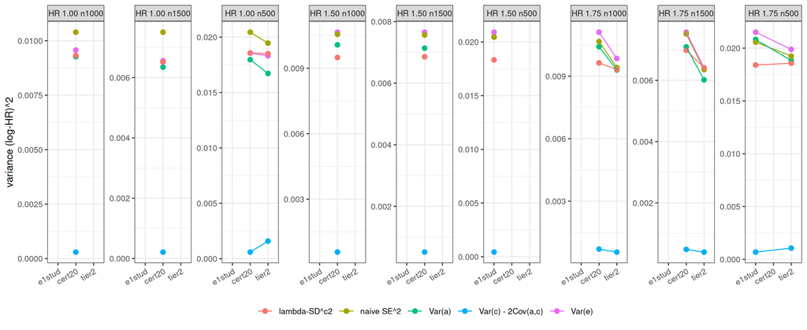

```r
library(ggplot2)
P <- A1[A1$n > 0, ]; P$regime_short <- sub(" \\(.*$", "", P$regime); P$idx <- order_key[meta_tab$tag]
L <- rbind(data.frame(cell = P$cell, regime = P$regime_short, idx = P$idx, component = "Var(a)", value = P$Var_a),
           data.frame(cell = P$cell, regime = P$regime_short, idx = P$idx, component = "Var(c) - 2Cov(a,c)", value = P$excess_c),
           data.frame(cell = P$cell, regime = P$regime_short, idx = P$idx, component = "Var(e)", value = P$Var_e),
           data.frame(cell = P$cell, regime = P$regime_short, idx = P$idx, component = "naive SE^2", value = P$naive_SE2),
           data.frame(cell = P$cell, regime = P$regime_short, idx = P$idx, component = "lambda-SD^c2", value = P$lam_SD2))
L$regime <- factor(L$regime, levels = names(order_key))
ggplot(L, aes(x = regime, y = value, colour = component, group = component)) +
  geom_point(size = 2) + geom_line() + facet_wrap(~ cell, scales = "free_y", nrow = 1) +
  labs(x = NULL, y = "variance (log-HR)^2", colour = NULL) + theme_bw(base_size = 10) +
  theme(axis.text.x = element_text(angle = 30, hjust = 1), legend.position = "bottom")
```

# 6 Numbers for the record

- **HR 1.00 n500, cert20 (effMaxSG eps 0.20, J 10, prev 31%)** (n 1841, |Hhat| 119): Var(a) 0.01796 vs naive SE^2 0.02044 (ratio 0.879); Var(c) 0.00029, Cov(a,c) -0.00015 (corr -0.066), Var(c) - 2Cov 0.00060; Var(e) 0.01856 (r 0.953, check 0.0e+00); lambda-SD^c2 0.01857 = 1.001 Var(e) = 1.034 Var(a) = 0.908 naive SE^2; IJ se^2 0.06512 = 3.51 Var(e).
- **HR 1.00 n500, tier2 (maxeffCons, J 10, prev 12%)** (n 1361, |Hhat| 79): Var(a) 0.01672 vs naive SE^2 0.01946 (ratio 0.859); Var(c) 0.00021, Cov(a,c) -0.00069 (corr -0.369), Var(c) - 2Cov 0.00159; Var(e) 0.01831 (r 0.970, check 0.0e+00); lambda-SD^c2 0.01851 = 1.011 Var(e) = 1.107 Var(a) = 0.951 naive SE^2; IJ se^2 0.06491 = 3.54 Var(e).
- **HR 1.00 n1000, cert20 (effMaxSG eps 0.20, J 10, prev 31%)** (n 1909, |Hhat| 243): Var(a) 0.00927 vs naive SE^2 0.01039 (ratio 0.892); Var(c) 0.00013, Cov(a,c) -0.00009 (corr -0.078), Var(c) - 2Cov 0.00030; Var(e) 0.00957 (r 0.960, check 0.0e+00); lambda-SD^c2 0.00933 = 0.975 Var(e) = 1.006 Var(a) = 0.898 naive SE^2; IJ se^2 0.03313 = 3.46 Var(e).
- **HR 1.00 n1500, cert20 (effMaxSG eps 0.20, J 10, prev 31%)** (n 1918, |Hhat| 431): Var(a) 0.00635 vs naive SE^2 0.00751 (ratio 0.846); Var(c) 0.00010, Cov(a,c) -0.00006 (corr -0.072), Var(c) - 2Cov 0.00021; Var(e) 0.00656 (r 0.935, check 8.7e-19); lambda-SD^c2 0.00651 = 0.993 Var(e) = 1.026 Var(a) = 0.868 naive SE^2; IJ se^2 0.02311 = 3.52 Var(e).
- **HR 1.50 n500, e1stud (effMaxSG eps 0.20, J 10, prev 31%)** (n 1999, |Hhat| 127): Var(a) 0.02047 vs naive SE^2 0.02045 (ratio 1.001); Var(c) 0.00030, Cov(a,c) -0.00007 (corr -0.028), Var(c) - 2Cov 0.00043; Var(e) 0.02091 (r 1.011, check 0.0e+00); lambda-SD^c2 0.01833 = 0.877 Var(e) = 0.895 Var(a) = 0.897 naive SE^2; IJ se^2 0.06610 = 3.16 Var(e).
- **HR 1.50 n1000, cert20 (effMaxSG eps 0.20, J 10, prev 31%)** (n 2000, |Hhat| 267): Var(a) 0.01007 vs naive SE^2 0.01055 (ratio 0.955); Var(c) 0.00013, Cov(a,c) -0.00022 (corr -0.192), Var(c) - 2Cov 0.00058; Var(e) 0.01065 (r 1.005, check 0.0e+00); lambda-SD^c2 0.00949 = 0.891 Var(e) = 0.942 Var(a) = 0.899 naive SE^2; IJ se^2 0.03463 = 3.25 Var(e).
- **HR 1.50 n1500, cert20 (effMaxSG eps 0.20, J 10, prev 31%)** (n 2000, |Hhat| 463): Var(a) 0.00714 vs naive SE^2 0.00756 (ratio 0.943); Var(c) 0.00009, Cov(a,c) -0.00021 (corr -0.267), Var(c) - 2Cov 0.00052; Var(e) 0.00765 (r 1.006, check 8.7e-19); lambda-SD^c2 0.00686 = 0.896 Var(e) = 0.961 Var(a) = 0.907 naive SE^2; IJ se^2 0.02495 = 3.26 Var(e).
- **HR 1.75 n500, e1stud (effMaxSG eps 0.20, J 10, prev 31%)** (n 1999, |Hhat| 129): Var(a) 0.02082 vs naive SE^2 0.02057 (ratio 1.012); Var(c) 0.00029, Cov(a,c) -0.00020 (corr -0.080), Var(c) - 2Cov 0.00069; Var(e) 0.02151 (r 1.022, check -3.5e-18); lambda-SD^c2 0.01840 = 0.856 Var(e) = 0.884 Var(a) = 0.894 naive SE^2; IJ se^2 0.06686 = 3.11 Var(e).
- **HR 1.75 n500, tier2 (maxeffCons, J 10, prev 12%)** (n 1900, |Hhat| 72): Var(a) 0.01882 vs naive SE^2 0.01925 (ratio 0.978); Var(c) 0.00026, Cov(a,c) -0.00040 (corr -0.179), Var(c) - 2Cov 0.00106; Var(e) 0.01988 (r 1.016, check 0.0e+00); lambda-SD^c2 0.01857 = 0.934 Var(e) = 0.987 Var(a) = 0.965 naive SE^2; IJ se^2 0.06634 = 3.34 Var(e).
- **HR 1.75 n1000, cert20 (effMaxSG eps 0.20, J 10, prev 31%)** (n 2000, |Hhat| 272): Var(a) 0.01042 vs naive SE^2 0.01067 (ratio 0.977); Var(c) 0.00012, Cov(a,c) -0.00029 (corr -0.256), Var(c) - 2Cov 0.00070; Var(e) 0.01112 (r 1.021, check -1.7e-18); lambda-SD^c2 0.00964 = 0.867 Var(e) = 0.925 Var(a) = 0.904 naive SE^2; IJ se^2 0.03548 = 3.19 Var(e).
- **HR 1.75 n1000, tier2 (maxeffCons, J 10, prev 12%)** (n 1990, |Hhat| 123): Var(a) 0.00930 vs naive SE^2 0.00942 (ratio 0.988); Var(c) 0.00014, Cov(a,c) -0.00021 (corr -0.182), Var(c) - 2Cov 0.00055; Var(e) 0.00985 (r 1.023, check 0.0e+00); lambda-SD^c2 0.00932 = 0.946 Var(e) = 1.002 Var(a) = 0.990 naive SE^2; IJ se^2 0.03394 = 3.44 Var(e).
- **HR 1.75 n1500, cert20 (effMaxSG eps 0.20, J 10, prev 31%)** (n 2000, |Hhat| 457): Var(a) 0.00709 vs naive SE^2 0.00752 (ratio 0.943); Var(c) 0.00007, Cov(a,c) -0.00021 (corr -0.291), Var(c) - 2Cov 0.00048; Var(e) 0.00757 (r 1.004, check 0.0e+00); lambda-SD^c2 0.00698 = 0.922 Var(e) = 0.985 Var(a) = 0.929 naive SE^2; IJ se^2 0.02565 = 3.39 Var(e).
- **HR 1.75 n1500, tier2 (maxeffCons, J 10, prev 12%)** (n 1998, |Hhat| 186): Var(a) 0.00602 vs naive SE^2 0.00635 (ratio 0.947); Var(c) 0.00009, Cov(a,c) -0.00015 (corr -0.208), Var(c) - 2Cov 0.00039; Var(e) 0.00641 (r 1.005, check 0.0e+00); lambda-SD^c2 0.00641 = 1.001 Var(e) = 1.066 Var(a) = 1.010 naive SE^2; IJ se^2 0.02340 = 3.65 Var(e).

# 7 A5 — Location by stratum

```r
s_cols <- c("fld_Hc_est2", "fld_Hc_lam_mean", "fld_Hc_est2_s", "fld_Hc_lam_mean_s", "fld_Hc_se_s",
            "fld_Hc_up1s", "fld_Hc_up1s_s", "fld_Hc_scale_ratio", "p_hat_H")
has_s <- vapply(bundles, function(b) all(s_cols %in% names(b$results)) && any(is.finite(b$results$fld_Hc_est2_s)), TRUE)
# The A2 rows (abc()) with the field inputs also finite, plus the two corrections and the two field errors.
loc <- function(r) {
  d <- abc(r)
  d <- d[Reduce(`&`, lapply(s_cols, function(cn) is.finite(d[[cn]]))), , drop = FALSE]
  d$lam <- d$fld_Hc_lam_mean; d$lam_s <- d$fld_Hc_lam_mean_s
  d$ef   <- log(d$fld_Hc_est2)   - log(d$betaHhat_Hc)
  d$ef_s <- log(d$fld_Hc_est2_s) - log(d$betaHhat_Hc)
  d$cov_f <- d$betaHhat_Hc <= d$fld_Hc_up1s
  d$cov_s <- d$betaHhat_Hc <= d$fld_Hc_up1s_s
  d
}
D5 <- lapply(which(has_s), function(i) loc(bundles[[i]]$results)); names(D5) <- which(has_s)
# Regime sequence for this section: effMaxSG (eps ascending) -> maxSG -> minSG, HR ascending within.
ord5 <- if (length(D5)) { i5 <- as.integer(names(D5))
  order(match(vapply(bundles[i5], function(b) b$meta$sg_focus %||% "maxeffCons", ""), c("maxeffCons", "effMaxSG", "effMinSG", "maxSG", "minSG")),
        vapply(bundles[i5], function(b) knob(b, "effect_neighborhood", 0.10), 0), meta_tab$hr[i5]) } else integer(0)
D5 <- D5[ord5]
# Identity check of this record: ef = e - lam and ef_s = e - lam_s on the working scale, to 1e-12.
ident <- do.call(rbind, lapply(seq_along(D5), function(j) { d <- D5[[j]]; i <- as.integer(names(D5)[j])
  data.frame(cell = meta_tab$cell[i], regime = meta_tab$regime[i],
             n_detected = sum(bundles[[i]]$results$detected %in% 1L), n = nrow(d),
             max_abs_ef_minus_e_lam = max(abs(d$ef - (d$e - d$lam))),
             max_abs_efs_minus_e_lams = max(abs(d$ef_s - (d$e - d$lam_s)))) }))
stopifnot(length(D5) == 0 || (all(ident$max_abs_ef_minus_e_lam <= 1e-12) && all(ident$max_abs_efs_minus_e_lams <= 1e-12)))
if (length(D5)) kbl(ident, digits = c(0, 0, 0, 0, 16, 16), booktabs = TRUE, row.names = FALSE,
    caption = "Identity check: max |ef - (e - lam)| and max |ef_s - (e - lam_s)| per cell (asserted <= 1e-12); n = detected replicates with every input finite.") |>
  kable_styling(font_size = 10)
```

Identity check: max |ef - (e - lam)| and max |ef_s - (e - lam_s)| per cell (asserted <= 1e-12); n = detected replicates with every input finite.

| cell | regime | n_detected | n | max_abs_ef_minus_e_lam | max_abs_efs_minus_e_lams |
| --- | --- | --- | --- | --- | --- |
| HR 1.00 n500 | tier2 (maxeffCons, J 10, prev 12%) | 1361 | 1361 | 3e-16 | 3e-16 |
| HR 1.75 n500 | tier2 (maxeffCons, J 10, prev 12%) | 1900 | 1900 | 3e-16 | 3e-16 |
| HR 1.75 n1000 | tier2 (maxeffCons, J 10, prev 12%) | 1990 | 1990 | 3e-16 | 3e-16 |
| HR 1.75 n1500 | tier2 (maxeffCons, J 10, prev 12%) | 1998 | 1998 | 3e-16 | 3e-16 |
| HR 1.00 n500 | cert20 (effMaxSG eps 0.20, J 10, prev 31%) | 1841 | 1841 | 3e-16 | 3e-16 |
| HR 1.00 n1000 | cert20 (effMaxSG eps 0.20, J 10, prev 31%) | 1909 | 1909 | 2e-16 | 3e-16 |
| HR 1.00 n1500 | cert20 (effMaxSG eps 0.20, J 10, prev 31%) | 1918 | 1918 | 2e-16 | 2e-16 |
| HR 1.50 n500 | e1stud (effMaxSG eps 0.20, J 10, prev 31%) | 1999 | 1999 | 3e-16 | 3e-16 |
| HR 1.50 n1000 | cert20 (effMaxSG eps 0.20, J 10, prev 31%) | 2000 | 2000 | 2e-16 | 3e-16 |
| HR 1.50 n1500 | cert20 (effMaxSG eps 0.20, J 10, prev 31%) | 2000 | 2000 | 3e-16 | 3e-16 |
| HR 1.75 n500 | e1stud (effMaxSG eps 0.20, J 10, prev 31%) | 1999 | 1999 | 3e-16 | 3e-16 |
| HR 1.75 n1000 | cert20 (effMaxSG eps 0.20, J 10, prev 31%) | 2000 | 2000 | 3e-16 | 2e-16 |
| HR 1.75 n1500 | cert20 (effMaxSG eps 0.20, J 10, prev 31%) | 2000 | 2000 | 3e-16 | 2e-16 |

```r
wil <- function(p, n, z = stats::qnorm(0.975)) {
  ctr <- (p + z^2 / (2 * n)) / (1 + z^2 / n)
  hw  <- z * sqrt(p * (1 - p) / n + z^2 / (4 * n^2)) / (1 + z^2 / n)
  c(ctr - hw, ctr + hw)
}
# decomp() of A1/A2 with means (and their SEs) in place of variances.
locate <- function(d) {
  m <- function(v) mean(v); s <- function(v) stats::sd(v) / sqrt(length(v))
  z1 <- stats::qnorm(0.95)
  b <- mean(d$ef_s) / stats::sd(d$ef_s); rr <- mean(d$fld_Hc_se_s) / stats::sd(d$ef_s)
  w <- wil(mean(d$cov_s), nrow(d))
  data.frame(n = nrow(d), Hhat_over_H = mean(d$ratio_H), p_hat_mean = mean(d$p_hat_H), rho_c = mean(d$fld_Hc_scale_ratio),
             mean_a = m(d$a), se_a = s(d$a), mean_c = m(d$c), se_c = s(d$c), mean_e = m(d$e), se_e = s(d$e),
             mean_lam = m(d$lam), se_lam = s(d$lam), mean_ef = m(d$ef), se_ef = s(d$ef),
             mean_lam_s = m(d$lam_s), se_lam_s = s(d$lam_s), mean_ef_s = m(d$ef_s), se_ef_s = s(d$ef_s),
             SD_ef_s = stats::sd(d$ef_s), naive_SE = mean(d$nv_Hc_se), se_field_s = mean(d$fld_Hc_se_s),
             cov_field = mean(d$cov_f), cov_field_s = mean(d$cov_s), wilson_lo = w[1], wilson_hi = w[2],
             b_s = b, r_s = rr, gauss_s = stats::pnorm(z1 * rr + b))
}
# strat() of A2 with locate() in place of decomp(); the whole-cell row first.
strat5 <- function(j, var, what) {
  d <- D5[[j]]; i <- as.integer(names(D5)[j]); v <- d[[var]]; if (!any(is.finite(v))) return(NULL)
  br <- stats::quantile(v, c(0, 1/3, 2/3, 1), na.rm = TRUE, names = FALSE)
  g <- cut(v, breaks = unique(br), include.lowest = TRUE, labels = FALSE)
  rbind(cbind(cell = meta_tab$cell[i], regime = meta_tab$regime[i], stratum = sprintf("%s all", what), locate(d)),
        do.call(rbind, lapply(sort(unique(g)), function(k) {
          dk <- d[g == k, , drop = FALSE]
          cbind(cell = meta_tab$cell[i], regime = meta_tab$regime[i],
                stratum = sprintf("%s T%d [%.3f, %.3f]", what, k, min(v[g == k]), max(v[g == k])),
                locate(dk)) })))
}
cols5a <- c("cell", "regime", "stratum", "n", "p_hat_mean", "Hhat_over_H", "rho_c",
            "mean_a", "se_a", "mean_c", "se_c", "mean_e", "se_e", "mean_lam", "se_lam", "mean_ef", "se_ef",
            "mean_lam_s", "se_lam_s", "mean_ef_s", "se_ef_s")
dg5a <- c(0, 0, 0, 0, 3, 3, 3, rep(4, 14))
cols5b <- c("cell", "regime", "stratum", "n", "naive_SE", "se_field_s", "SD_ef_s", "mean_ef_s", "b_s", "r_s",
            "cov_field", "cov_field_s", "wilson_lo", "wilson_hi", "gauss_s")
dg5b <- c(0, 0, 0, 0, 4, 4, 4, 4, 3, 3, 3, 3, 3, 3, 3)
A5p <- if (length(D5)) do.call(rbind, lapply(seq_along(D5), strat5, var = "p_hat_H", what = "p-hat")) else NULL
A5h <- if (length(D5)) do.call(rbind, lapply(seq_along(D5), strat5, var = "ratio_H", what = "|Hhat|/|H|")) else NULL
```

## 7.1 L1 — Means by p̂(Ĥ) tertile, per cell

```r
if (!is.null(A5p)) {
  kbl(A5p[, cols5a], digits = dg5a, booktabs = TRUE, row.names = FALSE,
      caption = "L1 (location): by p-hat(Hhat) tertile (tertiles within the cell as in A2). Means with their SEs of a (naive error), c (two-term correction), e = a - c, lam (field correction), ef = e - lam, lam_s (field-s correction), ef_s = e - lam_s; mean rho^c and |Hhat|/|H|.") |>
    kable_styling(font_size = 9)
}
```

L1 (location): by p-hat(Hhat) tertile (tertiles within the cell as in A2). Means with their SEs of a (naive error), c (two-term correction), e = a - c, lam (field correction), ef = e - lam, lam_s (field-s correction), ef_s = e - lam_s; mean rho^c and |Hhat|/|H|.

| cell | regime | stratum | n | p_hat_mean | Hhat_over_H | rho_c | mean_a | se_a | mean_c | se_c | mean_e | se_e | mean_lam | se_lam | mean_ef | se_ef | mean_lam_s | se_lam_s | mean_ef_s | se_ef_s |
| --- | --- | --- | --- | --- | --- | --- | --- | --- | --- | --- | --- | --- | --- | --- | --- | --- | --- | --- | --- | --- |
| HR 1.00 n500 | tier2 (maxeffCons, J 10, prev 12%) | p-hat all | 1361 | 0.158 | 1.293 | 1.020 | -0.0904 | 0.0035 | -0.0691 | 4e-04 | -0.0214 | 0.0037 | -0.0117 | 3e-04 | -0.0096 | 0.0038 | -0.0116 | 3e-04 | -0.0098 | 0.0038 |
| HR 1.00 n500 | tier2 (maxeffCons, J 10, prev 12%) | p-hat T1 [0.000, 0.090] | 456 | 0.046 | 1.518 | 1.040 | -0.0752 | 0.0058 | -0.0692 | 8e-04 | -0.0060 | 0.0059 | -0.0114 | 5e-04 | 0.0054 | 0.0061 | -0.0117 | 5e-04 | 0.0056 | 0.0061 |
| HR 1.00 n500 | tier2 (maxeffCons, J 10, prev 12%) | p-hat T2 [0.091, 0.189] | 451 | 0.136 | 1.222 | 1.016 | -0.0735 | 0.0060 | -0.0736 | 6e-04 | 0.0001 | 0.0062 | -0.0133 | 4e-04 | 0.0134 | 0.0063 | -0.0131 | 4e-04 | 0.0132 | 0.0064 |
| HR 1.00 n500 | tier2 (maxeffCons, J 10, prev 12%) | p-hat T3 [0.190, 0.797] | 454 | 0.293 | 1.137 | 1.003 | -0.1226 | 0.0062 | -0.0645 | 6e-04 | -0.0581 | 0.0065 | -0.0104 | 5e-04 | -0.0477 | 0.0067 | -0.0100 | 5e-04 | -0.0481 | 0.0067 |
| HR 1.75 n500 | tier2 (maxeffCons, J 10, prev 12%) | p-hat all | 1900 | 0.234 | 1.179 | 1.017 | -0.0703 | 0.0031 | -0.0621 | 4e-04 | -0.0082 | 0.0032 | -0.0076 | 3e-04 | -0.0006 | 0.0033 | -0.0075 | 3e-04 | -0.0007 | 0.0033 |
| HR 1.75 n500 | tier2 (maxeffCons, J 10, prev 12%) | p-hat T1 [0.000, 0.138] | 634 | 0.080 | 1.302 | 1.028 | -0.0523 | 0.0054 | -0.0677 | 6e-04 | 0.0153 | 0.0055 | -0.0104 | 4e-04 | 0.0257 | 0.0056 | -0.0104 | 4e-04 | 0.0258 | 0.0056 |
| HR 1.75 n500 | tier2 (maxeffCons, J 10, prev 12%) | p-hat T2 [0.138, 0.268] | 635 | 0.196 | 1.153 | 1.014 | -0.0657 | 0.0053 | -0.0682 | 4e-04 | 0.0025 | 0.0054 | -0.0110 | 4e-04 | 0.0135 | 0.0055 | -0.0108 | 4e-04 | 0.0133 | 0.0055 |
| HR 1.75 n500 | tier2 (maxeffCons, J 10, prev 12%) | p-hat T3 [0.268, 0.991] | 631 | 0.426 | 1.083 | 1.008 | -0.0931 | 0.0055 | -0.0504 | 6e-04 | -0.0427 | 0.0056 | -0.0015 | 4e-04 | -0.0412 | 0.0057 | -0.0012 | 4e-04 | -0.0415 | 0.0057 |
| HR 1.75 n1000 | tier2 (maxeffCons, J 10, prev 12%) | p-hat all | 1990 | 0.374 | 0.995 | 1.010 | -0.0256 | 0.0022 | -0.0329 | 3e-04 | 0.0073 | 0.0022 | -0.0011 | 2e-04 | 0.0084 | 0.0023 | -0.0009 | 2e-04 | 0.0083 | 0.0023 |
| HR 1.75 n1000 | tier2 (maxeffCons, J 10, prev 12%) | p-hat T1 [0.002, 0.261] | 665 | 0.173 | 1.035 | 1.018 | -0.0174 | 0.0038 | -0.0418 | 4e-04 | 0.0244 | 0.0039 | -0.0053 | 3e-04 | 0.0298 | 0.0039 | -0.0053 | 3e-04 | 0.0297 | 0.0039 |
| HR 1.75 n1000 | tier2 (maxeffCons, J 10, prev 12%) | p-hat T2 [0.262, 0.431] | 662 | 0.341 | 0.975 | 1.009 | -0.0222 | 0.0038 | -0.0348 | 3e-04 | 0.0126 | 0.0038 | -0.0019 | 3e-04 | 0.0146 | 0.0038 | -0.0017 | 3e-04 | 0.0144 | 0.0038 |
| HR 1.75 n1000 | tier2 (maxeffCons, J 10, prev 12%) | p-hat T3 [0.431, 0.968] | 663 | 0.610 | 0.973 | 1.005 | -0.0373 | 0.0036 | -0.0222 | 3e-04 | -0.0151 | 0.0037 | 0.0041 | 3e-04 | -0.0192 | 0.0037 | 0.0043 | 3e-04 | -0.0194 | 0.0037 |
| HR 1.75 n1500 | tier2 (maxeffCons, J 10, prev 12%) | p-hat all | 1998 | 0.498 | 1.006 | 1.010 | -0.0128 | 0.0017 | -0.0201 | 2e-04 | 0.0073 | 0.0018 | 0.0022 | 1e-04 | 0.0051 | 0.0018 | 0.0024 | 1e-04 | 0.0050 | 0.0018 |
| HR 1.75 n1500 | tier2 (maxeffCons, J 10, prev 12%) | p-hat T1 [0.007, 0.377] | 666 | 0.258 | 1.015 | 1.016 | -0.0015 | 0.0031 | -0.0281 | 3e-04 | 0.0267 | 0.0032 | -0.0018 | 2e-04 | 0.0285 | 0.0032 | -0.0017 | 2e-04 | 0.0283 | 0.0032 |
| HR 1.75 n1500 | tier2 (maxeffCons, J 10, prev 12%) | p-hat T2 [0.377, 0.592] | 666 | 0.483 | 0.994 | 1.008 | -0.0140 | 0.0030 | -0.0204 | 2e-04 | 0.0064 | 0.0030 | 0.0023 | 2e-04 | 0.0041 | 0.0031 | 0.0025 | 2e-04 | 0.0039 | 0.0031 |
| HR 1.75 n1500 | tier2 (maxeffCons, J 10, prev 12%) | p-hat T3 [0.594, 0.996] | 666 | 0.753 | 1.008 | 1.005 | -0.0228 | 0.0029 | -0.0117 | 2e-04 | -0.0111 | 0.0029 | 0.0061 | 2e-04 | -0.0172 | 0.0029 | 0.0063 | 2e-04 | -0.0174 | 0.0029 |
| HR 1.00 n500 | cert20 (effMaxSG eps 0.20, J 10, prev 31%) | p-hat all | 1841 | 0.086 | 0.780 | 1.043 | -0.1483 | 0.0031 | -0.0893 | 4e-04 | -0.0591 | 0.0032 | -0.0185 | 2e-04 | -0.0405 | 0.0032 | -0.0184 | 3e-04 | -0.0407 | 0.0032 |
| HR 1.00 n500 | cert20 (effMaxSG eps 0.20, J 10, prev 31%) | p-hat T1 [0.000, 0.038] | 614 | 0.019 | 0.955 | 1.088 | -0.1279 | 0.0056 | -0.0910 | 8e-04 | -0.0369 | 0.0056 | -0.0191 | 4e-04 | -0.0178 | 0.0057 | -0.0199 | 5e-04 | -0.0170 | 0.0057 |
| HR 1.00 n500 | cert20 (effMaxSG eps 0.20, J 10, prev 31%) | p-hat T2 [0.038, 0.090] | 614 | 0.061 | 0.751 | 1.036 | -0.1472 | 0.0052 | -0.0920 | 6e-04 | -0.0552 | 0.0053 | -0.0195 | 4e-04 | -0.0357 | 0.0054 | -0.0192 | 4e-04 | -0.0360 | 0.0054 |
| HR 1.00 n500 | cert20 (effMaxSG eps 0.20, J 10, prev 31%) | p-hat T3 [0.090, 0.569] | 613 | 0.180 | 0.635 | 1.003 | -0.1699 | 0.0053 | -0.0848 | 6e-04 | -0.0852 | 0.0054 | -0.0169 | 4e-04 | -0.0682 | 0.0055 | -0.0160 | 4e-04 | -0.0691 | 0.0055 |
| HR 1.00 n1000 | cert20 (effMaxSG eps 0.20, J 10, prev 31%) | p-hat all | 1909 | 0.081 | 0.794 | 1.044 | -0.1008 | 0.0022 | -0.0657 | 3e-04 | -0.0352 | 0.0022 | -0.0144 | 2e-04 | -0.0207 | 0.0023 | -0.0142 | 2e-04 | -0.0210 | 0.0023 |
| HR 1.00 n1000 | cert20 (effMaxSG eps 0.20, J 10, prev 31%) | p-hat T1 [0.000, 0.037] | 638 | 0.021 | 1.003 | 1.098 | -0.0927 | 0.0039 | -0.0720 | 4e-04 | -0.0207 | 0.0040 | -0.0174 | 3e-04 | -0.0033 | 0.0040 | -0.0177 | 3e-04 | -0.0030 | 0.0040 |
| HR 1.00 n1000 | cert20 (effMaxSG eps 0.20, J 10, prev 31%) | p-hat T2 [0.037, 0.080] | 636 | 0.056 | 0.766 | 1.034 | -0.0985 | 0.0037 | -0.0666 | 4e-04 | -0.0319 | 0.0037 | -0.0146 | 3e-04 | -0.0173 | 0.0038 | -0.0141 | 3e-04 | -0.0178 | 0.0038 |
| HR 1.00 n1000 | cert20 (effMaxSG eps 0.20, J 10, prev 31%) | p-hat T3 [0.080, 0.693] | 635 | 0.167 | 0.613 | 1.001 | -0.1114 | 0.0038 | -0.0584 | 4e-04 | -0.0530 | 0.0038 | -0.0113 | 3e-04 | -0.0416 | 0.0039 | -0.0106 | 3e-04 | -0.0423 | 0.0039 |
| HR 1.00 n1500 | cert20 (effMaxSG eps 0.20, J 10, prev 31%) | p-hat all | 1918 | 0.067 | 0.937 | 1.059 | -0.0881 | 0.0018 | -0.0571 | 2e-04 | -0.0311 | 0.0018 | -0.0124 | 1e-04 | -0.0186 | 0.0019 | -0.0121 | 2e-04 | -0.0190 | 0.0019 |
| HR 1.00 n1500 | cert20 (effMaxSG eps 0.20, J 10, prev 31%) | p-hat T1 [0.000, 0.032] | 641 | 0.018 | 1.201 | 1.126 | -0.0802 | 0.0033 | -0.0625 | 3e-04 | -0.0176 | 0.0034 | -0.0150 | 2e-04 | -0.0027 | 0.0034 | -0.0153 | 3e-04 | -0.0024 | 0.0034 |
| HR 1.00 n1500 | cert20 (effMaxSG eps 0.20, J 10, prev 31%) | p-hat T2 [0.033, 0.069] | 641 | 0.048 | 0.886 | 1.041 | -0.0876 | 0.0030 | -0.0579 | 3e-04 | -0.0297 | 0.0031 | -0.0126 | 2e-04 | -0.0171 | 0.0031 | -0.0120 | 2e-04 | -0.0178 | 0.0031 |
| HR 1.00 n1500 | cert20 (effMaxSG eps 0.20, J 10, prev 31%) | p-hat T3 [0.069, 0.681] | 636 | 0.136 | 0.722 | 1.010 | -0.0966 | 0.0031 | -0.0508 | 4e-04 | -0.0459 | 0.0031 | -0.0097 | 3e-04 | -0.0362 | 0.0031 | -0.0090 | 3e-04 | -0.0369 | 0.0031 |
| HR 1.50 n500 | e1stud (effMaxSG eps 0.20, J 10, prev 31%) | p-hat all | 1999 | 0.103 | 0.834 | 1.054 | -0.1234 | 0.0032 | -0.0790 | 4e-04 | -0.0443 | 0.0032 | -0.0137 | 2e-04 | -0.0306 | 0.0033 | -0.0135 | 2e-04 | -0.0308 | 0.0033 |
| HR 1.50 n500 | e1stud (effMaxSG eps 0.20, J 10, prev 31%) | p-hat T1 [0.000, 0.043] | 669 | 0.022 | 1.009 | 1.103 | -0.1111 | 0.0057 | -0.0839 | 7e-04 | -0.0272 | 0.0057 | -0.0167 | 4e-04 | -0.0105 | 0.0058 | -0.0173 | 4e-04 | -0.0099 | 0.0058 |
| HR 1.50 n500 | e1stud (effMaxSG eps 0.20, J 10, prev 31%) | p-hat T2 [0.044, 0.109] | 664 | 0.071 | 0.814 | 1.047 | -0.1228 | 0.0054 | -0.0816 | 6e-04 | -0.0412 | 0.0054 | -0.0144 | 4e-04 | -0.0269 | 0.0055 | -0.0140 | 4e-04 | -0.0272 | 0.0055 |
| HR 1.50 n500 | e1stud (effMaxSG eps 0.20, J 10, prev 31%) | p-hat T3 [0.109, 0.818] | 666 | 0.215 | 0.677 | 1.012 | -0.1362 | 0.0055 | -0.0716 | 6e-04 | -0.0647 | 0.0056 | -0.0100 | 4e-04 | -0.0546 | 0.0056 | -0.0092 | 4e-04 | -0.0555 | 0.0056 |
| HR 1.50 n1000 | cert20 (effMaxSG eps 0.20, J 10, prev 31%) | p-hat all | 2000 | 0.117 | 0.872 | 1.054 | -0.0644 | 0.0022 | -0.0511 | 3e-04 | -0.0133 | 0.0023 | -0.0070 | 2e-04 | -0.0063 | 0.0023 | -0.0065 | 2e-04 | -0.0068 | 0.0023 |
| HR 1.50 n1000 | cert20 (effMaxSG eps 0.20, J 10, prev 31%) | p-hat T1 [0.000, 0.057] | 668 | 0.032 | 1.040 | 1.093 | -0.0476 | 0.0041 | -0.0587 | 4e-04 | 0.0111 | 0.0041 | -0.0104 | 3e-04 | 0.0215 | 0.0042 | -0.0101 | 3e-04 | 0.0212 | 0.0042 |
| HR 1.50 n1000 | cert20 (effMaxSG eps 0.20, J 10, prev 31%) | p-hat T2 [0.058, 0.120] | 665 | 0.085 | 0.866 | 1.053 | -0.0615 | 0.0039 | -0.0517 | 4e-04 | -0.0098 | 0.0039 | -0.0072 | 3e-04 | -0.0026 | 0.0040 | -0.0066 | 3e-04 | -0.0032 | 0.0040 |
| HR 1.50 n1000 | cert20 (effMaxSG eps 0.20, J 10, prev 31%) | p-hat T3 [0.121, 0.700] | 667 | 0.233 | 0.710 | 1.015 | -0.0841 | 0.0036 | -0.0429 | 4e-04 | -0.0412 | 0.0036 | -0.0035 | 3e-04 | -0.0376 | 0.0037 | -0.0029 | 3e-04 | -0.0383 | 0.0037 |
| HR 1.50 n1500 | cert20 (effMaxSG eps 0.20, J 10, prev 31%) | p-hat all | 2000 | 0.122 | 1.008 | 1.059 | -0.0448 | 0.0019 | -0.0373 | 2e-04 | -0.0075 | 0.0020 | -0.0025 | 1e-04 | -0.0049 | 0.0020 | -0.0018 | 2e-04 | -0.0057 | 0.0020 |
| HR 1.50 n1500 | cert20 (effMaxSG eps 0.20, J 10, prev 31%) | p-hat T1 [0.003, 0.064] | 669 | 0.037 | 1.160 | 1.091 | -0.0297 | 0.0035 | -0.0436 | 3e-04 | 0.0139 | 0.0036 | -0.0053 | 2e-04 | 0.0192 | 0.0036 | -0.0045 | 3e-04 | 0.0185 | 0.0036 |
| HR 1.50 n1500 | cert20 (effMaxSG eps 0.20, J 10, prev 31%) | p-hat T2 [0.064, 0.137] | 667 | 0.096 | 0.994 | 1.057 | -0.0439 | 0.0032 | -0.0376 | 3e-04 | -0.0062 | 0.0033 | -0.0026 | 2e-04 | -0.0037 | 0.0033 | -0.0018 | 2e-04 | -0.0044 | 0.0033 |
| HR 1.50 n1500 | cert20 (effMaxSG eps 0.20, J 10, prev 31%) | p-hat T3 [0.137, 0.720] | 664 | 0.233 | 0.869 | 1.028 | -0.0609 | 0.0030 | -0.0307 | 3e-04 | -0.0302 | 0.0031 | 0.0002 | 2e-04 | -0.0305 | 0.0031 | 0.0010 | 2e-04 | -0.0312 | 0.0031 |
| HR 1.75 n500 | e1stud (effMaxSG eps 0.20, J 10, prev 31%) | p-hat all | 1999 | 0.119 | 0.846 | 1.058 | -0.1021 | 0.0032 | -0.0723 | 4e-04 | -0.0299 | 0.0033 | -0.0108 | 2e-04 | -0.0191 | 0.0033 | -0.0105 | 3e-04 | -0.0193 | 0.0033 |
| HR 1.75 n500 | e1stud (effMaxSG eps 0.20, J 10, prev 31%) | p-hat T1 [0.000, 0.051] | 667 | 0.026 | 1.009 | 1.107 | -0.0768 | 0.0057 | -0.0783 | 7e-04 | 0.0015 | 0.0057 | -0.0142 | 4e-04 | 0.0157 | 0.0058 | -0.0147 | 4e-04 | 0.0162 | 0.0058 |
| HR 1.75 n500 | e1stud (effMaxSG eps 0.20, J 10, prev 31%) | p-hat T2 [0.051, 0.129] | 666 | 0.085 | 0.828 | 1.049 | -0.1091 | 0.0054 | -0.0751 | 6e-04 | -0.0340 | 0.0055 | -0.0120 | 4e-04 | -0.0220 | 0.0056 | -0.0115 | 4e-04 | -0.0225 | 0.0056 |
| HR 1.75 n500 | e1stud (effMaxSG eps 0.20, J 10, prev 31%) | p-hat T3 [0.129, 0.928] | 666 | 0.245 | 0.700 | 1.017 | -0.1205 | 0.0055 | -0.0634 | 6e-04 | -0.0571 | 0.0056 | -0.0061 | 4e-04 | -0.0510 | 0.0056 | -0.0053 | 4e-04 | -0.0518 | 0.0056 |
| HR 1.75 n1000 | cert20 (effMaxSG eps 0.20, J 10, prev 31%) | p-hat all | 2000 | 0.144 | 0.888 | 1.056 | -0.0492 | 0.0023 | -0.0435 | 2e-04 | -0.0057 | 0.0024 | -0.0038 | 2e-04 | -0.0019 | 0.0024 | -0.0032 | 2e-04 | -0.0025 | 0.0024 |
| HR 1.75 n1000 | cert20 (effMaxSG eps 0.20, J 10, prev 31%) | p-hat T1 [0.001, 0.073] | 670 | 0.043 | 1.025 | 1.092 | -0.0281 | 0.0039 | -0.0506 | 4e-04 | 0.0225 | 0.0040 | -0.0070 | 3e-04 | 0.0295 | 0.0040 | -0.0066 | 3e-04 | 0.0291 | 0.0040 |
| HR 1.75 n1000 | cert20 (effMaxSG eps 0.20, J 10, prev 31%) | p-hat T2 [0.073, 0.158] | 663 | 0.112 | 0.885 | 1.054 | -0.0510 | 0.0041 | -0.0441 | 3e-04 | -0.0069 | 0.0042 | -0.0041 | 3e-04 | -0.0028 | 0.0042 | -0.0034 | 3e-04 | -0.0035 | 0.0042 |
| HR 1.75 n1000 | cert20 (effMaxSG eps 0.20, J 10, prev 31%) | p-hat T3 [0.158, 0.751] | 667 | 0.279 | 0.755 | 1.022 | -0.0687 | 0.0037 | -0.0358 | 4e-04 | -0.0329 | 0.0038 | -0.0004 | 3e-04 | -0.0325 | 0.0039 | 0.0003 | 3e-04 | -0.0332 | 0.0039 |
| HR 1.75 n1500 | cert20 (effMaxSG eps 0.20, J 10, prev 31%) | p-hat all | 2000 | 0.168 | 0.995 | 1.052 | -0.0342 | 0.0019 | -0.0296 | 2e-04 | -0.0046 | 0.0019 | 0.0001 | 1e-04 | -0.0047 | 0.0020 | 0.0008 | 1e-04 | -0.0054 | 0.0020 |
| HR 1.75 n1500 | cert20 (effMaxSG eps 0.20, J 10, prev 31%) | p-hat T1 [0.001, 0.100] | 667 | 0.060 | 1.091 | 1.075 | -0.0146 | 0.0033 | -0.0350 | 3e-04 | 0.0204 | 0.0034 | -0.0019 | 2e-04 | 0.0223 | 0.0034 | -0.0010 | 3e-04 | 0.0215 | 0.0034 |
| HR 1.75 n1500 | cert20 (effMaxSG eps 0.20, J 10, prev 31%) | p-hat T2 [0.101, 0.190] | 666 | 0.143 | 0.984 | 1.051 | -0.0371 | 0.0032 | -0.0299 | 3e-04 | -0.0073 | 0.0033 | 0.0000 | 2e-04 | -0.0073 | 0.0033 | 0.0008 | 2e-04 | -0.0080 | 0.0033 |
| HR 1.75 n1500 | cert20 (effMaxSG eps 0.20, J 10, prev 31%) | p-hat T3 [0.191, 0.706] | 667 | 0.302 | 0.911 | 1.030 | -0.0508 | 0.0031 | -0.0238 | 3e-04 | -0.0270 | 0.0032 | 0.0020 | 2e-04 | -0.0290 | 0.0032 | 0.0027 | 2e-04 | -0.0297 | 0.0032 |

```r
if (!is.null(A5p)) {
  kbl(A5p[, cols5b], digits = dg5b, booktabs = TRUE, row.names = FALSE,
      caption = "L1 (coverage): mean naive SE, mean fld_Hc_se_s and the error SD of ef_s in the stratum; observed one-sided upper coverage of the field (cov_field) and field-s (cov_field_s, Wilson) bounds; the Gaussian-implied field-s coverage Phi(z r + b) from the stratum's own (mean ef_s, SD ef_s, mean fld_Hc_se_s).") |>
    kable_styling(font_size = 9)
}
```

L1 (coverage): mean naive SE, mean fld_Hc_se_s and the error SD of ef_s in the stratum; observed one-sided upper coverage of the field (cov_field) and field-s (cov_field_s, Wilson) bounds; the Gaussian-implied field-s coverage Phi(z r + b) from the stratum's own (mean ef_s, SD ef_s, mean fld_Hc_se_s).

| cell | regime | stratum | n | naive_SE | se_field_s | SD_ef_s | mean_ef_s | b_s | r_s | cov_field | cov_field_s | wilson_lo | wilson_hi | gauss_s |
| --- | --- | --- | --- | --- | --- | --- | --- | --- | --- | --- | --- | --- | --- | --- |
| HR 1.00 n500 | tier2 (maxeffCons, J 10, prev 12%) | p-hat all | 1361 | 0.1394 | 0.1384 | 0.1387 | -0.0098 | -0.071 | 0.998 | 0.930 | 0.940 | 0.926 | 0.951 | 0.942 |
| HR 1.00 n500 | tier2 (maxeffCons, J 10, prev 12%) | p-hat T1 [0.000, 0.090] | 456 | 0.1413 | 0.1408 | 0.1299 | 0.0056 | 0.043 | 1.084 | 0.947 | 0.965 | 0.944 | 0.978 | 0.966 |
| HR 1.00 n500 | tier2 (maxeffCons, J 10, prev 12%) | p-hat T2 [0.091, 0.189] | 451 | 0.1389 | 0.1374 | 0.1349 | 0.0132 | 0.098 | 1.019 | 0.951 | 0.958 | 0.935 | 0.973 | 0.962 |
| HR 1.00 n500 | tier2 (maxeffCons, J 10, prev 12%) | p-hat T3 [0.190, 0.797] | 454 | 0.1379 | 0.1369 | 0.1433 | -0.0481 | -0.336 | 0.956 | 0.892 | 0.896 | 0.865 | 0.921 | 0.892 |
| HR 1.75 n500 | tier2 (maxeffCons, J 10, prev 12%) | p-hat all | 1900 | 0.1387 | 0.1384 | 0.1438 | -0.0007 | -0.005 | 0.962 | 0.936 | 0.941 | 0.929 | 0.950 | 0.943 |
| HR 1.75 n500 | tier2 (maxeffCons, J 10, prev 12%) | p-hat T1 [0.000, 0.138] | 634 | 0.1391 | 0.1386 | 0.1401 | 0.0258 | 0.184 | 0.989 | 0.954 | 0.964 | 0.946 | 0.976 | 0.965 |
| HR 1.75 n500 | tier2 (maxeffCons, J 10, prev 12%) | p-hat T2 [0.138, 0.268] | 635 | 0.1382 | 0.1372 | 0.1390 | 0.0133 | 0.096 | 0.987 | 0.946 | 0.951 | 0.932 | 0.965 | 0.957 |
| HR 1.75 n500 | tier2 (maxeffCons, J 10, prev 12%) | p-hat T3 [0.268, 0.991] | 631 | 0.1387 | 0.1394 | 0.1435 | -0.0415 | -0.289 | 0.971 | 0.906 | 0.906 | 0.881 | 0.927 | 0.905 |
| HR 1.75 n1000 | tier2 (maxeffCons, J 10, prev 12%) | p-hat all | 1990 | 0.0970 | 0.0975 | 0.1008 | 0.0083 | 0.082 | 0.968 | 0.955 | 0.956 | 0.946 | 0.964 | 0.953 |
| HR 1.75 n1000 | tier2 (maxeffCons, J 10, prev 12%) | p-hat T1 [0.002, 0.261] | 665 | 0.0971 | 0.0968 | 0.1011 | 0.0297 | 0.294 | 0.958 | 0.968 | 0.970 | 0.954 | 0.980 | 0.969 |
| HR 1.75 n1000 | tier2 (maxeffCons, J 10, prev 12%) | p-hat T2 [0.262, 0.431] | 662 | 0.0968 | 0.0971 | 0.0986 | 0.0144 | 0.146 | 0.984 | 0.958 | 0.958 | 0.940 | 0.971 | 0.961 |
| HR 1.75 n1000 | tier2 (maxeffCons, J 10, prev 12%) | p-hat T3 [0.431, 0.968] | 663 | 0.0971 | 0.0987 | 0.0964 | -0.0194 | -0.201 | 1.024 | 0.938 | 0.941 | 0.921 | 0.957 | 0.931 |
| HR 1.75 n1500 | tier2 (maxeffCons, J 10, prev 12%) | p-hat all | 1998 | 0.0797 | 0.0808 | 0.0810 | 0.0050 | 0.061 | 0.998 | 0.959 | 0.960 | 0.951 | 0.968 | 0.956 |
| HR 1.75 n1500 | tier2 (maxeffCons, J 10, prev 12%) | p-hat T1 [0.007, 0.377] | 666 | 0.0796 | 0.0800 | 0.0824 | 0.0283 | 0.344 | 0.971 | 0.979 | 0.979 | 0.965 | 0.987 | 0.974 |
| HR 1.75 n1500 | tier2 (maxeffCons, J 10, prev 12%) | p-hat T2 [0.377, 0.592] | 666 | 0.0796 | 0.0807 | 0.0791 | 0.0039 | 0.050 | 1.020 | 0.958 | 0.959 | 0.942 | 0.972 | 0.958 |
| HR 1.75 n1500 | tier2 (maxeffCons, J 10, prev 12%) | p-hat T3 [0.594, 0.996] | 666 | 0.0798 | 0.0818 | 0.0749 | -0.0174 | -0.233 | 1.092 | 0.941 | 0.943 | 0.923 | 0.958 | 0.941 |
| HR 1.00 n500 | cert20 (effMaxSG eps 0.20, J 10, prev 31%) | p-hat all | 1841 | 0.1426 | 0.1415 | 0.1385 | -0.0407 | -0.294 | 1.022 | 0.904 | 0.911 | 0.898 | 0.924 | 0.917 |
| HR 1.00 n500 | cert20 (effMaxSG eps 0.20, J 10, prev 31%) | p-hat T1 [0.000, 0.038] | 614 | 0.1485 | 0.1475 | 0.1401 | -0.0170 | -0.122 | 1.053 | 0.925 | 0.948 | 0.927 | 0.963 | 0.946 |
| HR 1.00 n500 | cert20 (effMaxSG eps 0.20, J 10, prev 31%) | p-hat T2 [0.038, 0.090] | 614 | 0.1418 | 0.1403 | 0.1333 | -0.0360 | -0.270 | 1.053 | 0.914 | 0.915 | 0.891 | 0.935 | 0.928 |
| HR 1.00 n500 | cert20 (effMaxSG eps 0.20, J 10, prev 31%) | p-hat T3 [0.090, 0.569] | 613 | 0.1374 | 0.1366 | 0.1372 | -0.0691 | -0.504 | 0.996 | 0.874 | 0.871 | 0.842 | 0.895 | 0.872 |
| HR 1.00 n1000 | cert20 (effMaxSG eps 0.20, J 10, prev 31%) | p-hat all | 1909 | 0.1016 | 0.1004 | 0.0991 | -0.0210 | -0.212 | 1.013 | 0.918 | 0.928 | 0.915 | 0.938 | 0.927 |
| HR 1.00 n1000 | cert20 (effMaxSG eps 0.20, J 10, prev 31%) | p-hat T1 [0.000, 0.037] | 638 | 0.1075 | 0.1057 | 0.1015 | -0.0030 | -0.029 | 1.041 | 0.929 | 0.948 | 0.928 | 0.963 | 0.954 |
| HR 1.00 n1000 | cert20 (effMaxSG eps 0.20, J 10, prev 31%) | p-hat T2 [0.037, 0.080] | 636 | 0.1006 | 0.0996 | 0.0948 | -0.0178 | -0.187 | 1.050 | 0.931 | 0.945 | 0.924 | 0.960 | 0.938 |
| HR 1.00 n1000 | cert20 (effMaxSG eps 0.20, J 10, prev 31%) | p-hat T3 [0.080, 0.693] | 635 | 0.0965 | 0.0960 | 0.0971 | -0.0423 | -0.436 | 0.989 | 0.894 | 0.890 | 0.863 | 0.912 | 0.883 |
| HR 1.00 n1500 | cert20 (effMaxSG eps 0.20, J 10, prev 31%) | p-hat all | 1918 | 0.0862 | 0.0851 | 0.0822 | -0.0190 | -0.231 | 1.036 | 0.913 | 0.927 | 0.914 | 0.938 | 0.930 |
| HR 1.00 n1500 | cert20 (effMaxSG eps 0.20, J 10, prev 31%) | p-hat T1 [0.000, 0.032] | 641 | 0.0926 | 0.0911 | 0.0859 | -0.0024 | -0.027 | 1.060 | 0.927 | 0.959 | 0.941 | 0.972 | 0.957 |
| HR 1.00 n1500 | cert20 (effMaxSG eps 0.20, J 10, prev 31%) | p-hat T2 [0.033, 0.069] | 641 | 0.0846 | 0.0836 | 0.0786 | -0.0178 | -0.226 | 1.064 | 0.925 | 0.930 | 0.907 | 0.947 | 0.936 |
| HR 1.00 n1500 | cert20 (effMaxSG eps 0.20, J 10, prev 31%) | p-hat T3 [0.069, 0.681] | 636 | 0.0812 | 0.0807 | 0.0784 | -0.0369 | -0.471 | 1.029 | 0.888 | 0.892 | 0.865 | 0.913 | 0.889 |
| HR 1.50 n500 | e1stud (effMaxSG eps 0.20, J 10, prev 31%) | p-hat all | 1999 | 0.1426 | 0.1423 | 0.1466 | -0.0308 | -0.210 | 0.970 | 0.897 | 0.912 | 0.899 | 0.924 | 0.917 |
| HR 1.50 n500 | e1stud (effMaxSG eps 0.20, J 10, prev 31%) | p-hat T1 [0.000, 0.043] | 669 | 0.1484 | 0.1474 | 0.1494 | -0.0099 | -0.066 | 0.986 | 0.912 | 0.936 | 0.915 | 0.952 | 0.940 |
| HR 1.50 n500 | e1stud (effMaxSG eps 0.20, J 10, prev 31%) | p-hat T2 [0.044, 0.109] | 664 | 0.1418 | 0.1412 | 0.1418 | -0.0272 | -0.192 | 0.996 | 0.907 | 0.917 | 0.894 | 0.936 | 0.926 |
| HR 1.50 n500 | e1stud (effMaxSG eps 0.20, J 10, prev 31%) | p-hat T3 [0.109, 0.818] | 666 | 0.1377 | 0.1382 | 0.1451 | -0.0555 | -0.382 | 0.952 | 0.872 | 0.884 | 0.858 | 0.906 | 0.882 |
| HR 1.50 n1000 | cert20 (effMaxSG eps 0.20, J 10, prev 31%) | p-hat all | 2000 | 0.1025 | 0.1025 | 0.1050 | -0.0068 | -0.065 | 0.976 | 0.930 | 0.942 | 0.931 | 0.951 | 0.938 |
| HR 1.50 n1000 | cert20 (effMaxSG eps 0.20, J 10, prev 31%) | p-hat T1 [0.000, 0.057] | 668 | 0.1065 | 0.1059 | 0.1088 | 0.0212 | 0.195 | 0.974 | 0.952 | 0.973 | 0.958 | 0.983 | 0.964 |
| HR 1.50 n1000 | cert20 (effMaxSG eps 0.20, J 10, prev 31%) | p-hat T2 [0.058, 0.120] | 665 | 0.1024 | 0.1023 | 0.1025 | -0.0032 | -0.032 | 0.998 | 0.940 | 0.949 | 0.929 | 0.963 | 0.946 |
| HR 1.50 n1000 | cert20 (effMaxSG eps 0.20, J 10, prev 31%) | p-hat T3 [0.121, 0.700] | 667 | 0.0985 | 0.0993 | 0.0949 | -0.0383 | -0.404 | 1.047 | 0.898 | 0.904 | 0.879 | 0.924 | 0.906 |
| HR 1.50 n1500 | cert20 (effMaxSG eps 0.20, J 10, prev 31%) | p-hat all | 2000 | 0.0868 | 0.0876 | 0.0892 | -0.0057 | -0.064 | 0.983 | 0.939 | 0.947 | 0.936 | 0.956 | 0.940 |
| HR 1.50 n1500 | cert20 (effMaxSG eps 0.20, J 10, prev 31%) | p-hat T1 [0.003, 0.064] | 669 | 0.0898 | 0.0900 | 0.0938 | 0.0185 | 0.197 | 0.960 | 0.955 | 0.964 | 0.947 | 0.976 | 0.962 |
| HR 1.50 n1500 | cert20 (effMaxSG eps 0.20, J 10, prev 31%) | p-hat T2 [0.064, 0.137] | 667 | 0.0865 | 0.0873 | 0.0860 | -0.0044 | -0.052 | 1.015 | 0.951 | 0.957 | 0.938 | 0.970 | 0.947 |
| HR 1.50 n1500 | cert20 (effMaxSG eps 0.20, J 10, prev 31%) | p-hat T3 [0.137, 0.720] | 664 | 0.0840 | 0.0855 | 0.0803 | -0.0312 | -0.388 | 1.065 | 0.911 | 0.919 | 0.895 | 0.937 | 0.914 |
| HR 1.75 n500 | e1stud (effMaxSG eps 0.20, J 10, prev 31%) | p-hat all | 1999 | 0.1431 | 0.1432 | 0.1490 | -0.0193 | -0.130 | 0.961 | 0.912 | 0.919 | 0.907 | 0.931 | 0.927 |
| HR 1.75 n500 | e1stud (effMaxSG eps 0.20, J 10, prev 31%) | p-hat T1 [0.000, 0.051] | 667 | 0.1484 | 0.1480 | 0.1501 | 0.0162 | 0.108 | 0.986 | 0.943 | 0.954 | 0.935 | 0.967 | 0.958 |
| HR 1.75 n500 | e1stud (effMaxSG eps 0.20, J 10, prev 31%) | p-hat T2 [0.051, 0.129] | 666 | 0.1421 | 0.1419 | 0.1442 | -0.0225 | -0.156 | 0.984 | 0.916 | 0.928 | 0.906 | 0.945 | 0.928 |
| HR 1.75 n500 | e1stud (effMaxSG eps 0.20, J 10, prev 31%) | p-hat T3 [0.129, 0.928] | 666 | 0.1386 | 0.1396 | 0.1449 | -0.0518 | -0.358 | 0.964 | 0.878 | 0.877 | 0.850 | 0.900 | 0.890 |
| HR 1.75 n1000 | cert20 (effMaxSG eps 0.20, J 10, prev 31%) | p-hat all | 2000 | 0.1030 | 0.1036 | 0.1073 | -0.0025 | -0.023 | 0.966 | 0.936 | 0.942 | 0.931 | 0.951 | 0.941 |
| HR 1.75 n1000 | cert20 (effMaxSG eps 0.20, J 10, prev 31%) | p-hat T1 [0.001, 0.073] | 670 | 0.1064 | 0.1063 | 0.1035 | 0.0291 | 0.281 | 1.026 | 0.978 | 0.984 | 0.971 | 0.991 | 0.976 |
| HR 1.75 n1000 | cert20 (effMaxSG eps 0.20, J 10, prev 31%) | p-hat T2 [0.073, 0.158] | 663 | 0.1029 | 0.1036 | 0.1094 | -0.0035 | -0.032 | 0.947 | 0.920 | 0.929 | 0.907 | 0.946 | 0.936 |
| HR 1.75 n1000 | cert20 (effMaxSG eps 0.20, J 10, prev 31%) | p-hat T3 [0.158, 0.751] | 667 | 0.0997 | 0.1010 | 0.0996 | -0.0332 | -0.333 | 1.014 | 0.910 | 0.913 | 0.889 | 0.932 | 0.909 |
| HR 1.75 n1500 | cert20 (effMaxSG eps 0.20, J 10, prev 31%) | p-hat all | 2000 | 0.0866 | 0.0879 | 0.0882 | -0.0054 | -0.062 | 0.996 | 0.941 | 0.946 | 0.935 | 0.955 | 0.943 |
| HR 1.75 n1500 | cert20 (effMaxSG eps 0.20, J 10, prev 31%) | p-hat T1 [0.001, 0.100] | 667 | 0.0884 | 0.0893 | 0.0882 | 0.0215 | 0.243 | 1.012 | 0.969 | 0.975 | 0.960 | 0.984 | 0.972 |
| HR 1.75 n1500 | cert20 (effMaxSG eps 0.20, J 10, prev 31%) | p-hat T2 [0.101, 0.190] | 666 | 0.0863 | 0.0876 | 0.0863 | -0.0080 | -0.093 | 1.016 | 0.946 | 0.955 | 0.936 | 0.968 | 0.943 |
| HR 1.75 n1500 | cert20 (effMaxSG eps 0.20, J 10, prev 31%) | p-hat T3 [0.191, 0.706] | 667 | 0.0850 | 0.0867 | 0.0825 | -0.0297 | -0.360 | 1.051 | 0.909 | 0.909 | 0.884 | 0.928 | 0.914 |

## 7.2 L2 — The same by |Ĥ|/|H| tertile, per cell

```r
if (!is.null(A5h)) {
  kbl(A5h[, cols5a], digits = dg5a, booktabs = TRUE, row.names = FALSE,
      caption = "L2 (location): by |Hhat|/|H| tertile.") |> kable_styling(font_size = 9)
  kbl(A5h[, cols5b], digits = dg5b, booktabs = TRUE, row.names = FALSE,
      caption = "L2 (coverage): by |Hhat|/|H| tertile.") |> kable_styling(font_size = 9)
}
```

L2 (coverage): by |Hhat|/|H| tertile.

| cell | regime | stratum | n | naive_SE | se_field_s | SD_ef_s | mean_ef_s | b_s | r_s | cov_field | cov_field_s | wilson_lo | wilson_hi | gauss_s |
| --- | --- | --- | --- | --- | --- | --- | --- | --- | --- | --- | --- | --- | --- | --- |
| HR 1.00 n500 | tier2 (maxeffCons, J 10, prev 12%) | \|Hhat\|/\|H\| all | 1361 | 0.1394 | 0.1384 | 0.1387 | -0.0098 | -0.071 | 0.998 | 0.930 | 0.940 | 0.926 | 0.951 | 0.942 |
| HR 1.00 n500 | tier2 (maxeffCons, J 10, prev 12%) | \|Hhat\|/\|H\| T1 [0.719, 1.092] | 455 | 0.1378 | 0.1366 | 0.1428 | -0.0009 | -0.006 | 0.957 | 0.936 | 0.936 | 0.910 | 0.955 | 0.942 |
| HR 1.00 n500 | tier2 (maxeffCons, J 10, prev 12%) | \|Hhat\|/\|H\| T2 [1.094, 1.346] | 452 | 0.1386 | 0.1378 | 0.1414 | -0.0071 | -0.051 | 0.975 | 0.931 | 0.938 | 0.912 | 0.957 | 0.940 |
| HR 1.00 n500 | tier2 (maxeffCons, J 10, prev 12%) | \|Hhat\|/\|H\| T3 [1.347, 3.660] | 454 | 0.1417 | 0.1407 | 0.1312 | -0.0213 | -0.162 | 1.072 | 0.923 | 0.945 | 0.920 | 0.962 | 0.945 |
| HR 1.75 n500 | tier2 (maxeffCons, J 10, prev 12%) | \|Hhat\|/\|H\| all | 1900 | 0.1387 | 0.1384 | 0.1438 | -0.0007 | -0.005 | 0.962 | 0.936 | 0.941 | 0.929 | 0.950 | 0.943 |
| HR 1.75 n500 | tier2 (maxeffCons, J 10, prev 12%) | \|Hhat\|/\|H\| T1 [0.663, 1.041] | 635 | 0.1381 | 0.1380 | 0.1473 | 0.0073 | 0.050 | 0.937 | 0.945 | 0.946 | 0.926 | 0.961 | 0.944 |
| HR 1.75 n500 | tier2 (maxeffCons, J 10, prev 12%) | \|Hhat\|/\|H\| T2 [1.042, 1.204] | 633 | 0.1383 | 0.1379 | 0.1488 | 0.0004 | 0.003 | 0.926 | 0.926 | 0.929 | 0.906 | 0.946 | 0.937 |
| HR 1.75 n500 | tier2 (maxeffCons, J 10, prev 12%) | \|Hhat\|/\|H\| T3 [1.206, 3.660] | 632 | 0.1396 | 0.1392 | 0.1345 | -0.0100 | -0.074 | 1.035 | 0.937 | 0.946 | 0.926 | 0.961 | 0.948 |
| HR 1.75 n1000 | tier2 (maxeffCons, J 10, prev 12%) | \|Hhat\|/\|H\| all | 1990 | 0.0970 | 0.0975 | 0.1008 | 0.0083 | 0.082 | 0.968 | 0.955 | 0.956 | 0.946 | 0.964 | 0.953 |
| HR 1.75 n1000 | tier2 (maxeffCons, J 10, prev 12%) | \|Hhat\|/\|H\| T1 [0.682, 0.936] | 664 | 0.0957 | 0.0961 | 0.0966 | 0.0056 | 0.058 | 0.995 | 0.958 | 0.958 | 0.940 | 0.971 | 0.955 |
| HR 1.75 n1000 | tier2 (maxeffCons, J 10, prev 12%) | \|Hhat\|/\|H\| T2 [0.937, 1.043] | 663 | 0.0973 | 0.0979 | 0.1027 | 0.0090 | 0.088 | 0.954 | 0.950 | 0.952 | 0.933 | 0.966 | 0.951 |
| HR 1.75 n1000 | tier2 (maxeffCons, J 10, prev 12%) | \|Hhat\|/\|H\| T3 [1.043, 1.982] | 663 | 0.0980 | 0.0985 | 0.1030 | 0.0101 | 0.098 | 0.957 | 0.956 | 0.959 | 0.941 | 0.972 | 0.953 |
| HR 1.75 n1500 | tier2 (maxeffCons, J 10, prev 12%) | \|Hhat\|/\|H\| all | 1998 | 0.0797 | 0.0808 | 0.0810 | 0.0050 | 0.061 | 0.998 | 0.959 | 0.960 | 0.951 | 0.968 | 0.956 |
| HR 1.75 n1500 | tier2 (maxeffCons, J 10, prev 12%) | \|Hhat\|/\|H\| T1 [0.709, 1.000] | 905 | 0.0789 | 0.0800 | 0.0785 | 0.0015 | 0.019 | 1.019 | 0.958 | 0.958 | 0.943 | 0.969 | 0.955 |
| HR 1.75 n1500 | tier2 (maxeffCons, J 10, prev 12%) | \|Hhat\|/\|H\| T2 [1.005, 1.051] | 429 | 0.0802 | 0.0813 | 0.0809 | 0.0096 | 0.118 | 1.005 | 0.972 | 0.977 | 0.958 | 0.987 | 0.962 |
| HR 1.75 n1500 | tier2 (maxeffCons, J 10, prev 12%) | \|Hhat\|/\|H\| T3 [1.051, 1.572] | 664 | 0.0804 | 0.0817 | 0.0843 | 0.0067 | 0.080 | 0.969 | 0.953 | 0.953 | 0.934 | 0.967 | 0.953 |
| HR 1.00 n500 | cert20 (effMaxSG eps 0.20, J 10, prev 31%) | \|Hhat\|/\|H\| all | 1841 | 0.1426 | 0.1415 | 0.1385 | -0.0407 | -0.294 | 1.022 | 0.904 | 0.911 | 0.898 | 0.924 | 0.917 |
| HR 1.00 n500 | cert20 (effMaxSG eps 0.20, J 10, prev 31%) | \|Hhat\|/\|H\| T1 [0.360, 0.638] | 614 | 0.1359 | 0.1346 | 0.1335 | -0.0422 | -0.316 | 1.008 | 0.910 | 0.906 | 0.880 | 0.926 | 0.910 |
| HR 1.00 n500 | cert20 (effMaxSG eps 0.20, J 10, prev 31%) | \|Hhat\|/\|H\| T2 [0.639, 0.838] | 613 | 0.1397 | 0.1391 | 0.1343 | -0.0305 | -0.227 | 1.036 | 0.923 | 0.925 | 0.901 | 0.943 | 0.930 |
| HR 1.00 n500 | cert20 (effMaxSG eps 0.20, J 10, prev 31%) | \|Hhat\|/\|H\| T3 [0.838, 2.174] | 614 | 0.1521 | 0.1508 | 0.1469 | -0.0494 | -0.336 | 1.027 | 0.879 | 0.904 | 0.878 | 0.925 | 0.912 |
| HR 1.00 n1000 | cert20 (effMaxSG eps 0.20, J 10, prev 31%) | \|Hhat\|/\|H\| all | 1909 | 0.1016 | 0.1004 | 0.0991 | -0.0210 | -0.212 | 1.013 | 0.918 | 0.928 | 0.915 | 0.938 | 0.927 |
| HR 1.00 n1000 | cert20 (effMaxSG eps 0.20, J 10, prev 31%) | \|Hhat\|/\|H\| T1 [0.303, 0.616] | 637 | 0.0945 | 0.0938 | 0.0976 | -0.0191 | -0.195 | 0.961 | 0.929 | 0.922 | 0.898 | 0.940 | 0.917 |
| HR 1.00 n1000 | cert20 (effMaxSG eps 0.20, J 10, prev 31%) | \|Hhat\|/\|H\| T2 [0.616, 0.889] | 636 | 0.0998 | 0.0987 | 0.0970 | -0.0133 | -0.138 | 1.017 | 0.929 | 0.939 | 0.917 | 0.955 | 0.938 |
| HR 1.00 n1000 | cert20 (effMaxSG eps 0.20, J 10, prev 31%) | \|Hhat\|/\|H\| T3 [0.889, 2.199] | 636 | 0.1104 | 0.1088 | 0.1021 | -0.0306 | -0.300 | 1.066 | 0.896 | 0.923 | 0.900 | 0.941 | 0.927 |
| HR 1.00 n1500 | cert20 (effMaxSG eps 0.20, J 10, prev 31%) | \|Hhat\|/\|H\| all | 1918 | 0.0862 | 0.0851 | 0.0822 | -0.0190 | -0.231 | 1.036 | 0.913 | 0.927 | 0.914 | 0.938 | 0.930 |
| HR 1.00 n1500 | cert20 (effMaxSG eps 0.20, J 10, prev 31%) | \|Hhat\|/\|H\| T1 [0.325, 0.743] | 640 | 0.0784 | 0.0776 | 0.0737 | -0.0196 | -0.265 | 1.053 | 0.930 | 0.925 | 0.902 | 0.943 | 0.929 |
| HR 1.00 n1500 | cert20 (effMaxSG eps 0.20, J 10, prev 31%) | \|Hhat\|/\|H\| T2 [0.744, 1.076] | 639 | 0.0850 | 0.0841 | 0.0859 | -0.0111 | -0.129 | 0.978 | 0.915 | 0.922 | 0.898 | 0.940 | 0.931 |
| HR 1.00 n1500 | cert20 (effMaxSG eps 0.20, J 10, prev 31%) | \|Hhat\|/\|H\| T3 [1.076, 2.453] | 639 | 0.0951 | 0.0937 | 0.0859 | -0.0262 | -0.305 | 1.092 | 0.895 | 0.934 | 0.912 | 0.951 | 0.932 |
| HR 1.50 n500 | e1stud (effMaxSG eps 0.20, J 10, prev 31%) | \|Hhat\|/\|H\| all | 1999 | 0.1426 | 0.1423 | 0.1466 | -0.0308 | -0.210 | 0.970 | 0.897 | 0.912 | 0.899 | 0.924 | 0.917 |
| HR 1.50 n500 | e1stud (effMaxSG eps 0.20, J 10, prev 31%) | \|Hhat\|/\|H\| T1 [0.372, 0.690] | 667 | 0.1344 | 0.1344 | 0.1393 | -0.0281 | -0.202 | 0.965 | 0.918 | 0.916 | 0.893 | 0.935 | 0.917 |
| HR 1.50 n500 | e1stud (effMaxSG eps 0.20, J 10, prev 31%) | \|Hhat\|/\|H\| T2 [0.690, 0.946] | 666 | 0.1404 | 0.1404 | 0.1457 | -0.0357 | -0.245 | 0.964 | 0.892 | 0.904 | 0.879 | 0.924 | 0.910 |
| HR 1.50 n500 | e1stud (effMaxSG eps 0.20, J 10, prev 31%) | \|Hhat\|/\|H\| T3 [0.947, 2.085] | 666 | 0.1530 | 0.1520 | 0.1546 | -0.0287 | -0.185 | 0.983 | 0.881 | 0.917 | 0.894 | 0.936 | 0.924 |
| HR 1.50 n1000 | cert20 (effMaxSG eps 0.20, J 10, prev 31%) | \|Hhat\|/\|H\| all | 2000 | 0.1025 | 0.1025 | 0.1050 | -0.0068 | -0.065 | 0.976 | 0.930 | 0.942 | 0.931 | 0.951 | 0.938 |
| HR 1.50 n1000 | cert20 (effMaxSG eps 0.20, J 10, prev 31%) | \|Hhat\|/\|H\| T1 [0.303, 0.729] | 667 | 0.0944 | 0.0945 | 0.0983 | -0.0157 | -0.159 | 0.962 | 0.921 | 0.918 | 0.894 | 0.936 | 0.923 |
| HR 1.50 n1000 | cert20 (effMaxSG eps 0.20, J 10, prev 31%) | \|Hhat\|/\|H\| T2 [0.730, 1.041] | 668 | 0.1029 | 0.1031 | 0.1072 | 0.0026 | 0.025 | 0.962 | 0.943 | 0.954 | 0.935 | 0.967 | 0.946 |
| HR 1.50 n1000 | cert20 (effMaxSG eps 0.20, J 10, prev 31%) | \|Hhat\|/\|H\| T3 [1.041, 1.718] | 665 | 0.1101 | 0.1100 | 0.1087 | -0.0073 | -0.067 | 1.012 | 0.926 | 0.955 | 0.936 | 0.968 | 0.945 |
| HR 1.50 n1500 | cert20 (effMaxSG eps 0.20, J 10, prev 31%) | \|Hhat\|/\|H\| all | 2000 | 0.0868 | 0.0876 | 0.0892 | -0.0057 | -0.064 | 0.983 | 0.939 | 0.947 | 0.936 | 0.956 | 0.940 |
| HR 1.50 n1500 | cert20 (effMaxSG eps 0.20, J 10, prev 31%) | \|Hhat\|/\|H\| T1 [0.325, 0.949] | 667 | 0.0803 | 0.0810 | 0.0839 | -0.0069 | -0.083 | 0.964 | 0.945 | 0.940 | 0.919 | 0.956 | 0.934 |
| HR 1.50 n1500 | cert20 (effMaxSG eps 0.20, J 10, prev 31%) | \|Hhat\|/\|H\| T2 [0.949, 1.147] | 666 | 0.0878 | 0.0888 | 0.0905 | -0.0033 | -0.036 | 0.982 | 0.940 | 0.949 | 0.930 | 0.963 | 0.943 |
| HR 1.50 n1500 | cert20 (effMaxSG eps 0.20, J 10, prev 31%) | \|Hhat\|/\|H\| T3 [1.148, 1.762] | 667 | 0.0922 | 0.0931 | 0.0929 | -0.0068 | -0.073 | 1.002 | 0.933 | 0.951 | 0.931 | 0.965 | 0.942 |
| HR 1.75 n500 | e1stud (effMaxSG eps 0.20, J 10, prev 31%) | \|Hhat\|/\|H\| all | 1999 | 0.1431 | 0.1432 | 0.1490 | -0.0193 | -0.130 | 0.961 | 0.912 | 0.919 | 0.907 | 0.931 | 0.927 |
| HR 1.75 n500 | e1stud (effMaxSG eps 0.20, J 10, prev 31%) | \|Hhat\|/\|H\| T1 [0.350, 0.705] | 667 | 0.1344 | 0.1347 | 0.1359 | -0.0292 | -0.215 | 0.991 | 0.922 | 0.915 | 0.891 | 0.933 | 0.921 |
| HR 1.75 n500 | e1stud (effMaxSG eps 0.20, J 10, prev 31%) | \|Hhat\|/\|H\| T2 [0.705, 0.972] | 666 | 0.1413 | 0.1417 | 0.1506 | -0.0255 | -0.169 | 0.941 | 0.905 | 0.908 | 0.884 | 0.928 | 0.916 |
| HR 1.75 n500 | e1stud (effMaxSG eps 0.20, J 10, prev 31%) | \|Hhat\|/\|H\| T3 [0.972, 1.929] | 666 | 0.1535 | 0.1531 | 0.1585 | -0.0033 | -0.021 | 0.966 | 0.910 | 0.935 | 0.914 | 0.952 | 0.942 |
| HR 1.75 n1000 | cert20 (effMaxSG eps 0.20, J 10, prev 31%) | \|Hhat\|/\|H\| all | 2000 | 0.1030 | 0.1036 | 0.1073 | -0.0025 | -0.023 | 0.966 | 0.936 | 0.942 | 0.931 | 0.951 | 0.941 |
| HR 1.75 n1000 | cert20 (effMaxSG eps 0.20, J 10, prev 31%) | \|Hhat\|/\|H\| T1 [0.307, 0.751] | 667 | 0.0947 | 0.0953 | 0.1023 | -0.0138 | -0.134 | 0.931 | 0.922 | 0.919 | 0.896 | 0.937 | 0.919 |
| HR 1.75 n1000 | cert20 (effMaxSG eps 0.20, J 10, prev 31%) | \|Hhat\|/\|H\| T2 [0.751, 1.049] | 666 | 0.1045 | 0.1053 | 0.1058 | 0.0048 | 0.046 | 0.995 | 0.950 | 0.958 | 0.940 | 0.971 | 0.954 |
| HR 1.75 n1000 | cert20 (effMaxSG eps 0.20, J 10, prev 31%) | \|Hhat\|/\|H\| T3 [1.049, 1.785] | 667 | 0.1098 | 0.1103 | 0.1127 | 0.0015 | 0.013 | 0.978 | 0.936 | 0.949 | 0.930 | 0.963 | 0.948 |
| HR 1.75 n1500 | cert20 (effMaxSG eps 0.20, J 10, prev 31%) | \|Hhat\|/\|H\| all | 2000 | 0.0866 | 0.0879 | 0.0882 | -0.0054 | -0.062 | 0.996 | 0.941 | 0.946 | 0.935 | 0.955 | 0.943 |
| HR 1.75 n1500 | cert20 (effMaxSG eps 0.20, J 10, prev 31%) | \|Hhat\|/\|H\| T1 [0.325, 0.955] | 667 | 0.0809 | 0.0819 | 0.0855 | -0.0032 | -0.037 | 0.958 | 0.946 | 0.945 | 0.924 | 0.959 | 0.938 |
| HR 1.75 n1500 | cert20 (effMaxSG eps 0.20, J 10, prev 31%) | \|Hhat\|/\|H\| T2 [0.955, 1.087] | 666 | 0.0878 | 0.0892 | 0.0889 | -0.0021 | -0.024 | 1.004 | 0.947 | 0.950 | 0.931 | 0.965 | 0.948 |
| HR 1.75 n1500 | cert20 (effMaxSG eps 0.20, J 10, prev 31%) | \|Hhat\|/\|H\| T3 [1.088, 1.533] | 667 | 0.0909 | 0.0925 | 0.0900 | -0.0110 | -0.122 | 1.028 | 0.930 | 0.943 | 0.923 | 0.958 | 0.942 |

## 7.3 L3 — Regime sequence across the cells (p̂ tertiles)

```r
if (!is.null(A5p)) {
  L3 <- do.call(rbind, lapply(seq_along(D5), function(j) { i <- as.integer(names(D5)[j])
    S <- A5p[A5p$cell == meta_tab$cell[i] & A5p$regime == meta_tab$regime[i], ]
    pick <- function(col) { v <- S[[col]]; names(v) <- sub("^p-hat ", "", sub(" \\[.*$", "", S$stratum)); v }
    q <- list(`mean a` = pick("mean_a"), `mean c` = pick("mean_c"), `mean lam_s` = pick("mean_lam_s"),
              `mean ef_s = a - c - lam_s` = pick("mean_ef_s"), `ef_s / a` = pick("mean_ef_s") / pick("mean_a"))
    do.call(rbind, lapply(names(q), function(nm) { v <- q[[nm]]
      data.frame(cell = meta_tab$cell[i], regime = meta_tab$regime[i], quantity = nm,
                 all = v[["all"]], T1 = v[["T1"]], T2 = v[["T2"]], T3 = v[["T3"]]) })) }))
  kbl(L3, digits = c(0, 0, 0, 4, 4, 4, 4), booktabs = TRUE, row.names = FALSE,
      caption = "L3: the regime sequence, p-hat tertiles (T1 low ... T3 high p-hat).") |> kable_styling(font_size = 10)
}
```

L3: the regime sequence, p-hat tertiles (T1 low ... T3 high p-hat).

| cell | regime | quantity | all | T1 | T2 | T3 |
| --- | --- | --- | --- | --- | --- | --- |
| HR 1.00 n500 | tier2 (maxeffCons, J 10, prev 12%) | mean a | -0.0904 | -0.0752 | -0.0735 | -0.1226 |
| HR 1.00 n500 | tier2 (maxeffCons, J 10, prev 12%) | mean c | -0.0691 | -0.0692 | -0.0736 | -0.0645 |
| HR 1.00 n500 | tier2 (maxeffCons, J 10, prev 12%) | mean lam_s | -0.0116 | -0.0117 | -0.0131 | -0.0100 |
| HR 1.00 n500 | tier2 (maxeffCons, J 10, prev 12%) | mean ef_s = a - c - lam_s | -0.0098 | 0.0056 | 0.0132 | -0.0481 |
| HR 1.00 n500 | tier2 (maxeffCons, J 10, prev 12%) | ef_s / a | 0.1081 | -0.0749 | -0.1796 | 0.3923 |
| HR 1.75 n500 | tier2 (maxeffCons, J 10, prev 12%) | mean a | -0.0703 | -0.0523 | -0.0657 | -0.0931 |
| HR 1.75 n500 | tier2 (maxeffCons, J 10, prev 12%) | mean c | -0.0621 | -0.0677 | -0.0682 | -0.0504 |
| HR 1.75 n500 | tier2 (maxeffCons, J 10, prev 12%) | mean lam_s | -0.0075 | -0.0104 | -0.0108 | -0.0012 |
| HR 1.75 n500 | tier2 (maxeffCons, J 10, prev 12%) | mean ef_s = a - c - lam_s | -0.0007 | 0.0258 | 0.0133 | -0.0415 |
| HR 1.75 n500 | tier2 (maxeffCons, J 10, prev 12%) | ef_s / a | 0.0105 | -0.4920 | -0.2030 | 0.4461 |
| HR 1.75 n1000 | tier2 (maxeffCons, J 10, prev 12%) | mean a | -0.0256 | -0.0174 | -0.0222 | -0.0373 |
| HR 1.75 n1000 | tier2 (maxeffCons, J 10, prev 12%) | mean c | -0.0329 | -0.0418 | -0.0348 | -0.0222 |
| HR 1.75 n1000 | tier2 (maxeffCons, J 10, prev 12%) | mean lam_s | -0.0009 | -0.0053 | -0.0017 | 0.0043 |
| HR 1.75 n1000 | tier2 (maxeffCons, J 10, prev 12%) | mean ef_s = a - c - lam_s | 0.0083 | 0.0297 | 0.0144 | -0.0194 |
| HR 1.75 n1000 | tier2 (maxeffCons, J 10, prev 12%) | ef_s / a | -0.3223 | -1.7100 | -0.6496 | 0.5193 |
| HR 1.75 n1500 | tier2 (maxeffCons, J 10, prev 12%) | mean a | -0.0128 | -0.0015 | -0.0140 | -0.0228 |
| HR 1.75 n1500 | tier2 (maxeffCons, J 10, prev 12%) | mean c | -0.0201 | -0.0281 | -0.0204 | -0.0117 |
| HR 1.75 n1500 | tier2 (maxeffCons, J 10, prev 12%) | mean lam_s | 0.0024 | -0.0017 | 0.0025 | 0.0063 |
| HR 1.75 n1500 | tier2 (maxeffCons, J 10, prev 12%) | mean ef_s = a - c - lam_s | 0.0050 | 0.0283 | 0.0039 | -0.0174 |
| HR 1.75 n1500 | tier2 (maxeffCons, J 10, prev 12%) | ef_s / a | -0.3880 | -19.2695 | -0.2811 | 0.7636 |
| HR 1.00 n500 | cert20 (effMaxSG eps 0.20, J 10, prev 31%) | mean a | -0.1483 | -0.1279 | -0.1472 | -0.1699 |
| HR 1.00 n500 | cert20 (effMaxSG eps 0.20, J 10, prev 31%) | mean c | -0.0893 | -0.0910 | -0.0920 | -0.0848 |
| HR 1.00 n500 | cert20 (effMaxSG eps 0.20, J 10, prev 31%) | mean lam_s | -0.0184 | -0.0199 | -0.0192 | -0.0160 |
| HR 1.00 n500 | cert20 (effMaxSG eps 0.20, J 10, prev 31%) | mean ef_s = a - c - lam_s | -0.0407 | -0.0170 | -0.0360 | -0.0691 |
| HR 1.00 n500 | cert20 (effMaxSG eps 0.20, J 10, prev 31%) | ef_s / a | 0.2744 | 0.1332 | 0.2445 | 0.4068 |
| HR 1.00 n1000 | cert20 (effMaxSG eps 0.20, J 10, prev 31%) | mean a | -0.1008 | -0.0927 | -0.0985 | -0.1114 |
| HR 1.00 n1000 | cert20 (effMaxSG eps 0.20, J 10, prev 31%) | mean c | -0.0657 | -0.0720 | -0.0666 | -0.0584 |
| HR 1.00 n1000 | cert20 (effMaxSG eps 0.20, J 10, prev 31%) | mean lam_s | -0.0142 | -0.0177 | -0.0141 | -0.0106 |
| HR 1.00 n1000 | cert20 (effMaxSG eps 0.20, J 10, prev 31%) | mean ef_s = a - c - lam_s | -0.0210 | -0.0030 | -0.0178 | -0.0423 |
| HR 1.00 n1000 | cert20 (effMaxSG eps 0.20, J 10, prev 31%) | ef_s / a | 0.2083 | 0.0322 | 0.1804 | 0.3802 |
| HR 1.00 n1500 | cert20 (effMaxSG eps 0.20, J 10, prev 31%) | mean a | -0.0881 | -0.0802 | -0.0876 | -0.0966 |
| HR 1.00 n1500 | cert20 (effMaxSG eps 0.20, J 10, prev 31%) | mean c | -0.0571 | -0.0625 | -0.0579 | -0.0508 |
| HR 1.00 n1500 | cert20 (effMaxSG eps 0.20, J 10, prev 31%) | mean lam_s | -0.0121 | -0.0153 | -0.0120 | -0.0090 |
| HR 1.00 n1500 | cert20 (effMaxSG eps 0.20, J 10, prev 31%) | mean ef_s = a - c - lam_s | -0.0190 | -0.0024 | -0.0178 | -0.0369 |
| HR 1.00 n1500 | cert20 (effMaxSG eps 0.20, J 10, prev 31%) | ef_s / a | 0.2152 | 0.0294 | 0.2028 | 0.3819 |
| HR 1.50 n500 | e1stud (effMaxSG eps 0.20, J 10, prev 31%) | mean a | -0.1234 | -0.1111 | -0.1228 | -0.1362 |
| HR 1.50 n500 | e1stud (effMaxSG eps 0.20, J 10, prev 31%) | mean c | -0.0790 | -0.0839 | -0.0816 | -0.0716 |
| HR 1.50 n500 | e1stud (effMaxSG eps 0.20, J 10, prev 31%) | mean lam_s | -0.0135 | -0.0173 | -0.0140 | -0.0092 |
| HR 1.50 n500 | e1stud (effMaxSG eps 0.20, J 10, prev 31%) | mean ef_s = a - c - lam_s | -0.0308 | -0.0099 | -0.0272 | -0.0555 |
| HR 1.50 n500 | e1stud (effMaxSG eps 0.20, J 10, prev 31%) | ef_s / a | 0.2498 | 0.0887 | 0.2215 | 0.4072 |
| HR 1.50 n1000 | cert20 (effMaxSG eps 0.20, J 10, prev 31%) | mean a | -0.0644 | -0.0476 | -0.0615 | -0.0841 |
| HR 1.50 n1000 | cert20 (effMaxSG eps 0.20, J 10, prev 31%) | mean c | -0.0511 | -0.0587 | -0.0517 | -0.0429 |
| HR 1.50 n1000 | cert20 (effMaxSG eps 0.20, J 10, prev 31%) | mean lam_s | -0.0065 | -0.0101 | -0.0066 | -0.0029 |
| HR 1.50 n1000 | cert20 (effMaxSG eps 0.20, J 10, prev 31%) | mean ef_s = a - c - lam_s | -0.0068 | 0.0212 | -0.0032 | -0.0383 |
| HR 1.50 n1000 | cert20 (effMaxSG eps 0.20, J 10, prev 31%) | ef_s / a | 0.1052 | -0.4452 | 0.0525 | 0.4557 |
| HR 1.50 n1500 | cert20 (effMaxSG eps 0.20, J 10, prev 31%) | mean a | -0.0448 | -0.0297 | -0.0439 | -0.0609 |
| HR 1.50 n1500 | cert20 (effMaxSG eps 0.20, J 10, prev 31%) | mean c | -0.0373 | -0.0436 | -0.0376 | -0.0307 |
| HR 1.50 n1500 | cert20 (effMaxSG eps 0.20, J 10, prev 31%) | mean lam_s | -0.0018 | -0.0045 | -0.0018 | 0.0010 |
| HR 1.50 n1500 | cert20 (effMaxSG eps 0.20, J 10, prev 31%) | mean ef_s = a - c - lam_s | -0.0057 | 0.0185 | -0.0044 | -0.0312 |
| HR 1.50 n1500 | cert20 (effMaxSG eps 0.20, J 10, prev 31%) | ef_s / a | 0.1265 | -0.6212 | 0.1013 | 0.5124 |
| HR 1.75 n500 | e1stud (effMaxSG eps 0.20, J 10, prev 31%) | mean a | -0.1021 | -0.0768 | -0.1091 | -0.1205 |
| HR 1.75 n500 | e1stud (effMaxSG eps 0.20, J 10, prev 31%) | mean c | -0.0723 | -0.0783 | -0.0751 | -0.0634 |
| HR 1.75 n500 | e1stud (effMaxSG eps 0.20, J 10, prev 31%) | mean lam_s | -0.0105 | -0.0147 | -0.0115 | -0.0053 |
| HR 1.75 n500 | e1stud (effMaxSG eps 0.20, J 10, prev 31%) | mean ef_s = a - c - lam_s | -0.0193 | 0.0162 | -0.0225 | -0.0518 |
| HR 1.75 n500 | e1stud (effMaxSG eps 0.20, J 10, prev 31%) | ef_s / a | 0.1894 | -0.2110 | 0.2061 | 0.4300 |
| HR 1.75 n1000 | cert20 (effMaxSG eps 0.20, J 10, prev 31%) | mean a | -0.0492 | -0.0281 | -0.0510 | -0.0687 |
| HR 1.75 n1000 | cert20 (effMaxSG eps 0.20, J 10, prev 31%) | mean c | -0.0435 | -0.0506 | -0.0441 | -0.0358 |
| HR 1.75 n1000 | cert20 (effMaxSG eps 0.20, J 10, prev 31%) | mean lam_s | -0.0032 | -0.0066 | -0.0034 | 0.0003 |
| HR 1.75 n1000 | cert20 (effMaxSG eps 0.20, J 10, prev 31%) | mean ef_s = a - c - lam_s | -0.0025 | 0.0291 | -0.0035 | -0.0332 |
| HR 1.75 n1000 | cert20 (effMaxSG eps 0.20, J 10, prev 31%) | ef_s / a | 0.0504 | -1.0350 | 0.0679 | 0.4829 |
| HR 1.75 n1500 | cert20 (effMaxSG eps 0.20, J 10, prev 31%) | mean a | -0.0342 | -0.0146 | -0.0371 | -0.0508 |
| HR 1.75 n1500 | cert20 (effMaxSG eps 0.20, J 10, prev 31%) | mean c | -0.0296 | -0.0350 | -0.0299 | -0.0238 |
| HR 1.75 n1500 | cert20 (effMaxSG eps 0.20, J 10, prev 31%) | mean lam_s | 0.0008 | -0.0010 | 0.0008 | 0.0027 |
| HR 1.75 n1500 | cert20 (effMaxSG eps 0.20, J 10, prev 31%) | mean ef_s = a - c - lam_s | -0.0054 | 0.0215 | -0.0080 | -0.0297 |
| HR 1.75 n1500 | cert20 (effMaxSG eps 0.20, J 10, prev 31%) | ef_s / a | 0.1587 | -1.4718 | 0.2164 | 0.5847 |

## 7.4 Numbers for the record (A5)

**Identity check** (max |ef - (e - lam)|, max |ef_s - (e - lam_s)|; n detected / n analysed):

| cell | regime | detected | n | max abs ef | max abs ef_s |
| --- | --- | --- | --- | --- | --- |
| HR 1.00 n500 | tier2 (maxeffCons, J 10, prev 12%) | 1361 | 1361 | 2.6e-16 | 2.8e-16 |
| HR 1.75 n500 | tier2 (maxeffCons, J 10, prev 12%) | 1900 | 1900 | 2.8e-16 | 2.8e-16 |
| HR 1.75 n1000 | tier2 (maxeffCons, J 10, prev 12%) | 1990 | 1990 | 2.8e-16 | 2.8e-16 |
| HR 1.75 n1500 | tier2 (maxeffCons, J 10, prev 12%) | 1998 | 1998 | 2.8e-16 | 2.8e-16 |
| HR 1.00 n500 | cert20 (effMaxSG eps 0.20, J 10, prev 31%) | 1841 | 1841 | 2.8e-16 | 2.8e-16 |
| HR 1.00 n1000 | cert20 (effMaxSG eps 0.20, J 10, prev 31%) | 1909 | 1909 | 2.5e-16 | 2.8e-16 |
| HR 1.00 n1500 | cert20 (effMaxSG eps 0.20, J 10, prev 31%) | 1918 | 1918 | 2.2e-16 | 2.2e-16 |
| HR 1.50 n500 | e1stud (effMaxSG eps 0.20, J 10, prev 31%) | 1999 | 1999 | 2.8e-16 | 2.8e-16 |
| HR 1.50 n1000 | cert20 (effMaxSG eps 0.20, J 10, prev 31%) | 2000 | 2000 | 2.2e-16 | 2.8e-16 |
| HR 1.50 n1500 | cert20 (effMaxSG eps 0.20, J 10, prev 31%) | 2000 | 2000 | 2.8e-16 | 2.8e-16 |
| HR 1.75 n500 | e1stud (effMaxSG eps 0.20, J 10, prev 31%) | 1999 | 1999 | 2.8e-16 | 2.8e-16 |
| HR 1.75 n1000 | cert20 (effMaxSG eps 0.20, J 10, prev 31%) | 2000 | 2000 | 2.8e-16 | 2.5e-16 |
| HR 1.75 n1500 | cert20 (effMaxSG eps 0.20, J 10, prev 31%) | 2000 | 2000 | 2.8e-16 | 2.2e-16 |

**L1 – location by p-hat tertile** (mean (SE) on the log scale):

| cell | regime | stratum | n | mean p-hat | mean Hhat/H | mean rho^c | a | c | e | lam | ef | lam_s | ef_s |
| --- | --- | --- | --- | --- | --- | --- | --- | --- | --- | --- | --- | --- | --- |
| HR 1.00 n500 | tier2 (maxeffCons, J 10, prev 12%) | p-hat all | 1361 | 0.158 | 1.293 | 1.020 | -0.0904 (0.0035) | -0.0691 (0.0004) | -0.0214 (0.0037) | -0.0117 (0.0003) | -0.0096 (0.0038) | -0.0116 (0.0003) | -0.0098 (0.0038) |
| HR 1.00 n500 | tier2 (maxeffCons, J 10, prev 12%) | p-hat T1 [0.000, 0.090] | 456 | 0.046 | 1.518 | 1.040 | -0.0752 (0.0058) | -0.0692 (0.0008) | -0.0060 (0.0059) | -0.0114 (0.0005) | 0.0054 (0.0061) | -0.0117 (0.0005) | 0.0056 (0.0061) |
| HR 1.00 n500 | tier2 (maxeffCons, J 10, prev 12%) | p-hat T2 [0.091, 0.189] | 451 | 0.136 | 1.222 | 1.016 | -0.0735 (0.0060) | -0.0736 (0.0006) | 0.0001 (0.0062) | -0.0133 (0.0004) | 0.0134 (0.0063) | -0.0131 (0.0004) | 0.0132 (0.0064) |
| HR 1.00 n500 | tier2 (maxeffCons, J 10, prev 12%) | p-hat T3 [0.190, 0.797] | 454 | 0.293 | 1.137 | 1.003 | -0.1226 (0.0062) | -0.0645 (0.0006) | -0.0581 (0.0065) | -0.0104 (0.0005) | -0.0477 (0.0067) | -0.0100 (0.0005) | -0.0481 (0.0067) |
| HR 1.75 n500 | tier2 (maxeffCons, J 10, prev 12%) | p-hat all | 1900 | 0.234 | 1.179 | 1.017 | -0.0703 (0.0031) | -0.0621 (0.0004) | -0.0082 (0.0032) | -0.0076 (0.0003) | -0.0006 (0.0033) | -0.0075 (0.0003) | -0.0007 (0.0033) |
| HR 1.75 n500 | tier2 (maxeffCons, J 10, prev 12%) | p-hat T1 [0.000, 0.138] | 634 | 0.080 | 1.302 | 1.028 | -0.0523 (0.0054) | -0.0677 (0.0006) | 0.0153 (0.0055) | -0.0104 (0.0004) | 0.0257 (0.0056) | -0.0104 (0.0004) | 0.0258 (0.0056) |
| HR 1.75 n500 | tier2 (maxeffCons, J 10, prev 12%) | p-hat T2 [0.138, 0.268] | 635 | 0.196 | 1.153 | 1.014 | -0.0657 (0.0053) | -0.0682 (0.0004) | 0.0025 (0.0054) | -0.0110 (0.0004) | 0.0135 (0.0055) | -0.0108 (0.0004) | 0.0133 (0.0055) |
| HR 1.75 n500 | tier2 (maxeffCons, J 10, prev 12%) | p-hat T3 [0.268, 0.991] | 631 | 0.426 | 1.083 | 1.008 | -0.0931 (0.0055) | -0.0504 (0.0006) | -0.0427 (0.0056) | -0.0015 (0.0004) | -0.0412 (0.0057) | -0.0012 (0.0004) | -0.0415 (0.0057) |
| HR 1.75 n1000 | tier2 (maxeffCons, J 10, prev 12%) | p-hat all | 1990 | 0.374 | 0.995 | 1.010 | -0.0256 (0.0022) | -0.0329 (0.0003) | 0.0073 (0.0022) | -0.0011 (0.0002) | 0.0084 (0.0023) | -0.0009 (0.0002) | 0.0083 (0.0023) |
| HR 1.75 n1000 | tier2 (maxeffCons, J 10, prev 12%) | p-hat T1 [0.002, 0.261] | 665 | 0.173 | 1.035 | 1.018 | -0.0174 (0.0038) | -0.0418 (0.0004) | 0.0244 (0.0039) | -0.0053 (0.0003) | 0.0298 (0.0039) | -0.0053 (0.0003) | 0.0297 (0.0039) |
| HR 1.75 n1000 | tier2 (maxeffCons, J 10, prev 12%) | p-hat T2 [0.262, 0.431] | 662 | 0.341 | 0.975 | 1.009 | -0.0222 (0.0038) | -0.0348 (0.0003) | 0.0126 (0.0038) | -0.0019 (0.0003) | 0.0146 (0.0038) | -0.0017 (0.0003) | 0.0144 (0.0038) |
| HR 1.75 n1000 | tier2 (maxeffCons, J 10, prev 12%) | p-hat T3 [0.431, 0.968] | 663 | 0.610 | 0.973 | 1.005 | -0.0373 (0.0036) | -0.0222 (0.0003) | -0.0151 (0.0037) | 0.0041 (0.0003) | -0.0192 (0.0037) | 0.0043 (0.0003) | -0.0194 (0.0037) |
| HR 1.75 n1500 | tier2 (maxeffCons, J 10, prev 12%) | p-hat all | 1998 | 0.498 | 1.006 | 1.010 | -0.0128 (0.0017) | -0.0201 (0.0002) | 0.0073 (0.0018) | 0.0022 (0.0001) | 0.0051 (0.0018) | 0.0024 (0.0001) | 0.0050 (0.0018) |
| HR 1.75 n1500 | tier2 (maxeffCons, J 10, prev 12%) | p-hat T1 [0.007, 0.377] | 666 | 0.258 | 1.015 | 1.016 | -0.0015 (0.0031) | -0.0281 (0.0003) | 0.0267 (0.0032) | -0.0018 (0.0002) | 0.0285 (0.0032) | -0.0017 (0.0002) | 0.0283 (0.0032) |
| HR 1.75 n1500 | tier2 (maxeffCons, J 10, prev 12%) | p-hat T2 [0.377, 0.592] | 666 | 0.483 | 0.994 | 1.008 | -0.0140 (0.0030) | -0.0204 (0.0002) | 0.0064 (0.0030) | 0.0023 (0.0002) | 0.0041 (0.0031) | 0.0025 (0.0002) | 0.0039 (0.0031) |
| HR 1.75 n1500 | tier2 (maxeffCons, J 10, prev 12%) | p-hat T3 [0.594, 0.996] | 666 | 0.753 | 1.008 | 1.005 | -0.0228 (0.0029) | -0.0117 (0.0002) | -0.0111 (0.0029) | 0.0061 (0.0002) | -0.0172 (0.0029) | 0.0063 (0.0002) | -0.0174 (0.0029) |
| HR 1.00 n500 | cert20 (effMaxSG eps 0.20, J 10, prev 31%) | p-hat all | 1841 | 0.086 | 0.780 | 1.043 | -0.1483 (0.0031) | -0.0893 (0.0004) | -0.0591 (0.0032) | -0.0185 (0.0002) | -0.0405 (0.0032) | -0.0184 (0.0003) | -0.0407 (0.0032) |
| HR 1.00 n500 | cert20 (effMaxSG eps 0.20, J 10, prev 31%) | p-hat T1 [0.000, 0.038] | 614 | 0.019 | 0.955 | 1.088 | -0.1279 (0.0056) | -0.0910 (0.0008) | -0.0369 (0.0056) | -0.0191 (0.0004) | -0.0178 (0.0057) | -0.0199 (0.0005) | -0.0170 (0.0057) |
| HR 1.00 n500 | cert20 (effMaxSG eps 0.20, J 10, prev 31%) | p-hat T2 [0.038, 0.090] | 614 | 0.061 | 0.751 | 1.036 | -0.1472 (0.0052) | -0.0920 (0.0006) | -0.0552 (0.0053) | -0.0195 (0.0004) | -0.0357 (0.0054) | -0.0192 (0.0004) | -0.0360 (0.0054) |
| HR 1.00 n500 | cert20 (effMaxSG eps 0.20, J 10, prev 31%) | p-hat T3 [0.090, 0.569] | 613 | 0.180 | 0.635 | 1.003 | -0.1699 (0.0053) | -0.0848 (0.0006) | -0.0852 (0.0054) | -0.0169 (0.0004) | -0.0682 (0.0055) | -0.0160 (0.0004) | -0.0691 (0.0055) |
| HR 1.00 n1000 | cert20 (effMaxSG eps 0.20, J 10, prev 31%) | p-hat all | 1909 | 0.081 | 0.794 | 1.044 | -0.1008 (0.0022) | -0.0657 (0.0003) | -0.0352 (0.0022) | -0.0144 (0.0002) | -0.0207 (0.0023) | -0.0142 (0.0002) | -0.0210 (0.0023) |
| HR 1.00 n1000 | cert20 (effMaxSG eps 0.20, J 10, prev 31%) | p-hat T1 [0.000, 0.037] | 638 | 0.021 | 1.003 | 1.098 | -0.0927 (0.0039) | -0.0720 (0.0004) | -0.0207 (0.0040) | -0.0174 (0.0003) | -0.0033 (0.0040) | -0.0177 (0.0003) | -0.0030 (0.0040) |
| HR 1.00 n1000 | cert20 (effMaxSG eps 0.20, J 10, prev 31%) | p-hat T2 [0.037, 0.080] | 636 | 0.056 | 0.766 | 1.034 | -0.0985 (0.0037) | -0.0666 (0.0004) | -0.0319 (0.0037) | -0.0146 (0.0003) | -0.0173 (0.0038) | -0.0141 (0.0003) | -0.0178 (0.0038) |
| HR 1.00 n1000 | cert20 (effMaxSG eps 0.20, J 10, prev 31%) | p-hat T3 [0.080, 0.693] | 635 | 0.167 | 0.613 | 1.001 | -0.1114 (0.0038) | -0.0584 (0.0004) | -0.0530 (0.0038) | -0.0113 (0.0003) | -0.0416 (0.0039) | -0.0106 (0.0003) | -0.0423 (0.0039) |
| HR 1.00 n1500 | cert20 (effMaxSG eps 0.20, J 10, prev 31%) | p-hat all | 1918 | 0.067 | 0.937 | 1.059 | -0.0881 (0.0018) | -0.0571 (0.0002) | -0.0311 (0.0018) | -0.0124 (0.0001) | -0.0186 (0.0019) | -0.0121 (0.0002) | -0.0190 (0.0019) |
| HR 1.00 n1500 | cert20 (effMaxSG eps 0.20, J 10, prev 31%) | p-hat T1 [0.000, 0.032] | 641 | 0.018 | 1.201 | 1.126 | -0.0802 (0.0033) | -0.0625 (0.0003) | -0.0176 (0.0034) | -0.0150 (0.0002) | -0.0027 (0.0034) | -0.0153 (0.0003) | -0.0024 (0.0034) |
| HR 1.00 n1500 | cert20 (effMaxSG eps 0.20, J 10, prev 31%) | p-hat T2 [0.033, 0.069] | 641 | 0.048 | 0.886 | 1.041 | -0.0876 (0.0030) | -0.0579 (0.0003) | -0.0297 (0.0031) | -0.0126 (0.0002) | -0.0171 (0.0031) | -0.0120 (0.0002) | -0.0178 (0.0031) |
| HR 1.00 n1500 | cert20 (effMaxSG eps 0.20, J 10, prev 31%) | p-hat T3 [0.069, 0.681] | 636 | 0.136 | 0.722 | 1.010 | -0.0966 (0.0031) | -0.0508 (0.0004) | -0.0459 (0.0031) | -0.0097 (0.0003) | -0.0362 (0.0031) | -0.0090 (0.0003) | -0.0369 (0.0031) |
| HR 1.50 n500 | e1stud (effMaxSG eps 0.20, J 10, prev 31%) | p-hat all | 1999 | 0.103 | 0.834 | 1.054 | -0.1234 (0.0032) | -0.0790 (0.0004) | -0.0443 (0.0032) | -0.0137 (0.0002) | -0.0306 (0.0033) | -0.0135 (0.0002) | -0.0308 (0.0033) |
| HR 1.50 n500 | e1stud (effMaxSG eps 0.20, J 10, prev 31%) | p-hat T1 [0.000, 0.043] | 669 | 0.022 | 1.009 | 1.103 | -0.1111 (0.0057) | -0.0839 (0.0007) | -0.0272 (0.0057) | -0.0167 (0.0004) | -0.0105 (0.0058) | -0.0173 (0.0004) | -0.0099 (0.0058) |
| HR 1.50 n500 | e1stud (effMaxSG eps 0.20, J 10, prev 31%) | p-hat T2 [0.044, 0.109] | 664 | 0.071 | 0.814 | 1.047 | -0.1228 (0.0054) | -0.0816 (0.0006) | -0.0412 (0.0054) | -0.0144 (0.0004) | -0.0269 (0.0055) | -0.0140 (0.0004) | -0.0272 (0.0055) |
| HR 1.50 n500 | e1stud (effMaxSG eps 0.20, J 10, prev 31%) | p-hat T3 [0.109, 0.818] | 666 | 0.215 | 0.677 | 1.012 | -0.1362 (0.0055) | -0.0716 (0.0006) | -0.0647 (0.0056) | -0.0100 (0.0004) | -0.0546 (0.0056) | -0.0092 (0.0004) | -0.0555 (0.0056) |
| HR 1.50 n1000 | cert20 (effMaxSG eps 0.20, J 10, prev 31%) | p-hat all | 2000 | 0.117 | 0.872 | 1.054 | -0.0644 (0.0022) | -0.0511 (0.0003) | -0.0133 (0.0023) | -0.0070 (0.0002) | -0.0063 (0.0023) | -0.0065 (0.0002) | -0.0068 (0.0023) |
| HR 1.50 n1000 | cert20 (effMaxSG eps 0.20, J 10, prev 31%) | p-hat T1 [0.000, 0.057] | 668 | 0.032 | 1.040 | 1.093 | -0.0476 (0.0041) | -0.0587 (0.0004) | 0.0111 (0.0041) | -0.0104 (0.0003) | 0.0215 (0.0042) | -0.0101 (0.0003) | 0.0212 (0.0042) |
| HR 1.50 n1000 | cert20 (effMaxSG eps 0.20, J 10, prev 31%) | p-hat T2 [0.058, 0.120] | 665 | 0.085 | 0.866 | 1.053 | -0.0615 (0.0039) | -0.0517 (0.0004) | -0.0098 (0.0039) | -0.0072 (0.0003) | -0.0026 (0.0040) | -0.0066 (0.0003) | -0.0032 (0.0040) |
| HR 1.50 n1000 | cert20 (effMaxSG eps 0.20, J 10, prev 31%) | p-hat T3 [0.121, 0.700] | 667 | 0.233 | 0.710 | 1.015 | -0.0841 (0.0036) | -0.0429 (0.0004) | -0.0412 (0.0036) | -0.0035 (0.0003) | -0.0376 (0.0037) | -0.0029 (0.0003) | -0.0383 (0.0037) |
| HR 1.50 n1500 | cert20 (effMaxSG eps 0.20, J 10, prev 31%) | p-hat all | 2000 | 0.122 | 1.008 | 1.059 | -0.0448 (0.0019) | -0.0373 (0.0002) | -0.0075 (0.0020) | -0.0025 (0.0001) | -0.0049 (0.0020) | -0.0018 (0.0002) | -0.0057 (0.0020) |
| HR 1.50 n1500 | cert20 (effMaxSG eps 0.20, J 10, prev 31%) | p-hat T1 [0.003, 0.064] | 669 | 0.037 | 1.160 | 1.091 | -0.0297 (0.0035) | -0.0436 (0.0003) | 0.0139 (0.0036) | -0.0053 (0.0002) | 0.0192 (0.0036) | -0.0045 (0.0003) | 0.0185 (0.0036) |
| HR 1.50 n1500 | cert20 (effMaxSG eps 0.20, J 10, prev 31%) | p-hat T2 [0.064, 0.137] | 667 | 0.096 | 0.994 | 1.057 | -0.0439 (0.0032) | -0.0376 (0.0003) | -0.0062 (0.0033) | -0.0026 (0.0002) | -0.0037 (0.0033) | -0.0018 (0.0002) | -0.0044 (0.0033) |
| HR 1.50 n1500 | cert20 (effMaxSG eps 0.20, J 10, prev 31%) | p-hat T3 [0.137, 0.720] | 664 | 0.233 | 0.869 | 1.028 | -0.0609 (0.0030) | -0.0307 (0.0003) | -0.0302 (0.0031) | 0.0002 (0.0002) | -0.0305 (0.0031) | 0.0010 (0.0002) | -0.0312 (0.0031) |
| HR 1.75 n500 | e1stud (effMaxSG eps 0.20, J 10, prev 31%) | p-hat all | 1999 | 0.119 | 0.846 | 1.058 | -0.1021 (0.0032) | -0.0723 (0.0004) | -0.0299 (0.0033) | -0.0108 (0.0002) | -0.0191 (0.0033) | -0.0105 (0.0003) | -0.0193 (0.0033) |
| HR 1.75 n500 | e1stud (effMaxSG eps 0.20, J 10, prev 31%) | p-hat T1 [0.000, 0.051] | 667 | 0.026 | 1.009 | 1.107 | -0.0768 (0.0057) | -0.0783 (0.0007) | 0.0015 (0.0057) | -0.0142 (0.0004) | 0.0157 (0.0058) | -0.0147 (0.0004) | 0.0162 (0.0058) |
| HR 1.75 n500 | e1stud (effMaxSG eps 0.20, J 10, prev 31%) | p-hat T2 [0.051, 0.129] | 666 | 0.085 | 0.828 | 1.049 | -0.1091 (0.0054) | -0.0751 (0.0006) | -0.0340 (0.0055) | -0.0120 (0.0004) | -0.0220 (0.0056) | -0.0115 (0.0004) | -0.0225 (0.0056) |
| HR 1.75 n500 | e1stud (effMaxSG eps 0.20, J 10, prev 31%) | p-hat T3 [0.129, 0.928] | 666 | 0.245 | 0.700 | 1.017 | -0.1205 (0.0055) | -0.0634 (0.0006) | -0.0571 (0.0056) | -0.0061 (0.0004) | -0.0510 (0.0056) | -0.0053 (0.0004) | -0.0518 (0.0056) |
| HR 1.75 n1000 | cert20 (effMaxSG eps 0.20, J 10, prev 31%) | p-hat all | 2000 | 0.144 | 0.888 | 1.056 | -0.0492 (0.0023) | -0.0435 (0.0002) | -0.0057 (0.0024) | -0.0038 (0.0002) | -0.0019 (0.0024) | -0.0032 (0.0002) | -0.0025 (0.0024) |
| HR 1.75 n1000 | cert20 (effMaxSG eps 0.20, J 10, prev 31%) | p-hat T1 [0.001, 0.073] | 670 | 0.043 | 1.025 | 1.092 | -0.0281 (0.0039) | -0.0506 (0.0004) | 0.0225 (0.0040) | -0.0070 (0.0003) | 0.0295 (0.0040) | -0.0066 (0.0003) | 0.0291 (0.0040) |
| HR 1.75 n1000 | cert20 (effMaxSG eps 0.20, J 10, prev 31%) | p-hat T2 [0.073, 0.158] | 663 | 0.112 | 0.885 | 1.054 | -0.0510 (0.0041) | -0.0441 (0.0003) | -0.0069 (0.0042) | -0.0041 (0.0003) | -0.0028 (0.0042) | -0.0034 (0.0003) | -0.0035 (0.0042) |
| HR 1.75 n1000 | cert20 (effMaxSG eps 0.20, J 10, prev 31%) | p-hat T3 [0.158, 0.751] | 667 | 0.279 | 0.755 | 1.022 | -0.0687 (0.0037) | -0.0358 (0.0004) | -0.0329 (0.0038) | -0.0004 (0.0003) | -0.0325 (0.0039) | 0.0003 (0.0003) | -0.0332 (0.0039) |
| HR 1.75 n1500 | cert20 (effMaxSG eps 0.20, J 10, prev 31%) | p-hat all | 2000 | 0.168 | 0.995 | 1.052 | -0.0342 (0.0019) | -0.0296 (0.0002) | -0.0046 (0.0019) | 0.0001 (0.0001) | -0.0047 (0.0020) | 0.0008 (0.0001) | -0.0054 (0.0020) |
| HR 1.75 n1500 | cert20 (effMaxSG eps 0.20, J 10, prev 31%) | p-hat T1 [0.001, 0.100] | 667 | 0.060 | 1.091 | 1.075 | -0.0146 (0.0033) | -0.0350 (0.0003) | 0.0204 (0.0034) | -0.0019 (0.0002) | 0.0223 (0.0034) | -0.0010 (0.0003) | 0.0215 (0.0034) |
| HR 1.75 n1500 | cert20 (effMaxSG eps 0.20, J 10, prev 31%) | p-hat T2 [0.101, 0.190] | 666 | 0.143 | 0.984 | 1.051 | -0.0371 (0.0032) | -0.0299 (0.0003) | -0.0073 (0.0033) | 0.0000 (0.0002) | -0.0073 (0.0033) | 0.0008 (0.0002) | -0.0080 (0.0033) |
| HR 1.75 n1500 | cert20 (effMaxSG eps 0.20, J 10, prev 31%) | p-hat T3 [0.191, 0.706] | 667 | 0.302 | 0.911 | 1.030 | -0.0508 (0.0031) | -0.0238 (0.0003) | -0.0270 (0.0032) | 0.0020 (0.0002) | -0.0290 (0.0032) | 0.0027 (0.0002) | -0.0297 (0.0032) |

**L1 – coverage by p-hat tertile** (field-s upper bound; Gaussian-implied from the stratum’s own mean ef_s, SD ef_s, mean fld_Hc_se_s):

| cell | regime | stratum | n | mean naive SE | mean se_field_s | SD ef_s | mean ef_s | b | r | field cov | field-s cov [Wilson] | Gaussian-implied |
| --- | --- | --- | --- | --- | --- | --- | --- | --- | --- | --- | --- | --- |
| HR 1.00 n500 | tier2 (maxeffCons, J 10, prev 12%) | p-hat all | 1361 | 0.1394 | 0.1384 | 0.1387 | -0.0098 | -0.071 | 0.998 | 0.930 | 0.940 [0.926, 0.951] | 0.942 |
| HR 1.00 n500 | tier2 (maxeffCons, J 10, prev 12%) | p-hat T1 [0.000, 0.090] | 456 | 0.1413 | 0.1408 | 0.1299 | 0.0056 | 0.043 | 1.084 | 0.947 | 0.965 [0.944, 0.978] | 0.966 |
| HR 1.00 n500 | tier2 (maxeffCons, J 10, prev 12%) | p-hat T2 [0.091, 0.189] | 451 | 0.1389 | 0.1374 | 0.1349 | 0.0132 | 0.098 | 1.019 | 0.951 | 0.958 [0.935, 0.973] | 0.962 |
| HR 1.00 n500 | tier2 (maxeffCons, J 10, prev 12%) | p-hat T3 [0.190, 0.797] | 454 | 0.1379 | 0.1369 | 0.1433 | -0.0481 | -0.336 | 0.956 | 0.892 | 0.896 [0.865, 0.921] | 0.892 |
| HR 1.75 n500 | tier2 (maxeffCons, J 10, prev 12%) | p-hat all | 1900 | 0.1387 | 0.1384 | 0.1438 | -0.0007 | -0.005 | 0.962 | 0.936 | 0.941 [0.929, 0.950] | 0.943 |
| HR 1.75 n500 | tier2 (maxeffCons, J 10, prev 12%) | p-hat T1 [0.000, 0.138] | 634 | 0.1391 | 0.1386 | 0.1401 | 0.0258 | 0.184 | 0.989 | 0.954 | 0.964 [0.946, 0.976] | 0.965 |
| HR 1.75 n500 | tier2 (maxeffCons, J 10, prev 12%) | p-hat T2 [0.138, 0.268] | 635 | 0.1382 | 0.1372 | 0.1390 | 0.0133 | 0.096 | 0.987 | 0.946 | 0.951 [0.932, 0.965] | 0.957 |
| HR 1.75 n500 | tier2 (maxeffCons, J 10, prev 12%) | p-hat T3 [0.268, 0.991] | 631 | 0.1387 | 0.1394 | 0.1435 | -0.0415 | -0.289 | 0.971 | 0.906 | 0.906 [0.881, 0.927] | 0.905 |
| HR 1.75 n1000 | tier2 (maxeffCons, J 10, prev 12%) | p-hat all | 1990 | 0.0970 | 0.0975 | 0.1008 | 0.0083 | 0.082 | 0.968 | 0.955 | 0.956 [0.946, 0.964] | 0.953 |
| HR 1.75 n1000 | tier2 (maxeffCons, J 10, prev 12%) | p-hat T1 [0.002, 0.261] | 665 | 0.0971 | 0.0968 | 0.1011 | 0.0297 | 0.294 | 0.958 | 0.968 | 0.970 [0.954, 0.980] | 0.969 |
| HR 1.75 n1000 | tier2 (maxeffCons, J 10, prev 12%) | p-hat T2 [0.262, 0.431] | 662 | 0.0968 | 0.0971 | 0.0986 | 0.0144 | 0.146 | 0.984 | 0.958 | 0.958 [0.940, 0.971] | 0.961 |
| HR 1.75 n1000 | tier2 (maxeffCons, J 10, prev 12%) | p-hat T3 [0.431, 0.968] | 663 | 0.0971 | 0.0987 | 0.0964 | -0.0194 | -0.201 | 1.024 | 0.938 | 0.941 [0.921, 0.957] | 0.931 |
| HR 1.75 n1500 | tier2 (maxeffCons, J 10, prev 12%) | p-hat all | 1998 | 0.0797 | 0.0808 | 0.0810 | 0.0050 | 0.061 | 0.998 | 0.959 | 0.960 [0.951, 0.968] | 0.956 |
| HR 1.75 n1500 | tier2 (maxeffCons, J 10, prev 12%) | p-hat T1 [0.007, 0.377] | 666 | 0.0796 | 0.0800 | 0.0824 | 0.0283 | 0.344 | 0.971 | 0.979 | 0.979 [0.965, 0.987] | 0.974 |
| HR 1.75 n1500 | tier2 (maxeffCons, J 10, prev 12%) | p-hat T2 [0.377, 0.592] | 666 | 0.0796 | 0.0807 | 0.0791 | 0.0039 | 0.050 | 1.020 | 0.958 | 0.959 [0.942, 0.972] | 0.958 |
| HR 1.75 n1500 | tier2 (maxeffCons, J 10, prev 12%) | p-hat T3 [0.594, 0.996] | 666 | 0.0798 | 0.0818 | 0.0749 | -0.0174 | -0.233 | 1.092 | 0.941 | 0.943 [0.923, 0.958] | 0.941 |
| HR 1.00 n500 | cert20 (effMaxSG eps 0.20, J 10, prev 31%) | p-hat all | 1841 | 0.1426 | 0.1415 | 0.1385 | -0.0407 | -0.294 | 1.022 | 0.904 | 0.911 [0.898, 0.924] | 0.917 |
| HR 1.00 n500 | cert20 (effMaxSG eps 0.20, J 10, prev 31%) | p-hat T1 [0.000, 0.038] | 614 | 0.1485 | 0.1475 | 0.1401 | -0.0170 | -0.122 | 1.053 | 0.925 | 0.948 [0.927, 0.963] | 0.946 |
| HR 1.00 n500 | cert20 (effMaxSG eps 0.20, J 10, prev 31%) | p-hat T2 [0.038, 0.090] | 614 | 0.1418 | 0.1403 | 0.1333 | -0.0360 | -0.270 | 1.053 | 0.914 | 0.915 [0.891, 0.935] | 0.928 |
| HR 1.00 n500 | cert20 (effMaxSG eps 0.20, J 10, prev 31%) | p-hat T3 [0.090, 0.569] | 613 | 0.1374 | 0.1366 | 0.1372 | -0.0691 | -0.504 | 0.996 | 0.874 | 0.871 [0.842, 0.895] | 0.872 |
| HR 1.00 n1000 | cert20 (effMaxSG eps 0.20, J 10, prev 31%) | p-hat all | 1909 | 0.1016 | 0.1004 | 0.0991 | -0.0210 | -0.212 | 1.013 | 0.918 | 0.928 [0.915, 0.938] | 0.927 |
| HR 1.00 n1000 | cert20 (effMaxSG eps 0.20, J 10, prev 31%) | p-hat T1 [0.000, 0.037] | 638 | 0.1075 | 0.1057 | 0.1015 | -0.0030 | -0.029 | 1.041 | 0.929 | 0.948 [0.928, 0.963] | 0.954 |
| HR 1.00 n1000 | cert20 (effMaxSG eps 0.20, J 10, prev 31%) | p-hat T2 [0.037, 0.080] | 636 | 0.1006 | 0.0996 | 0.0948 | -0.0178 | -0.187 | 1.050 | 0.931 | 0.945 [0.924, 0.960] | 0.938 |
| HR 1.00 n1000 | cert20 (effMaxSG eps 0.20, J 10, prev 31%) | p-hat T3 [0.080, 0.693] | 635 | 0.0965 | 0.0960 | 0.0971 | -0.0423 | -0.436 | 0.989 | 0.894 | 0.890 [0.863, 0.912] | 0.883 |
| HR 1.00 n1500 | cert20 (effMaxSG eps 0.20, J 10, prev 31%) | p-hat all | 1918 | 0.0862 | 0.0851 | 0.0822 | -0.0190 | -0.231 | 1.036 | 0.913 | 0.927 [0.914, 0.938] | 0.930 |
| HR 1.00 n1500 | cert20 (effMaxSG eps 0.20, J 10, prev 31%) | p-hat T1 [0.000, 0.032] | 641 | 0.0926 | 0.0911 | 0.0859 | -0.0024 | -0.027 | 1.060 | 0.927 | 0.959 [0.941, 0.972] | 0.957 |
| HR 1.00 n1500 | cert20 (effMaxSG eps 0.20, J 10, prev 31%) | p-hat T2 [0.033, 0.069] | 641 | 0.0846 | 0.0836 | 0.0786 | -0.0178 | -0.226 | 1.064 | 0.925 | 0.930 [0.907, 0.947] | 0.936 |
| HR 1.00 n1500 | cert20 (effMaxSG eps 0.20, J 10, prev 31%) | p-hat T3 [0.069, 0.681] | 636 | 0.0812 | 0.0807 | 0.0784 | -0.0369 | -0.471 | 1.029 | 0.888 | 0.892 [0.865, 0.913] | 0.889 |
| HR 1.50 n500 | e1stud (effMaxSG eps 0.20, J 10, prev 31%) | p-hat all | 1999 | 0.1426 | 0.1423 | 0.1466 | -0.0308 | -0.210 | 0.970 | 0.897 | 0.912 [0.899, 0.924] | 0.917 |
| HR 1.50 n500 | e1stud (effMaxSG eps 0.20, J 10, prev 31%) | p-hat T1 [0.000, 0.043] | 669 | 0.1484 | 0.1474 | 0.1494 | -0.0099 | -0.066 | 0.986 | 0.912 | 0.936 [0.915, 0.952] | 0.940 |
| HR 1.50 n500 | e1stud (effMaxSG eps 0.20, J 10, prev 31%) | p-hat T2 [0.044, 0.109] | 664 | 0.1418 | 0.1412 | 0.1418 | -0.0272 | -0.192 | 0.996 | 0.907 | 0.917 [0.894, 0.936] | 0.926 |
| HR 1.50 n500 | e1stud (effMaxSG eps 0.20, J 10, prev 31%) | p-hat T3 [0.109, 0.818] | 666 | 0.1377 | 0.1382 | 0.1451 | -0.0555 | -0.382 | 0.952 | 0.872 | 0.884 [0.858, 0.906] | 0.882 |
| HR 1.50 n1000 | cert20 (effMaxSG eps 0.20, J 10, prev 31%) | p-hat all | 2000 | 0.1025 | 0.1025 | 0.1050 | -0.0068 | -0.065 | 0.976 | 0.930 | 0.942 [0.931, 0.951] | 0.938 |
| HR 1.50 n1000 | cert20 (effMaxSG eps 0.20, J 10, prev 31%) | p-hat T1 [0.000, 0.057] | 668 | 0.1065 | 0.1059 | 0.1088 | 0.0212 | 0.195 | 0.974 | 0.952 | 0.973 [0.958, 0.983] | 0.964 |
| HR 1.50 n1000 | cert20 (effMaxSG eps 0.20, J 10, prev 31%) | p-hat T2 [0.058, 0.120] | 665 | 0.1024 | 0.1023 | 0.1025 | -0.0032 | -0.032 | 0.998 | 0.940 | 0.949 [0.929, 0.963] | 0.946 |
| HR 1.50 n1000 | cert20 (effMaxSG eps 0.20, J 10, prev 31%) | p-hat T3 [0.121, 0.700] | 667 | 0.0985 | 0.0993 | 0.0949 | -0.0383 | -0.404 | 1.047 | 0.898 | 0.904 [0.879, 0.924] | 0.906 |
| HR 1.50 n1500 | cert20 (effMaxSG eps 0.20, J 10, prev 31%) | p-hat all | 2000 | 0.0868 | 0.0876 | 0.0892 | -0.0057 | -0.064 | 0.983 | 0.939 | 0.947 [0.936, 0.956] | 0.940 |
| HR 1.50 n1500 | cert20 (effMaxSG eps 0.20, J 10, prev 31%) | p-hat T1 [0.003, 0.064] | 669 | 0.0898 | 0.0900 | 0.0938 | 0.0185 | 0.197 | 0.960 | 0.955 | 0.964 [0.947, 0.976] | 0.962 |
| HR 1.50 n1500 | cert20 (effMaxSG eps 0.20, J 10, prev 31%) | p-hat T2 [0.064, 0.137] | 667 | 0.0865 | 0.0873 | 0.0860 | -0.0044 | -0.052 | 1.015 | 0.951 | 0.957 [0.938, 0.970] | 0.947 |
| HR 1.50 n1500 | cert20 (effMaxSG eps 0.20, J 10, prev 31%) | p-hat T3 [0.137, 0.720] | 664 | 0.0840 | 0.0855 | 0.0803 | -0.0312 | -0.388 | 1.065 | 0.911 | 0.919 [0.895, 0.937] | 0.914 |
| HR 1.75 n500 | e1stud (effMaxSG eps 0.20, J 10, prev 31%) | p-hat all | 1999 | 0.1431 | 0.1432 | 0.1490 | -0.0193 | -0.130 | 0.961 | 0.912 | 0.919 [0.907, 0.931] | 0.927 |
| HR 1.75 n500 | e1stud (effMaxSG eps 0.20, J 10, prev 31%) | p-hat T1 [0.000, 0.051] | 667 | 0.1484 | 0.1480 | 0.1501 | 0.0162 | 0.108 | 0.986 | 0.943 | 0.954 [0.935, 0.967] | 0.958 |
| HR 1.75 n500 | e1stud (effMaxSG eps 0.20, J 10, prev 31%) | p-hat T2 [0.051, 0.129] | 666 | 0.1421 | 0.1419 | 0.1442 | -0.0225 | -0.156 | 0.984 | 0.916 | 0.928 [0.906, 0.945] | 0.928 |
| HR 1.75 n500 | e1stud (effMaxSG eps 0.20, J 10, prev 31%) | p-hat T3 [0.129, 0.928] | 666 | 0.1386 | 0.1396 | 0.1449 | -0.0518 | -0.358 | 0.964 | 0.878 | 0.877 [0.850, 0.900] | 0.890 |
| HR 1.75 n1000 | cert20 (effMaxSG eps 0.20, J 10, prev 31%) | p-hat all | 2000 | 0.1030 | 0.1036 | 0.1073 | -0.0025 | -0.023 | 0.966 | 0.936 | 0.942 [0.931, 0.951] | 0.941 |
| HR 1.75 n1000 | cert20 (effMaxSG eps 0.20, J 10, prev 31%) | p-hat T1 [0.001, 0.073] | 670 | 0.1064 | 0.1063 | 0.1035 | 0.0291 | 0.281 | 1.026 | 0.978 | 0.984 [0.971, 0.991] | 0.976 |
| HR 1.75 n1000 | cert20 (effMaxSG eps 0.20, J 10, prev 31%) | p-hat T2 [0.073, 0.158] | 663 | 0.1029 | 0.1036 | 0.1094 | -0.0035 | -0.032 | 0.947 | 0.920 | 0.929 [0.907, 0.946] | 0.936 |
| HR 1.75 n1000 | cert20 (effMaxSG eps 0.20, J 10, prev 31%) | p-hat T3 [0.158, 0.751] | 667 | 0.0997 | 0.1010 | 0.0996 | -0.0332 | -0.333 | 1.014 | 0.910 | 0.913 [0.889, 0.932] | 0.909 |
| HR 1.75 n1500 | cert20 (effMaxSG eps 0.20, J 10, prev 31%) | p-hat all | 2000 | 0.0866 | 0.0879 | 0.0882 | -0.0054 | -0.062 | 0.996 | 0.941 | 0.946 [0.935, 0.955] | 0.943 |
| HR 1.75 n1500 | cert20 (effMaxSG eps 0.20, J 10, prev 31%) | p-hat T1 [0.001, 0.100] | 667 | 0.0884 | 0.0893 | 0.0882 | 0.0215 | 0.243 | 1.012 | 0.969 | 0.975 [0.960, 0.984] | 0.972 |
| HR 1.75 n1500 | cert20 (effMaxSG eps 0.20, J 10, prev 31%) | p-hat T2 [0.101, 0.190] | 666 | 0.0863 | 0.0876 | 0.0863 | -0.0080 | -0.093 | 1.016 | 0.946 | 0.955 [0.936, 0.968] | 0.943 |
| HR 1.75 n1500 | cert20 (effMaxSG eps 0.20, J 10, prev 31%) | p-hat T3 [0.191, 0.706] | 667 | 0.0850 | 0.0867 | 0.0825 | -0.0297 | -0.360 | 1.051 | 0.909 | 0.909 [0.884, 0.928] | 0.914 |

**L2 – location by |Hhat|/|H| tertile** (mean (SE) on the log scale):

| cell | regime | stratum | n | mean p-hat | mean Hhat/H | mean rho^c | a | c | e | lam | ef | lam_s | ef_s |
| --- | --- | --- | --- | --- | --- | --- | --- | --- | --- | --- | --- | --- | --- |
| HR 1.00 n500 | tier2 (maxeffCons, J 10, prev 12%) | Hhat/H all | 1361 | 0.158 | 1.293 | 1.020 | -0.0904 (0.0035) | -0.0691 (0.0004) | -0.0214 (0.0037) | -0.0117 (0.0003) | -0.0096 (0.0038) | -0.0116 (0.0003) | -0.0098 (0.0038) |
| HR 1.00 n500 | tier2 (maxeffCons, J 10, prev 12%) | Hhat/H T1 [0.719, 1.092] | 455 | 0.211 | 0.988 | 1.007 | -0.0788 (0.0062) | -0.0675 (0.0006) | -0.0114 (0.0065) | -0.0108 (0.0005) | -0.0006 (0.0067) | -0.0105 (0.0005) | -0.0009 (0.0067) |
| HR 1.00 n500 | tier2 (maxeffCons, J 10, prev 12%) | Hhat/H T2 [1.094, 1.346] | 452 | 0.167 | 1.205 | 1.013 | -0.0874 (0.0062) | -0.0687 (0.0007) | -0.0187 (0.0065) | -0.0118 (0.0005) | -0.0069 (0.0066) | -0.0116 (0.0005) | -0.0071 (0.0067) |
| HR 1.00 n500 | tier2 (maxeffCons, J 10, prev 12%) | Hhat/H T3 [1.347, 3.660] | 454 | 0.096 | 1.686 | 1.039 | -0.1051 (0.0058) | -0.0710 (0.0007) | -0.0341 (0.0060) | -0.0126 (0.0005) | -0.0214 (0.0062) | -0.0128 (0.0005) | -0.0213 (0.0062) |
| HR 1.75 n500 | tier2 (maxeffCons, J 10, prev 12%) | Hhat/H all | 1900 | 0.234 | 1.179 | 1.017 | -0.0703 (0.0031) | -0.0621 (0.0004) | -0.0082 (0.0032) | -0.0076 (0.0003) | -0.0006 (0.0033) | -0.0075 (0.0003) | -0.0007 (0.0033) |
| HR 1.75 n500 | tier2 (maxeffCons, J 10, prev 12%) | Hhat/H T1 [0.663, 1.041] | 635 | 0.299 | 0.968 | 1.012 | -0.0548 (0.0055) | -0.0572 (0.0006) | 0.0024 (0.0057) | -0.0051 (0.0005) | 0.0076 (0.0058) | -0.0049 (0.0005) | 0.0073 (0.0058) |
| HR 1.75 n500 | tier2 (maxeffCons, J 10, prev 12%) | Hhat/H T2 [1.042, 1.204] | 633 | 0.243 | 1.117 | 1.014 | -0.0697 (0.0056) | -0.0624 (0.0006) | -0.0073 (0.0058) | -0.0079 (0.0004) | 0.0006 (0.0059) | -0.0077 (0.0005) | 0.0004 (0.0059) |
| HR 1.75 n500 | tier2 (maxeffCons, J 10, prev 12%) | Hhat/H T3 [1.206, 3.660] | 632 | 0.159 | 1.453 | 1.024 | -0.0866 (0.0051) | -0.0667 (0.0006) | -0.0199 (0.0052) | -0.0099 (0.0004) | -0.0100 (0.0053) | -0.0099 (0.0004) | -0.0100 (0.0054) |
| HR 1.75 n1000 | tier2 (maxeffCons, J 10, prev 12%) | Hhat/H all | 1990 | 0.374 | 0.995 | 1.010 | -0.0256 (0.0022) | -0.0329 (0.0003) | 0.0073 (0.0022) | -0.0011 (0.0002) | 0.0084 (0.0023) | -0.0009 (0.0002) | 0.0083 (0.0023) |
| HR 1.75 n1000 | tier2 (maxeffCons, J 10, prev 12%) | Hhat/H T1 [0.682, 0.936] | 664 | 0.388 | 0.843 | 1.000 | -0.0283 (0.0036) | -0.0320 (0.0004) | 0.0037 (0.0037) | -0.0021 (0.0003) | 0.0058 (0.0037) | -0.0019 (0.0003) | 0.0056 (0.0037) |
| HR 1.75 n1000 | tier2 (maxeffCons, J 10, prev 12%) | Hhat/H T2 [0.937, 1.043] | 663 | 0.396 | 1.001 | 1.013 | -0.0229 (0.0039) | -0.0319 (0.0004) | 0.0090 (0.0040) | -0.0002 (0.0003) | 0.0092 (0.0040) | 0.0000 (0.0003) | 0.0090 (0.0040) |
| HR 1.75 n1000 | tier2 (maxeffCons, J 10, prev 12%) | Hhat/H T3 [1.043, 1.982] | 663 | 0.340 | 1.141 | 1.019 | -0.0256 (0.0038) | -0.0349 (0.0005) | 0.0093 (0.0039) | -0.0010 (0.0003) | 0.0102 (0.0040) | -0.0008 (0.0003) | 0.0101 (0.0040) |
| HR 1.75 n1500 | tier2 (maxeffCons, J 10, prev 12%) | Hhat/H all | 1998 | 0.498 | 1.006 | 1.010 | -0.0128 (0.0017) | -0.0201 (0.0002) | 0.0073 (0.0018) | 0.0022 (0.0001) | 0.0051 (0.0018) | 0.0024 (0.0001) | 0.0050 (0.0018) |
| HR 1.75 n1500 | tier2 (maxeffCons, J 10, prev 12%) | Hhat/H T1 [0.709, 1.000] | 905 | 0.502 | 0.911 | 1.003 | -0.0159 (0.0025) | -0.0193 (0.0003) | 0.0034 (0.0026) | 0.0018 (0.0002) | 0.0016 (0.0026) | 0.0020 (0.0002) | 0.0015 (0.0026) |
| HR 1.75 n1500 | tier2 (maxeffCons, J 10, prev 12%) | Hhat/H T2 [1.005, 1.051] | 429 | 0.528 | 1.036 | 1.014 | -0.0064 (0.0037) | -0.0192 (0.0005) | 0.0128 (0.0038) | 0.0031 (0.0003) | 0.0097 (0.0039) | 0.0033 (0.0003) | 0.0096 (0.0039) |
| HR 1.75 n1500 | tier2 (maxeffCons, J 10, prev 12%) | Hhat/H T3 [1.051, 1.572] | 664 | 0.473 | 1.114 | 1.016 | -0.0126 (0.0031) | -0.0216 (0.0004) | 0.0090 (0.0032) | 0.0022 (0.0002) | 0.0069 (0.0033) | 0.0023 (0.0002) | 0.0067 (0.0033) |
| HR 1.00 n500 | cert20 (effMaxSG eps 0.20, J 10, prev 31%) | Hhat/H all | 1841 | 0.086 | 0.780 | 1.043 | -0.1483 (0.0031) | -0.0893 (0.0004) | -0.0591 (0.0032) | -0.0185 (0.0002) | -0.0405 (0.0032) | -0.0184 (0.0003) | -0.0407 (0.0032) |
| HR 1.00 n500 | cert20 (effMaxSG eps 0.20, J 10, prev 31%) | Hhat/H T1 [0.360, 0.638] | 614 | 0.134 | 0.530 | 0.996 | -0.1456 (0.0052) | -0.0864 (0.0006) | -0.0592 (0.0053) | -0.0179 (0.0004) | -0.0413 (0.0054) | -0.0170 (0.0004) | -0.0422 (0.0054) |
| HR 1.00 n500 | cert20 (effMaxSG eps 0.20, J 10, prev 31%) | Hhat/H T2 [0.639, 0.838] | 613 | 0.083 | 0.733 | 1.029 | -0.1329 (0.0052) | -0.0858 (0.0007) | -0.0471 (0.0053) | -0.0170 (0.0004) | -0.0301 (0.0054) | -0.0166 (0.0004) | -0.0305 (0.0054) |
| HR 1.00 n500 | cert20 (effMaxSG eps 0.20, J 10, prev 31%) | Hhat/H T3 [0.838, 2.174] | 614 | 0.042 | 1.077 | 1.103 | -0.1664 (0.0058) | -0.0955 (0.0007) | -0.0709 (0.0058) | -0.0206 (0.0004) | -0.0502 (0.0059) | -0.0214 (0.0005) | -0.0494 (0.0059) |
| HR 1.00 n1000 | cert20 (effMaxSG eps 0.20, J 10, prev 31%) | Hhat/H all | 1909 | 0.081 | 0.794 | 1.044 | -0.1008 (0.0022) | -0.0657 (0.0003) | -0.0352 (0.0022) | -0.0144 (0.0002) | -0.0207 (0.0023) | -0.0142 (0.0002) | -0.0210 (0.0023) |
| HR 1.00 n1000 | cert20 (effMaxSG eps 0.20, J 10, prev 31%) | Hhat/H T1 [0.303, 0.616] | 637 | 0.131 | 0.486 | 0.986 | -0.0914 (0.0038) | -0.0604 (0.0004) | -0.0310 (0.0038) | -0.0127 (0.0003) | -0.0182 (0.0039) | -0.0119 (0.0003) | -0.0191 (0.0039) |
| HR 1.00 n1000 | cert20 (effMaxSG eps 0.20, J 10, prev 31%) | Hhat/H T2 [0.616, 0.889] | 636 | 0.073 | 0.744 | 1.030 | -0.0916 (0.0037) | -0.0648 (0.0004) | -0.0268 (0.0038) | -0.0139 (0.0003) | -0.0129 (0.0038) | -0.0135 (0.0003) | -0.0133 (0.0038) |
| HR 1.00 n1000 | cert20 (effMaxSG eps 0.20, J 10, prev 31%) | Hhat/H T3 [0.889, 2.199] | 636 | 0.039 | 1.153 | 1.117 | -0.1196 (0.0039) | -0.0719 (0.0004) | -0.0477 (0.0040) | -0.0166 (0.0003) | -0.0311 (0.0040) | -0.0171 (0.0003) | -0.0306 (0.0040) |
| HR 1.00 n1500 | cert20 (effMaxSG eps 0.20, J 10, prev 31%) | Hhat/H all | 1918 | 0.067 | 0.937 | 1.059 | -0.0881 (0.0018) | -0.0571 (0.0002) | -0.0311 (0.0018) | -0.0124 (0.0001) | -0.0186 (0.0019) | -0.0121 (0.0002) | -0.0190 (0.0019) |
| HR 1.00 n1500 | cert20 (effMaxSG eps 0.20, J 10, prev 31%) | Hhat/H T1 [0.325, 0.743] | 640 | 0.107 | 0.558 | 0.986 | -0.0824 (0.0028) | -0.0526 (0.0004) | -0.0298 (0.0029) | -0.0111 (0.0002) | -0.0187 (0.0029) | -0.0102 (0.0002) | -0.0196 (0.0029) |
| HR 1.00 n1500 | cert20 (effMaxSG eps 0.20, J 10, prev 31%) | Hhat/H T2 [0.744, 1.076] | 639 | 0.064 | 0.910 | 1.048 | -0.0789 (0.0032) | -0.0563 (0.0003) | -0.0226 (0.0033) | -0.0120 (0.0002) | -0.0106 (0.0034) | -0.0115 (0.0003) | -0.0111 (0.0034) |
| HR 1.00 n1500 | cert20 (effMaxSG eps 0.20, J 10, prev 31%) | Hhat/H T3 [1.076, 2.453] | 639 | 0.030 | 1.344 | 1.145 | -0.1030 (0.0033) | -0.0623 (0.0004) | -0.0407 (0.0033) | -0.0142 (0.0003) | -0.0265 (0.0034) | -0.0145 (0.0003) | -0.0262 (0.0034) |
| HR 1.50 n500 | e1stud (effMaxSG eps 0.20, J 10, prev 31%) | Hhat/H all | 1999 | 0.103 | 0.834 | 1.054 | -0.1234 (0.0032) | -0.0790 (0.0004) | -0.0443 (0.0032) | -0.0137 (0.0002) | -0.0306 (0.0033) | -0.0135 (0.0002) | -0.0308 (0.0033) |
| HR 1.50 n500 | e1stud (effMaxSG eps 0.20, J 10, prev 31%) | Hhat/H T1 [0.372, 0.690] | 667 | 0.162 | 0.569 | 1.001 | -0.1136 (0.0053) | -0.0741 (0.0006) | -0.0395 (0.0053) | -0.0121 (0.0004) | -0.0274 (0.0054) | -0.0114 (0.0004) | -0.0281 (0.0054) |
| HR 1.50 n500 | e1stud (effMaxSG eps 0.20, J 10, prev 31%) | Hhat/H T2 [0.690, 0.946] | 666 | 0.093 | 0.806 | 1.041 | -0.1251 (0.0055) | -0.0769 (0.0006) | -0.0482 (0.0056) | -0.0129 (0.0004) | -0.0353 (0.0056) | -0.0125 (0.0004) | -0.0357 (0.0056) |
| HR 1.50 n500 | e1stud (effMaxSG eps 0.20, J 10, prev 31%) | Hhat/H T3 [0.947, 2.085] | 666 | 0.052 | 1.127 | 1.120 | -0.1314 (0.0058) | -0.0861 (0.0006) | -0.0454 (0.0059) | -0.0161 (0.0004) | -0.0292 (0.0060) | -0.0167 (0.0005) | -0.0287 (0.0060) |
| HR 1.50 n1000 | cert20 (effMaxSG eps 0.20, J 10, prev 31%) | Hhat/H all | 2000 | 0.117 | 0.872 | 1.054 | -0.0644 (0.0022) | -0.0511 (0.0003) | -0.0133 (0.0023) | -0.0070 (0.0002) | -0.0063 (0.0023) | -0.0065 (0.0002) | -0.0068 (0.0023) |
| HR 1.50 n1000 | cert20 (effMaxSG eps 0.20, J 10, prev 31%) | Hhat/H T1 [0.303, 0.729] | 667 | 0.177 | 0.550 | 0.993 | -0.0679 (0.0037) | -0.0467 (0.0004) | -0.0212 (0.0038) | -0.0061 (0.0003) | -0.0151 (0.0038) | -0.0055 (0.0003) | -0.0157 (0.0038) |
| HR 1.50 n1000 | cert20 (effMaxSG eps 0.20, J 10, prev 31%) | Hhat/H T2 [0.730, 1.041] | 668 | 0.107 | 0.889 | 1.059 | -0.0555 (0.0040) | -0.0514 (0.0004) | -0.0041 (0.0041) | -0.0072 (0.0003) | 0.0031 (0.0041) | -0.0067 (0.0003) | 0.0026 (0.0041) |
| HR 1.50 n1000 | cert20 (effMaxSG eps 0.20, J 10, prev 31%) | Hhat/H T3 [1.041, 1.718] | 665 | 0.067 | 1.178 | 1.110 | -0.0699 (0.0040) | -0.0552 (0.0004) | -0.0146 (0.0041) | -0.0078 (0.0003) | -0.0068 (0.0042) | -0.0073 (0.0003) | -0.0073 (0.0042) |
| HR 1.50 n1500 | cert20 (effMaxSG eps 0.20, J 10, prev 31%) | Hhat/H all | 2000 | 0.122 | 1.008 | 1.059 | -0.0448 (0.0019) | -0.0373 (0.0002) | -0.0075 (0.0020) | -0.0025 (0.0001) | -0.0049 (0.0020) | -0.0018 (0.0002) | -0.0057 (0.0020) |
| HR 1.50 n1500 | cert20 (effMaxSG eps 0.20, J 10, prev 31%) | Hhat/H T1 [0.325, 0.949] | 667 | 0.167 | 0.691 | 1.008 | -0.0440 (0.0031) | -0.0350 (0.0003) | -0.0091 (0.0032) | -0.0026 (0.0002) | -0.0065 (0.0033) | -0.0022 (0.0002) | -0.0069 (0.0033) |
| HR 1.50 n1500 | cert20 (effMaxSG eps 0.20, J 10, prev 31%) | Hhat/H T2 [0.949, 1.147] | 666 | 0.136 | 1.057 | 1.069 | -0.0413 (0.0033) | -0.0365 (0.0004) | -0.0048 (0.0034) | -0.0022 (0.0002) | -0.0026 (0.0035) | -0.0015 (0.0003) | -0.0033 (0.0035) |
| HR 1.50 n1500 | cert20 (effMaxSG eps 0.20, J 10, prev 31%) | Hhat/H T3 [1.148, 1.762] | 667 | 0.063 | 1.276 | 1.100 | -0.0490 (0.0034) | -0.0405 (0.0004) | -0.0085 (0.0035) | -0.0028 (0.0003) | -0.0057 (0.0036) | -0.0017 (0.0003) | -0.0068 (0.0036) |
| HR 1.75 n500 | e1stud (effMaxSG eps 0.20, J 10, prev 31%) | Hhat/H all | 1999 | 0.119 | 0.846 | 1.058 | -0.1021 (0.0032) | -0.0723 (0.0004) | -0.0299 (0.0033) | -0.0108 (0.0002) | -0.0191 (0.0033) | -0.0105 (0.0003) | -0.0193 (0.0033) |
| HR 1.75 n500 | e1stud (effMaxSG eps 0.20, J 10, prev 31%) | Hhat/H T1 [0.350, 0.705] | 667 | 0.184 | 0.578 | 1.002 | -0.1043 (0.0051) | -0.0666 (0.0006) | -0.0377 (0.0052) | -0.0091 (0.0004) | -0.0286 (0.0053) | -0.0085 (0.0004) | -0.0292 (0.0053) |
| HR 1.75 n500 | e1stud (effMaxSG eps 0.20, J 10, prev 31%) | Hhat/H T2 [0.705, 0.972] | 666 | 0.110 | 0.833 | 1.047 | -0.1059 (0.0056) | -0.0710 (0.0006) | -0.0349 (0.0057) | -0.0099 (0.0004) | -0.0250 (0.0058) | -0.0095 (0.0004) | -0.0255 (0.0058) |
| HR 1.75 n500 | e1stud (effMaxSG eps 0.20, J 10, prev 31%) | Hhat/H T3 [0.972, 1.929] | 666 | 0.062 | 1.127 | 1.125 | -0.0961 (0.0060) | -0.0792 (0.0006) | -0.0169 (0.0060) | -0.0132 (0.0004) | -0.0037 (0.0061) | -0.0136 (0.0005) | -0.0033 (0.0061) |
| HR 1.75 n1000 | cert20 (effMaxSG eps 0.20, J 10, prev 31%) | Hhat/H all | 2000 | 0.144 | 0.888 | 1.056 | -0.0492 (0.0023) | -0.0435 (0.0002) | -0.0057 (0.0024) | -0.0038 (0.0002) | -0.0019 (0.0024) | -0.0032 (0.0002) | -0.0025 (0.0024) |
| HR 1.75 n1000 | cert20 (effMaxSG eps 0.20, J 10, prev 31%) | Hhat/H T1 [0.307, 0.751] | 667 | 0.199 | 0.569 | 0.996 | -0.0564 (0.0038) | -0.0397 (0.0004) | -0.0167 (0.0039) | -0.0034 (0.0003) | -0.0133 (0.0040) | -0.0030 (0.0003) | -0.0138 (0.0040) |
| HR 1.75 n1000 | cert20 (effMaxSG eps 0.20, J 10, prev 31%) | Hhat/H T2 [0.751, 1.049] | 666 | 0.145 | 0.935 | 1.068 | -0.0410 (0.0039) | -0.0429 (0.0004) | 0.0019 (0.0040) | -0.0035 (0.0003) | 0.0054 (0.0041) | -0.0029 (0.0003) | 0.0048 (0.0041) |
| HR 1.75 n1000 | cert20 (effMaxSG eps 0.20, J 10, prev 31%) | Hhat/H T3 [1.049, 1.785] | 667 | 0.089 | 1.161 | 1.104 | -0.0503 (0.0041) | -0.0479 (0.0004) | -0.0023 (0.0043) | -0.0046 (0.0003) | 0.0022 (0.0044) | -0.0038 (0.0003) | 0.0015 (0.0044) |
| HR 1.75 n1500 | cert20 (effMaxSG eps 0.20, J 10, prev 31%) | Hhat/H all | 2000 | 0.168 | 0.995 | 1.052 | -0.0342 (0.0019) | -0.0296 (0.0002) | -0.0046 (0.0019) | 0.0001 (0.0001) | -0.0047 (0.0020) | 0.0008 (0.0001) | -0.0054 (0.0020) |
| HR 1.75 n1500 | cert20 (effMaxSG eps 0.20, J 10, prev 31%) | Hhat/H T1 [0.325, 0.955] | 667 | 0.199 | 0.723 | 1.014 | -0.0317 (0.0032) | -0.0283 (0.0003) | -0.0035 (0.0033) | -0.0007 (0.0002) | -0.0028 (0.0033) | -0.0003 (0.0002) | -0.0032 (0.0033) |
| HR 1.75 n1500 | cert20 (effMaxSG eps 0.20, J 10, prev 31%) | Hhat/H T2 [0.955, 1.087] | 666 | 0.197 | 1.046 | 1.062 | -0.0298 (0.0033) | -0.0288 (0.0003) | -0.0010 (0.0034) | 0.0004 (0.0002) | -0.0014 (0.0034) | 0.0011 (0.0002) | -0.0021 (0.0034) |
| HR 1.75 n1500 | cert20 (effMaxSG eps 0.20, J 10, prev 31%) | Hhat/H T3 [1.088, 1.533] | 667 | 0.109 | 1.216 | 1.080 | -0.0410 (0.0033) | -0.0316 (0.0003) | -0.0094 (0.0034) | 0.0004 (0.0002) | -0.0098 (0.0035) | 0.0016 (0.0003) | -0.0110 (0.0035) |

**L2 – coverage by |Hhat|/|H| tertile** (field-s upper bound; Gaussian-implied from the stratum’s own mean ef_s, SD ef_s, mean fld_Hc_se_s):

| cell | regime | stratum | n | mean naive SE | mean se_field_s | SD ef_s | mean ef_s | b | r | field cov | field-s cov [Wilson] | Gaussian-implied |
| --- | --- | --- | --- | --- | --- | --- | --- | --- | --- | --- | --- | --- |
| HR 1.00 n500 | tier2 (maxeffCons, J 10, prev 12%) | Hhat/H all | 1361 | 0.1394 | 0.1384 | 0.1387 | -0.0098 | -0.071 | 0.998 | 0.930 | 0.940 [0.926, 0.951] | 0.942 |
| HR 1.00 n500 | tier2 (maxeffCons, J 10, prev 12%) | Hhat/H T1 [0.719, 1.092] | 455 | 0.1378 | 0.1366 | 0.1428 | -0.0009 | -0.006 | 0.957 | 0.936 | 0.936 [0.910, 0.955] | 0.942 |
| HR 1.00 n500 | tier2 (maxeffCons, J 10, prev 12%) | Hhat/H T2 [1.094, 1.346] | 452 | 0.1386 | 0.1378 | 0.1414 | -0.0071 | -0.051 | 0.975 | 0.931 | 0.938 [0.912, 0.957] | 0.940 |
| HR 1.00 n500 | tier2 (maxeffCons, J 10, prev 12%) | Hhat/H T3 [1.347, 3.660] | 454 | 0.1417 | 0.1407 | 0.1312 | -0.0213 | -0.162 | 1.072 | 0.923 | 0.945 [0.920, 0.962] | 0.945 |
| HR 1.75 n500 | tier2 (maxeffCons, J 10, prev 12%) | Hhat/H all | 1900 | 0.1387 | 0.1384 | 0.1438 | -0.0007 | -0.005 | 0.962 | 0.936 | 0.941 [0.929, 0.950] | 0.943 |
| HR 1.75 n500 | tier2 (maxeffCons, J 10, prev 12%) | Hhat/H T1 [0.663, 1.041] | 635 | 0.1381 | 0.1380 | 0.1473 | 0.0073 | 0.050 | 0.937 | 0.945 | 0.946 [0.926, 0.961] | 0.944 |
| HR 1.75 n500 | tier2 (maxeffCons, J 10, prev 12%) | Hhat/H T2 [1.042, 1.204] | 633 | 0.1383 | 0.1379 | 0.1488 | 0.0004 | 0.003 | 0.926 | 0.926 | 0.929 [0.906, 0.946] | 0.937 |
| HR 1.75 n500 | tier2 (maxeffCons, J 10, prev 12%) | Hhat/H T3 [1.206, 3.660] | 632 | 0.1396 | 0.1392 | 0.1345 | -0.0100 | -0.074 | 1.035 | 0.937 | 0.946 [0.926, 0.961] | 0.948 |
| HR 1.75 n1000 | tier2 (maxeffCons, J 10, prev 12%) | Hhat/H all | 1990 | 0.0970 | 0.0975 | 0.1008 | 0.0083 | 0.082 | 0.968 | 0.955 | 0.956 [0.946, 0.964] | 0.953 |
| HR 1.75 n1000 | tier2 (maxeffCons, J 10, prev 12%) | Hhat/H T1 [0.682, 0.936] | 664 | 0.0957 | 0.0961 | 0.0966 | 0.0056 | 0.058 | 0.995 | 0.958 | 0.958 [0.940, 0.971] | 0.955 |
| HR 1.75 n1000 | tier2 (maxeffCons, J 10, prev 12%) | Hhat/H T2 [0.937, 1.043] | 663 | 0.0973 | 0.0979 | 0.1027 | 0.0090 | 0.088 | 0.954 | 0.950 | 0.952 [0.933, 0.966] | 0.951 |
| HR 1.75 n1000 | tier2 (maxeffCons, J 10, prev 12%) | Hhat/H T3 [1.043, 1.982] | 663 | 0.0980 | 0.0985 | 0.1030 | 0.0101 | 0.098 | 0.957 | 0.956 | 0.959 [0.941, 0.972] | 0.953 |
| HR 1.75 n1500 | tier2 (maxeffCons, J 10, prev 12%) | Hhat/H all | 1998 | 0.0797 | 0.0808 | 0.0810 | 0.0050 | 0.061 | 0.998 | 0.959 | 0.960 [0.951, 0.968] | 0.956 |
| HR 1.75 n1500 | tier2 (maxeffCons, J 10, prev 12%) | Hhat/H T1 [0.709, 1.000] | 905 | 0.0789 | 0.0800 | 0.0785 | 0.0015 | 0.019 | 1.019 | 0.958 | 0.958 [0.943, 0.969] | 0.955 |
| HR 1.75 n1500 | tier2 (maxeffCons, J 10, prev 12%) | Hhat/H T2 [1.005, 1.051] | 429 | 0.0802 | 0.0813 | 0.0809 | 0.0096 | 0.118 | 1.005 | 0.972 | 0.977 [0.958, 0.987] | 0.962 |
| HR 1.75 n1500 | tier2 (maxeffCons, J 10, prev 12%) | Hhat/H T3 [1.051, 1.572] | 664 | 0.0804 | 0.0817 | 0.0843 | 0.0067 | 0.080 | 0.969 | 0.953 | 0.953 [0.934, 0.967] | 0.953 |
| HR 1.00 n500 | cert20 (effMaxSG eps 0.20, J 10, prev 31%) | Hhat/H all | 1841 | 0.1426 | 0.1415 | 0.1385 | -0.0407 | -0.294 | 1.022 | 0.904 | 0.911 [0.898, 0.924] | 0.917 |
| HR 1.00 n500 | cert20 (effMaxSG eps 0.20, J 10, prev 31%) | Hhat/H T1 [0.360, 0.638] | 614 | 0.1359 | 0.1346 | 0.1335 | -0.0422 | -0.316 | 1.008 | 0.910 | 0.906 [0.880, 0.926] | 0.910 |
| HR 1.00 n500 | cert20 (effMaxSG eps 0.20, J 10, prev 31%) | Hhat/H T2 [0.639, 0.838] | 613 | 0.1397 | 0.1391 | 0.1343 | -0.0305 | -0.227 | 1.036 | 0.923 | 0.925 [0.901, 0.943] | 0.930 |
| HR 1.00 n500 | cert20 (effMaxSG eps 0.20, J 10, prev 31%) | Hhat/H T3 [0.838, 2.174] | 614 | 0.1521 | 0.1508 | 0.1469 | -0.0494 | -0.336 | 1.027 | 0.879 | 0.904 [0.878, 0.925] | 0.912 |
| HR 1.00 n1000 | cert20 (effMaxSG eps 0.20, J 10, prev 31%) | Hhat/H all | 1909 | 0.1016 | 0.1004 | 0.0991 | -0.0210 | -0.212 | 1.013 | 0.918 | 0.928 [0.915, 0.938] | 0.927 |
| HR 1.00 n1000 | cert20 (effMaxSG eps 0.20, J 10, prev 31%) | Hhat/H T1 [0.303, 0.616] | 637 | 0.0945 | 0.0938 | 0.0976 | -0.0191 | -0.195 | 0.961 | 0.929 | 0.922 [0.898, 0.940] | 0.917 |
| HR 1.00 n1000 | cert20 (effMaxSG eps 0.20, J 10, prev 31%) | Hhat/H T2 [0.616, 0.889] | 636 | 0.0998 | 0.0987 | 0.0970 | -0.0133 | -0.138 | 1.017 | 0.929 | 0.939 [0.917, 0.955] | 0.938 |
| HR 1.00 n1000 | cert20 (effMaxSG eps 0.20, J 10, prev 31%) | Hhat/H T3 [0.889, 2.199] | 636 | 0.1104 | 0.1088 | 0.1021 | -0.0306 | -0.300 | 1.066 | 0.896 | 0.923 [0.900, 0.941] | 0.927 |
| HR 1.00 n1500 | cert20 (effMaxSG eps 0.20, J 10, prev 31%) | Hhat/H all | 1918 | 0.0862 | 0.0851 | 0.0822 | -0.0190 | -0.231 | 1.036 | 0.913 | 0.927 [0.914, 0.938] | 0.930 |
| HR 1.00 n1500 | cert20 (effMaxSG eps 0.20, J 10, prev 31%) | Hhat/H T1 [0.325, 0.743] | 640 | 0.0784 | 0.0776 | 0.0737 | -0.0196 | -0.265 | 1.053 | 0.930 | 0.925 [0.902, 0.943] | 0.929 |
| HR 1.00 n1500 | cert20 (effMaxSG eps 0.20, J 10, prev 31%) | Hhat/H T2 [0.744, 1.076] | 639 | 0.0850 | 0.0841 | 0.0859 | -0.0111 | -0.129 | 0.978 | 0.915 | 0.922 [0.898, 0.940] | 0.931 |
| HR 1.00 n1500 | cert20 (effMaxSG eps 0.20, J 10, prev 31%) | Hhat/H T3 [1.076, 2.453] | 639 | 0.0951 | 0.0937 | 0.0859 | -0.0262 | -0.305 | 1.092 | 0.895 | 0.934 [0.912, 0.951] | 0.932 |
| HR 1.50 n500 | e1stud (effMaxSG eps 0.20, J 10, prev 31%) | Hhat/H all | 1999 | 0.1426 | 0.1423 | 0.1466 | -0.0308 | -0.210 | 0.970 | 0.897 | 0.912 [0.899, 0.924] | 0.917 |
| HR 1.50 n500 | e1stud (effMaxSG eps 0.20, J 10, prev 31%) | Hhat/H T1 [0.372, 0.690] | 667 | 0.1344 | 0.1344 | 0.1393 | -0.0281 | -0.202 | 0.965 | 0.918 | 0.916 [0.893, 0.935] | 0.917 |
| HR 1.50 n500 | e1stud (effMaxSG eps 0.20, J 10, prev 31%) | Hhat/H T2 [0.690, 0.946] | 666 | 0.1404 | 0.1404 | 0.1457 | -0.0357 | -0.245 | 0.964 | 0.892 | 0.904 [0.879, 0.924] | 0.910 |
| HR 1.50 n500 | e1stud (effMaxSG eps 0.20, J 10, prev 31%) | Hhat/H T3 [0.947, 2.085] | 666 | 0.1530 | 0.1520 | 0.1546 | -0.0287 | -0.185 | 0.983 | 0.881 | 0.917 [0.894, 0.936] | 0.924 |
| HR 1.50 n1000 | cert20 (effMaxSG eps 0.20, J 10, prev 31%) | Hhat/H all | 2000 | 0.1025 | 0.1025 | 0.1050 | -0.0068 | -0.065 | 0.976 | 0.930 | 0.942 [0.931, 0.951] | 0.938 |
| HR 1.50 n1000 | cert20 (effMaxSG eps 0.20, J 10, prev 31%) | Hhat/H T1 [0.303, 0.729] | 667 | 0.0944 | 0.0945 | 0.0983 | -0.0157 | -0.159 | 0.962 | 0.921 | 0.918 [0.894, 0.936] | 0.923 |
| HR 1.50 n1000 | cert20 (effMaxSG eps 0.20, J 10, prev 31%) | Hhat/H T2 [0.730, 1.041] | 668 | 0.1029 | 0.1031 | 0.1072 | 0.0026 | 0.025 | 0.962 | 0.943 | 0.954 [0.935, 0.967] | 0.946 |
| HR 1.50 n1000 | cert20 (effMaxSG eps 0.20, J 10, prev 31%) | Hhat/H T3 [1.041, 1.718] | 665 | 0.1101 | 0.1100 | 0.1087 | -0.0073 | -0.067 | 1.012 | 0.926 | 0.955 [0.936, 0.968] | 0.945 |
| HR 1.50 n1500 | cert20 (effMaxSG eps 0.20, J 10, prev 31%) | Hhat/H all | 2000 | 0.0868 | 0.0876 | 0.0892 | -0.0057 | -0.064 | 0.983 | 0.939 | 0.947 [0.936, 0.956] | 0.940 |
| HR 1.50 n1500 | cert20 (effMaxSG eps 0.20, J 10, prev 31%) | Hhat/H T1 [0.325, 0.949] | 667 | 0.0803 | 0.0810 | 0.0839 | -0.0069 | -0.083 | 0.964 | 0.945 | 0.940 [0.919, 0.956] | 0.934 |
| HR 1.50 n1500 | cert20 (effMaxSG eps 0.20, J 10, prev 31%) | Hhat/H T2 [0.949, 1.147] | 666 | 0.0878 | 0.0888 | 0.0905 | -0.0033 | -0.036 | 0.982 | 0.940 | 0.949 [0.930, 0.963] | 0.943 |
| HR 1.50 n1500 | cert20 (effMaxSG eps 0.20, J 10, prev 31%) | Hhat/H T3 [1.148, 1.762] | 667 | 0.0922 | 0.0931 | 0.0929 | -0.0068 | -0.073 | 1.002 | 0.933 | 0.951 [0.931, 0.965] | 0.942 |
| HR 1.75 n500 | e1stud (effMaxSG eps 0.20, J 10, prev 31%) | Hhat/H all | 1999 | 0.1431 | 0.1432 | 0.1490 | -0.0193 | -0.130 | 0.961 | 0.912 | 0.919 [0.907, 0.931] | 0.927 |
| HR 1.75 n500 | e1stud (effMaxSG eps 0.20, J 10, prev 31%) | Hhat/H T1 [0.350, 0.705] | 667 | 0.1344 | 0.1347 | 0.1359 | -0.0292 | -0.215 | 0.991 | 0.922 | 0.915 [0.891, 0.933] | 0.921 |
| HR 1.75 n500 | e1stud (effMaxSG eps 0.20, J 10, prev 31%) | Hhat/H T2 [0.705, 0.972] | 666 | 0.1413 | 0.1417 | 0.1506 | -0.0255 | -0.169 | 0.941 | 0.905 | 0.908 [0.884, 0.928] | 0.916 |
| HR 1.75 n500 | e1stud (effMaxSG eps 0.20, J 10, prev 31%) | Hhat/H T3 [0.972, 1.929] | 666 | 0.1535 | 0.1531 | 0.1585 | -0.0033 | -0.021 | 0.966 | 0.910 | 0.935 [0.914, 0.952] | 0.942 |
| HR 1.75 n1000 | cert20 (effMaxSG eps 0.20, J 10, prev 31%) | Hhat/H all | 2000 | 0.1030 | 0.1036 | 0.1073 | -0.0025 | -0.023 | 0.966 | 0.936 | 0.942 [0.931, 0.951] | 0.941 |
| HR 1.75 n1000 | cert20 (effMaxSG eps 0.20, J 10, prev 31%) | Hhat/H T1 [0.307, 0.751] | 667 | 0.0947 | 0.0953 | 0.1023 | -0.0138 | -0.134 | 0.931 | 0.922 | 0.919 [0.896, 0.937] | 0.919 |
| HR 1.75 n1000 | cert20 (effMaxSG eps 0.20, J 10, prev 31%) | Hhat/H T2 [0.751, 1.049] | 666 | 0.1045 | 0.1053 | 0.1058 | 0.0048 | 0.046 | 0.995 | 0.950 | 0.958 [0.940, 0.971] | 0.954 |
| HR 1.75 n1000 | cert20 (effMaxSG eps 0.20, J 10, prev 31%) | Hhat/H T3 [1.049, 1.785] | 667 | 0.1098 | 0.1103 | 0.1127 | 0.0015 | 0.013 | 0.978 | 0.936 | 0.949 [0.930, 0.963] | 0.948 |
| HR 1.75 n1500 | cert20 (effMaxSG eps 0.20, J 10, prev 31%) | Hhat/H all | 2000 | 0.0866 | 0.0879 | 0.0882 | -0.0054 | -0.062 | 0.996 | 0.941 | 0.946 [0.935, 0.955] | 0.943 |
| HR 1.75 n1500 | cert20 (effMaxSG eps 0.20, J 10, prev 31%) | Hhat/H T1 [0.325, 0.955] | 667 | 0.0809 | 0.0819 | 0.0855 | -0.0032 | -0.037 | 0.958 | 0.946 | 0.945 [0.924, 0.959] | 0.938 |
| HR 1.75 n1500 | cert20 (effMaxSG eps 0.20, J 10, prev 31%) | Hhat/H T2 [0.955, 1.087] | 666 | 0.0878 | 0.0892 | 0.0889 | -0.0021 | -0.024 | 1.004 | 0.947 | 0.950 [0.931, 0.965] | 0.948 |
| HR 1.75 n1500 | cert20 (effMaxSG eps 0.20, J 10, prev 31%) | Hhat/H T3 [1.088, 1.533] | 667 | 0.0909 | 0.0925 | 0.0900 | -0.0110 | -0.122 | 1.028 | 0.930 | 0.943 [0.923, 0.958] | 0.942 |

**L3 – regime sequence, p-hat tertiles** (T1 low … T3 high p-hat):

| cell | regime | quantity | all | T1 | T2 | T3 |
| --- | --- | --- | --- | --- | --- | --- |
| HR 1.00 n500 | tier2 (maxeffCons, J 10, prev 12%) | mean a | -0.0904 | -0.0752 | -0.0735 | -0.1226 |
| HR 1.00 n500 | tier2 (maxeffCons, J 10, prev 12%) | mean c | -0.0691 | -0.0692 | -0.0736 | -0.0645 |
| HR 1.00 n500 | tier2 (maxeffCons, J 10, prev 12%) | mean lam_s | -0.0116 | -0.0117 | -0.0131 | -0.0100 |
| HR 1.00 n500 | tier2 (maxeffCons, J 10, prev 12%) | mean ef_s = a - c - lam_s | -0.0098 | 0.0056 | 0.0132 | -0.0481 |
| HR 1.00 n500 | tier2 (maxeffCons, J 10, prev 12%) | ef_s / a | 0.1081 | -0.0749 | -0.1796 | 0.3923 |
| HR 1.75 n500 | tier2 (maxeffCons, J 10, prev 12%) | mean a | -0.0703 | -0.0523 | -0.0657 | -0.0931 |
| HR 1.75 n500 | tier2 (maxeffCons, J 10, prev 12%) | mean c | -0.0621 | -0.0677 | -0.0682 | -0.0504 |
| HR 1.75 n500 | tier2 (maxeffCons, J 10, prev 12%) | mean lam_s | -0.0075 | -0.0104 | -0.0108 | -0.0012 |
| HR 1.75 n500 | tier2 (maxeffCons, J 10, prev 12%) | mean ef_s = a - c - lam_s | -0.0007 | 0.0258 | 0.0133 | -0.0415 |
| HR 1.75 n500 | tier2 (maxeffCons, J 10, prev 12%) | ef_s / a | 0.0105 | -0.4920 | -0.2030 | 0.4461 |
| HR 1.75 n1000 | tier2 (maxeffCons, J 10, prev 12%) | mean a | -0.0256 | -0.0174 | -0.0222 | -0.0373 |
| HR 1.75 n1000 | tier2 (maxeffCons, J 10, prev 12%) | mean c | -0.0329 | -0.0418 | -0.0348 | -0.0222 |
| HR 1.75 n1000 | tier2 (maxeffCons, J 10, prev 12%) | mean lam_s | -0.0009 | -0.0053 | -0.0017 | 0.0043 |
| HR 1.75 n1000 | tier2 (maxeffCons, J 10, prev 12%) | mean ef_s = a - c - lam_s | 0.0083 | 0.0297 | 0.0144 | -0.0194 |
| HR 1.75 n1000 | tier2 (maxeffCons, J 10, prev 12%) | ef_s / a | -0.3223 | -1.7100 | -0.6496 | 0.5193 |
| HR 1.75 n1500 | tier2 (maxeffCons, J 10, prev 12%) | mean a | -0.0128 | -0.0015 | -0.0140 | -0.0228 |
| HR 1.75 n1500 | tier2 (maxeffCons, J 10, prev 12%) | mean c | -0.0201 | -0.0281 | -0.0204 | -0.0117 |
| HR 1.75 n1500 | tier2 (maxeffCons, J 10, prev 12%) | mean lam_s | 0.0024 | -0.0017 | 0.0025 | 0.0063 |
| HR 1.75 n1500 | tier2 (maxeffCons, J 10, prev 12%) | mean ef_s = a - c - lam_s | 0.0050 | 0.0283 | 0.0039 | -0.0174 |
| HR 1.75 n1500 | tier2 (maxeffCons, J 10, prev 12%) | ef_s / a | -0.3880 | -19.2695 | -0.2811 | 0.7636 |
| HR 1.00 n500 | cert20 (effMaxSG eps 0.20, J 10, prev 31%) | mean a | -0.1483 | -0.1279 | -0.1472 | -0.1699 |
| HR 1.00 n500 | cert20 (effMaxSG eps 0.20, J 10, prev 31%) | mean c | -0.0893 | -0.0910 | -0.0920 | -0.0848 |
| HR 1.00 n500 | cert20 (effMaxSG eps 0.20, J 10, prev 31%) | mean lam_s | -0.0184 | -0.0199 | -0.0192 | -0.0160 |
| HR 1.00 n500 | cert20 (effMaxSG eps 0.20, J 10, prev 31%) | mean ef_s = a - c - lam_s | -0.0407 | -0.0170 | -0.0360 | -0.0691 |
| HR 1.00 n500 | cert20 (effMaxSG eps 0.20, J 10, prev 31%) | ef_s / a | 0.2744 | 0.1332 | 0.2445 | 0.4068 |
| HR 1.00 n1000 | cert20 (effMaxSG eps 0.20, J 10, prev 31%) | mean a | -0.1008 | -0.0927 | -0.0985 | -0.1114 |
| HR 1.00 n1000 | cert20 (effMaxSG eps 0.20, J 10, prev 31%) | mean c | -0.0657 | -0.0720 | -0.0666 | -0.0584 |
| HR 1.00 n1000 | cert20 (effMaxSG eps 0.20, J 10, prev 31%) | mean lam_s | -0.0142 | -0.0177 | -0.0141 | -0.0106 |
| HR 1.00 n1000 | cert20 (effMaxSG eps 0.20, J 10, prev 31%) | mean ef_s = a - c - lam_s | -0.0210 | -0.0030 | -0.0178 | -0.0423 |
| HR 1.00 n1000 | cert20 (effMaxSG eps 0.20, J 10, prev 31%) | ef_s / a | 0.2083 | 0.0322 | 0.1804 | 0.3802 |
| HR 1.00 n1500 | cert20 (effMaxSG eps 0.20, J 10, prev 31%) | mean a | -0.0881 | -0.0802 | -0.0876 | -0.0966 |
| HR 1.00 n1500 | cert20 (effMaxSG eps 0.20, J 10, prev 31%) | mean c | -0.0571 | -0.0625 | -0.0579 | -0.0508 |
| HR 1.00 n1500 | cert20 (effMaxSG eps 0.20, J 10, prev 31%) | mean lam_s | -0.0121 | -0.0153 | -0.0120 | -0.0090 |
| HR 1.00 n1500 | cert20 (effMaxSG eps 0.20, J 10, prev 31%) | mean ef_s = a - c - lam_s | -0.0190 | -0.0024 | -0.0178 | -0.0369 |
| HR 1.00 n1500 | cert20 (effMaxSG eps 0.20, J 10, prev 31%) | ef_s / a | 0.2152 | 0.0294 | 0.2028 | 0.3819 |
| HR 1.50 n500 | e1stud (effMaxSG eps 0.20, J 10, prev 31%) | mean a | -0.1234 | -0.1111 | -0.1228 | -0.1362 |
| HR 1.50 n500 | e1stud (effMaxSG eps 0.20, J 10, prev 31%) | mean c | -0.0790 | -0.0839 | -0.0816 | -0.0716 |
| HR 1.50 n500 | e1stud (effMaxSG eps 0.20, J 10, prev 31%) | mean lam_s | -0.0135 | -0.0173 | -0.0140 | -0.0092 |
| HR 1.50 n500 | e1stud (effMaxSG eps 0.20, J 10, prev 31%) | mean ef_s = a - c - lam_s | -0.0308 | -0.0099 | -0.0272 | -0.0555 |
| HR 1.50 n500 | e1stud (effMaxSG eps 0.20, J 10, prev 31%) | ef_s / a | 0.2498 | 0.0887 | 0.2215 | 0.4072 |
| HR 1.50 n1000 | cert20 (effMaxSG eps 0.20, J 10, prev 31%) | mean a | -0.0644 | -0.0476 | -0.0615 | -0.0841 |
| HR 1.50 n1000 | cert20 (effMaxSG eps 0.20, J 10, prev 31%) | mean c | -0.0511 | -0.0587 | -0.0517 | -0.0429 |
| HR 1.50 n1000 | cert20 (effMaxSG eps 0.20, J 10, prev 31%) | mean lam_s | -0.0065 | -0.0101 | -0.0066 | -0.0029 |
| HR 1.50 n1000 | cert20 (effMaxSG eps 0.20, J 10, prev 31%) | mean ef_s = a - c - lam_s | -0.0068 | 0.0212 | -0.0032 | -0.0383 |
| HR 1.50 n1000 | cert20 (effMaxSG eps 0.20, J 10, prev 31%) | ef_s / a | 0.1052 | -0.4452 | 0.0525 | 0.4557 |
| HR 1.50 n1500 | cert20 (effMaxSG eps 0.20, J 10, prev 31%) | mean a | -0.0448 | -0.0297 | -0.0439 | -0.0609 |
| HR 1.50 n1500 | cert20 (effMaxSG eps 0.20, J 10, prev 31%) | mean c | -0.0373 | -0.0436 | -0.0376 | -0.0307 |
| HR 1.50 n1500 | cert20 (effMaxSG eps 0.20, J 10, prev 31%) | mean lam_s | -0.0018 | -0.0045 | -0.0018 | 0.0010 |
| HR 1.50 n1500 | cert20 (effMaxSG eps 0.20, J 10, prev 31%) | mean ef_s = a - c - lam_s | -0.0057 | 0.0185 | -0.0044 | -0.0312 |
| HR 1.50 n1500 | cert20 (effMaxSG eps 0.20, J 10, prev 31%) | ef_s / a | 0.1265 | -0.6212 | 0.1013 | 0.5124 |
| HR 1.75 n500 | e1stud (effMaxSG eps 0.20, J 10, prev 31%) | mean a | -0.1021 | -0.0768 | -0.1091 | -0.1205 |
| HR 1.75 n500 | e1stud (effMaxSG eps 0.20, J 10, prev 31%) | mean c | -0.0723 | -0.0783 | -0.0751 | -0.0634 |
| HR 1.75 n500 | e1stud (effMaxSG eps 0.20, J 10, prev 31%) | mean lam_s | -0.0105 | -0.0147 | -0.0115 | -0.0053 |
| HR 1.75 n500 | e1stud (effMaxSG eps 0.20, J 10, prev 31%) | mean ef_s = a - c - lam_s | -0.0193 | 0.0162 | -0.0225 | -0.0518 |
| HR 1.75 n500 | e1stud (effMaxSG eps 0.20, J 10, prev 31%) | ef_s / a | 0.1894 | -0.2110 | 0.2061 | 0.4300 |
| HR 1.75 n1000 | cert20 (effMaxSG eps 0.20, J 10, prev 31%) | mean a | -0.0492 | -0.0281 | -0.0510 | -0.0687 |
| HR 1.75 n1000 | cert20 (effMaxSG eps 0.20, J 10, prev 31%) | mean c | -0.0435 | -0.0506 | -0.0441 | -0.0358 |
| HR 1.75 n1000 | cert20 (effMaxSG eps 0.20, J 10, prev 31%) | mean lam_s | -0.0032 | -0.0066 | -0.0034 | 0.0003 |
| HR 1.75 n1000 | cert20 (effMaxSG eps 0.20, J 10, prev 31%) | mean ef_s = a - c - lam_s | -0.0025 | 0.0291 | -0.0035 | -0.0332 |
| HR 1.75 n1000 | cert20 (effMaxSG eps 0.20, J 10, prev 31%) | ef_s / a | 0.0504 | -1.0350 | 0.0679 | 0.4829 |
| HR 1.75 n1500 | cert20 (effMaxSG eps 0.20, J 10, prev 31%) | mean a | -0.0342 | -0.0146 | -0.0371 | -0.0508 |
| HR 1.75 n1500 | cert20 (effMaxSG eps 0.20, J 10, prev 31%) | mean c | -0.0296 | -0.0350 | -0.0299 | -0.0238 |
| HR 1.75 n1500 | cert20 (effMaxSG eps 0.20, J 10, prev 31%) | mean lam_s | 0.0008 | -0.0010 | 0.0008 | 0.0027 |
| HR 1.75 n1500 | cert20 (effMaxSG eps 0.20, J 10, prev 31%) | mean ef_s = a - c - lam_s | -0.0054 | 0.0215 | -0.0080 | -0.0297 |
| HR 1.75 n1500 | cert20 (effMaxSG eps 0.20, J 10, prev 31%) | ef_s / a | 0.1587 | -1.4718 | 0.2164 | 0.5847 |

# 8 A6 — Harm-side location by stratum

`TASK_harm_location_2026-09-08`: the A5 chunk with the **harm-block** columns substituted, on the same detected replicates (the A5 rows with the harm-block field inputs also finite). Per replicate, on the log scale: $a_H = \log(\texttt{nv\_H\_est}) - \log\beta(\widehat H)$ (the naive error on $\widehat H$; positive = harm over-estimated), $c_H = \log(\texttt{nv\_H\_est}) - \log(\texttt{mr\_H\_est})$ (the two-term correction), $e_H = a_H - c_H$, $_H = $ `fld_H_lam_mean` (the harm field’s own correction, the mean of $\Lambda^*$ over the outer draws) and $e_{f,H} = \log(\texttt{fld\_H\_est2}) - \log\beta(\widehat H)$. In `fs_mr_inference.R` the harm field sets `est2_w <- beta_deb - mean(lf)` and `est2 = to_eff(est2_w)` with `mr_H_est = to_eff(beta_deb)`, so $e_{f,H} = e_H - \lambda_H$ on the working scale; asserted below to $10^{-12}$. Observed coverage is that of the harm-side one-sided **lower** bounds: the field’s stored `fld_H_lo1s` ($= $ `to_eff(beta_deb - q95(Lambda*))`, the quantile form), $\mathbb 1\{\beta(\widehat H) \ge \texttt{fld\_H\_lo1s}\}$, and the IJ two-term’s $\exp(\log \texttt{mr\_H\_est} - z_{0.95}\,\texttt{mr\_H\_se\_ij})$ (the `e1stud_findings.R` construction); Wilson 95% limits. The Gaussian-implied field coverage is $\Phi(z_{0.95}\, r - b)$ with $b = \bar e_{f,H} / \mathrm{SD}(e_{f,H})$ and $r = \overline{\texttt{fld\_H\_se}} / \mathrm{SD}(e_{f,H})$ from the stratum’s own numbers (the error SD; the marginal SD of $\log \texttt{fld\_H\_est2}$ is shown beside it). No `_s` companion exists on the harm block (`field_scale_complement` acts on the complement only). Tertiles within the cell as in A5.

```r
h_cols <- c("nv_H_est", "nv_H_se", "mr_H_est", "mr_H_se_ij", "betaHhat_H", "fld_H_est2", "fld_H_lam_mean",
            "fld_H_se", "fld_H_lo1s")
has_h <- vapply(seq_along(bundles), function(i) has_s[i] && all(h_cols %in% names(bundles[[i]]$results)), TRUE)
# The A5 rows (loc()) with the harm-block inputs also finite, plus the harm-side quantities.
loch <- function(r) {
  d <- loc(r)
  d <- d[Reduce(`&`, lapply(h_cols, function(cn) is.finite(d[[cn]]))), , drop = FALSE]
  d$a_H  <- log(d$nv_H_est) - log(d$betaHhat_H)
  d$c_H  <- log(d$nv_H_est) - log(d$mr_H_est)
  d$e_H  <- d$a_H - d$c_H
  d$lam_H <- d$fld_H_lam_mean
  d$ef_H <- log(d$fld_H_est2) - log(d$betaHhat_H)
  d$cov_fH  <- d$betaHhat_H >= d$fld_H_lo1s
  d$cov_ijH <- d$betaHhat_H >= exp(log(d$mr_H_est) - stats::qnorm(0.95) * d$mr_H_se_ij)
  d
}
D6 <- lapply(which(has_h), function(i) loch(bundles[[i]]$results)); names(D6) <- which(has_h)
D6 <- D6[match(names(D5), names(D6))]; D6 <- D6[!is.na(names(D6))]   # A5's regime order
ident6 <- do.call(rbind, lapply(seq_along(D6), function(j) { d <- D6[[j]]; i <- as.integer(names(D6)[j])
  data.frame(cell = meta_tab$cell[i], regime = meta_tab$regime[i],
             n_detected = sum(bundles[[i]]$results$detected %in% 1L), n_A5 = nrow(D5[[as.character(i)]]), n = nrow(d),
             max_abs_efH_minus_eH_lamH = max(abs(d$ef_H - (d$e_H - d$lam_H)))) }))
stopifnot(length(D6) == 0 || all(ident6$max_abs_efH_minus_eH_lamH <= 1e-12))
if (length(D6)) kbl(ident6, digits = c(0, 0, 0, 0, 0, 16), booktabs = TRUE, row.names = FALSE,
    caption = "Identity check (harm block): max |ef_H - (e_H - lam_H)| per cell (asserted <= 1e-12); n = A5's replicates with the harm-block inputs also finite.") |>
  kable_styling(font_size = 10)
```

Identity check (harm block): max |ef_H - (e_H - lam_H)| per cell (asserted <= 1e-12); n = A5's replicates with the harm-block inputs also finite.

| cell | regime | n_detected | n_A5 | n | max_abs_efH_minus_eH_lamH |
| --- | --- | --- | --- | --- | --- |
| HR 1.00 n500 | tier2 (maxeffCons, J 10, prev 12%) | 1361 | 1361 | 1361 | 3e-16 |
| HR 1.75 n500 | tier2 (maxeffCons, J 10, prev 12%) | 1900 | 1900 | 1900 | 4e-16 |
| HR 1.75 n1000 | tier2 (maxeffCons, J 10, prev 12%) | 1990 | 1990 | 1990 | 3e-16 |
| HR 1.75 n1500 | tier2 (maxeffCons, J 10, prev 12%) | 1998 | 1998 | 1998 | 3e-16 |
| HR 1.00 n500 | cert20 (effMaxSG eps 0.20, J 10, prev 31%) | 1841 | 1841 | 1841 | 3e-16 |
| HR 1.00 n1000 | cert20 (effMaxSG eps 0.20, J 10, prev 31%) | 1909 | 1909 | 1909 | 2e-16 |
| HR 1.00 n1500 | cert20 (effMaxSG eps 0.20, J 10, prev 31%) | 1918 | 1918 | 1918 | 2e-16 |
| HR 1.50 n500 | e1stud (effMaxSG eps 0.20, J 10, prev 31%) | 1999 | 1999 | 1999 | 3e-16 |
| HR 1.50 n1000 | cert20 (effMaxSG eps 0.20, J 10, prev 31%) | 2000 | 2000 | 2000 | 3e-16 |
| HR 1.50 n1500 | cert20 (effMaxSG eps 0.20, J 10, prev 31%) | 2000 | 2000 | 2000 | 2e-16 |
| HR 1.75 n500 | e1stud (effMaxSG eps 0.20, J 10, prev 31%) | 1999 | 1999 | 1999 | 3e-16 |
| HR 1.75 n1000 | cert20 (effMaxSG eps 0.20, J 10, prev 31%) | 2000 | 2000 | 2000 | 3e-16 |
| HR 1.75 n1500 | cert20 (effMaxSG eps 0.20, J 10, prev 31%) | 2000 | 2000 | 2000 | 3e-16 |

```r
# locate() of A5 with the harm-block columns.
locate6 <- function(d) {
  m <- function(v) mean(v); s <- function(v) stats::sd(v) / sqrt(length(v))
  z1 <- stats::qnorm(0.95)
  b <- mean(d$ef_H) / stats::sd(d$ef_H); rr <- mean(d$fld_H_se) / stats::sd(d$ef_H)
  wf <- wil(mean(d$cov_fH), nrow(d)); wi <- wil(mean(d$cov_ijH), nrow(d))
  data.frame(n = nrow(d), Hhat_over_H = mean(d$ratio_H), p_hat_mean = mean(d$p_hat_H),
             mean_aH = m(d$a_H), se_aH = s(d$a_H), mean_cH = m(d$c_H), se_cH = s(d$c_H), mean_eH = m(d$e_H), se_eH = s(d$e_H),
             mean_lamH = m(d$lam_H), se_lamH = s(d$lam_H), mean_efH = m(d$ef_H), se_efH = s(d$ef_H),
             SD_efH = stats::sd(d$ef_H), SD_marg_fldH = stats::sd(log(d$fld_H_est2)),
             naive_SE_H = mean(d$nv_H_se), se_field_H = mean(d$fld_H_se), se_ij_H = mean(d$mr_H_se_ij),
             cov_field_H = mean(d$cov_fH), wf_lo = wf[1], wf_hi = wf[2],
             cov_ij_H = mean(d$cov_ijH), wi_lo = wi[1], wi_hi = wi[2],
             b_H = b, r_H = rr, gauss_H = stats::pnorm(z1 * rr - b),
             # the complement's A5 quantities on the same rows, for H3
             mean_a = m(d$a), mean_ef_s = m(d$ef_s))
}
strat6 <- function(j, var, what) {
  d <- D6[[j]]; i <- as.integer(names(D6)[j]); v <- d[[var]]; if (!any(is.finite(v))) return(NULL)
  br <- stats::quantile(v, c(0, 1/3, 2/3, 1), na.rm = TRUE, names = FALSE)
  g <- cut(v, breaks = unique(br), include.lowest = TRUE, labels = FALSE)
  rbind(cbind(cell = meta_tab$cell[i], regime = meta_tab$regime[i], stratum = sprintf("%s all", what), locate6(d)),
        do.call(rbind, lapply(sort(unique(g)), function(k) {
          dk <- d[g == k, , drop = FALSE]
          cbind(cell = meta_tab$cell[i], regime = meta_tab$regime[i],
                stratum = sprintf("%s T%d [%.3f, %.3f]", what, k, min(v[g == k]), max(v[g == k])),
                locate6(dk)) })))
}
cols6a <- c("cell", "regime", "stratum", "n", "p_hat_mean", "Hhat_over_H",
            "mean_aH", "se_aH", "mean_cH", "se_cH", "mean_eH", "se_eH", "mean_lamH", "se_lamH", "mean_efH", "se_efH")
dg6a <- c(0, 0, 0, 0, 3, 3, rep(4, 10))
cols6b <- c("cell", "regime", "stratum", "n", "naive_SE_H", "se_field_H", "se_ij_H", "SD_efH", "SD_marg_fldH", "mean_efH", "b_H", "r_H",
            "cov_field_H", "wf_lo", "wf_hi", "cov_ij_H", "wi_lo", "wi_hi", "gauss_H")
dg6b <- c(0, 0, 0, 0, 4, 4, 4, 4, 4, 4, 3, 3, 3, 3, 3, 3, 3, 3, 3)
A6p <- if (length(D6)) do.call(rbind, lapply(seq_along(D6), strat6, var = "p_hat_H", what = "p-hat")) else NULL
A6h <- if (length(D6)) do.call(rbind, lapply(seq_along(D6), strat6, var = "ratio_H", what = "|Hhat|/|H|")) else NULL
```

## 8.1 H1 — Harm-block means by p̂(Ĥ) tertile, per cell

```r
if (!is.null(A6p)) {
  kbl(A6p[, cols6a], digits = dg6a, booktabs = TRUE, row.names = FALSE,
      caption = "H1 (location, harm block): by p-hat(Hhat) tertile. Means with their SEs of a_H (naive error on Hhat), c_H (two-term correction), e_H = a_H - c_H, lam_H (harm field correction), ef_H = e_H - lam_H; mean p-hat and |Hhat|/|H|.") |>
    kable_styling(font_size = 9)
}
```

H1 (location, harm block): by p-hat(Hhat) tertile. Means with their SEs of a_H (naive error on Hhat), c_H (two-term correction), e_H = a_H - c_H, lam_H (harm field correction), ef_H = e_H - lam_H; mean p-hat and |Hhat|/|H|.

| cell | regime | stratum | n | p_hat_mean | Hhat_over_H | mean_aH | se_aH | mean_cH | se_cH | mean_eH | se_eH | mean_lamH | se_lamH | mean_efH | se_efH |
| --- | --- | --- | --- | --- | --- | --- | --- | --- | --- | --- | --- | --- | --- | --- | --- |
| HR 1.00 n500 | tier2 (maxeffCons, J 10, prev 12%) | p-hat all | 1361 | 0.158 | 1.293 | 0.8134 | 0.0057 | 0.5693 | 0.0022 | 0.2442 | 0.0069 | 0.1037 | 0.0012 | 0.1405 | 0.0076 |
| HR 1.00 n500 | tier2 (maxeffCons, J 10, prev 12%) | p-hat T1 [0.000, 0.090] | 456 | 0.046 | 1.518 | 0.7716 | 0.0105 | 0.5913 | 0.0040 | 0.1802 | 0.0127 | 0.1089 | 0.0023 | 0.0714 | 0.0142 |
| HR 1.00 n500 | tier2 (maxeffCons, J 10, prev 12%) | p-hat T2 [0.091, 0.189] | 451 | 0.136 | 1.222 | 0.7855 | 0.0086 | 0.5918 | 0.0029 | 0.1937 | 0.0097 | 0.1116 | 0.0017 | 0.0821 | 0.0104 |
| HR 1.00 n500 | tier2 (maxeffCons, J 10, prev 12%) | p-hat T3 [0.190, 0.797] | 454 | 0.293 | 1.137 | 0.8832 | 0.0097 | 0.5247 | 0.0037 | 0.3585 | 0.0114 | 0.0906 | 0.0022 | 0.2679 | 0.0123 |
| HR 1.75 n500 | tier2 (maxeffCons, J 10, prev 12%) | p-hat all | 1900 | 0.234 | 1.179 | 0.4809 | 0.0080 | 0.4910 | 0.0025 | -0.0101 | 0.0087 | 0.0647 | 0.0014 | -0.0748 | 0.0092 |
| HR 1.75 n500 | tier2 (maxeffCons, J 10, prev 12%) | p-hat T1 [0.000, 0.138] | 634 | 0.080 | 1.302 | 0.4994 | 0.0145 | 0.5488 | 0.0038 | -0.0494 | 0.0158 | 0.0905 | 0.0021 | -0.1400 | 0.0167 |
| HR 1.75 n500 | tier2 (maxeffCons, J 10, prev 12%) | p-hat T2 [0.138, 0.268] | 635 | 0.196 | 1.153 | 0.4438 | 0.0138 | 0.5256 | 0.0028 | -0.0819 | 0.0143 | 0.0828 | 0.0015 | -0.1646 | 0.0144 |
| HR 1.75 n500 | tier2 (maxeffCons, J 10, prev 12%) | p-hat T3 [0.268, 0.991] | 631 | 0.426 | 1.083 | 0.4998 | 0.0131 | 0.3981 | 0.0039 | 0.1017 | 0.0142 | 0.0206 | 0.0023 | 0.0811 | 0.0146 |
| HR 1.75 n1000 | tier2 (maxeffCons, J 10, prev 12%) | p-hat all | 1990 | 0.374 | 0.995 | 0.2128 | 0.0065 | 0.2935 | 0.0022 | -0.0806 | 0.0072 | 0.0105 | 0.0011 | -0.0911 | 0.0076 |
| HR 1.75 n1000 | tier2 (maxeffCons, J 10, prev 12%) | p-hat T1 [0.002, 0.261] | 665 | 0.173 | 1.035 | 0.1630 | 0.0120 | 0.3702 | 0.0029 | -0.2072 | 0.0124 | 0.0477 | 0.0015 | -0.2549 | 0.0127 |
| HR 1.75 n1000 | tier2 (maxeffCons, J 10, prev 12%) | p-hat T2 [0.262, 0.431] | 662 | 0.341 | 0.975 | 0.1973 | 0.0113 | 0.3080 | 0.0023 | -0.1107 | 0.0115 | 0.0170 | 0.0013 | -0.1277 | 0.0114 |
| HR 1.75 n1000 | tier2 (maxeffCons, J 10, prev 12%) | p-hat T3 [0.431, 0.968] | 663 | 0.610 | 0.973 | 0.2783 | 0.0100 | 0.2020 | 0.0028 | 0.0763 | 0.0111 | -0.0333 | 0.0015 | 0.1096 | 0.0112 |
| HR 1.75 n1500 | tier2 (maxeffCons, J 10, prev 12%) | p-hat all | 1998 | 0.498 | 1.006 | 0.0829 | 0.0046 | 0.1758 | 0.0017 | -0.0929 | 0.0055 | -0.0179 | 0.0008 | -0.0750 | 0.0058 |
| HR 1.75 n1500 | tier2 (maxeffCons, J 10, prev 12%) | p-hat T1 [0.007, 0.377] | 666 | 0.258 | 1.015 | 0.0342 | 0.0089 | 0.2434 | 0.0025 | -0.2092 | 0.0097 | 0.0139 | 0.0012 | -0.2231 | 0.0100 |
| HR 1.75 n1500 | tier2 (maxeffCons, J 10, prev 12%) | p-hat T2 [0.377, 0.592] | 666 | 0.483 | 0.994 | 0.0791 | 0.0080 | 0.1795 | 0.0019 | -0.1003 | 0.0089 | -0.0166 | 0.0009 | -0.0838 | 0.0089 |
| HR 1.75 n1500 | tier2 (maxeffCons, J 10, prev 12%) | p-hat T3 [0.594, 0.996] | 666 | 0.753 | 1.008 | 0.1354 | 0.0066 | 0.1045 | 0.0017 | 0.0309 | 0.0075 | -0.0511 | 0.0009 | 0.0819 | 0.0075 |
| HR 1.00 n500 | cert20 (effMaxSG eps 0.20, J 10, prev 31%) | p-hat all | 1841 | 0.086 | 0.780 | 0.6102 | 0.0051 | 0.5032 | 0.0015 | 0.1070 | 0.0057 | 0.0788 | 0.0008 | 0.0282 | 0.0060 |
| HR 1.00 n500 | cert20 (effMaxSG eps 0.20, J 10, prev 31%) | p-hat T1 [0.000, 0.038] | 614 | 0.019 | 0.955 | 0.5184 | 0.0077 | 0.5210 | 0.0024 | -0.0026 | 0.0084 | 0.0834 | 0.0014 | -0.0860 | 0.0089 |
| HR 1.00 n500 | cert20 (effMaxSG eps 0.20, J 10, prev 31%) | p-hat T2 [0.038, 0.090] | 614 | 0.061 | 0.751 | 0.5650 | 0.0072 | 0.5123 | 0.0023 | 0.0527 | 0.0078 | 0.0829 | 0.0013 | -0.0302 | 0.0082 |
| HR 1.00 n500 | cert20 (effMaxSG eps 0.20, J 10, prev 31%) | p-hat T3 [0.090, 0.569] | 613 | 0.180 | 0.635 | 0.7473 | 0.0085 | 0.4762 | 0.0029 | 0.2711 | 0.0097 | 0.0700 | 0.0015 | 0.2010 | 0.0103 |
| HR 1.00 n1000 | cert20 (effMaxSG eps 0.20, J 10, prev 31%) | p-hat all | 1909 | 0.081 | 0.794 | 0.4060 | 0.0047 | 0.3483 | 0.0011 | 0.0576 | 0.0048 | 0.0424 | 0.0006 | 0.0152 | 0.0049 |
| HR 1.00 n1000 | cert20 (effMaxSG eps 0.20, J 10, prev 31%) | p-hat T1 [0.000, 0.037] | 638 | 0.021 | 1.003 | 0.2899 | 0.0053 | 0.3551 | 0.0017 | -0.0652 | 0.0054 | 0.0428 | 0.0010 | -0.1079 | 0.0056 |
| HR 1.00 n1000 | cert20 (effMaxSG eps 0.20, J 10, prev 31%) | p-hat T2 [0.037, 0.080] | 636 | 0.056 | 0.766 | 0.3748 | 0.0060 | 0.3514 | 0.0019 | 0.0234 | 0.0060 | 0.0434 | 0.0011 | -0.0199 | 0.0062 |
| HR 1.00 n1000 | cert20 (effMaxSG eps 0.20, J 10, prev 31%) | p-hat T3 [0.080, 0.693] | 635 | 0.167 | 0.613 | 0.5538 | 0.0086 | 0.3385 | 0.0022 | 0.2153 | 0.0090 | 0.0412 | 0.0012 | 0.1741 | 0.0092 |
| HR 1.00 n1500 | cert20 (effMaxSG eps 0.20, J 10, prev 31%) | p-hat all | 1918 | 0.067 | 0.937 | 0.2613 | 0.0037 | 0.2512 | 0.0009 | 0.0101 | 0.0037 | 0.0211 | 0.0005 | -0.0109 | 0.0037 |
| HR 1.00 n1500 | cert20 (effMaxSG eps 0.20, J 10, prev 31%) | p-hat T1 [0.000, 0.032] | 641 | 0.018 | 1.201 | 0.1792 | 0.0039 | 0.2534 | 0.0015 | -0.0742 | 0.0040 | 0.0193 | 0.0009 | -0.0935 | 0.0042 |
| HR 1.00 n1500 | cert20 (effMaxSG eps 0.20, J 10, prev 31%) | p-hat T2 [0.033, 0.069] | 641 | 0.048 | 0.886 | 0.2396 | 0.0049 | 0.2524 | 0.0016 | -0.0128 | 0.0048 | 0.0218 | 0.0009 | -0.0346 | 0.0049 |
| HR 1.00 n1500 | cert20 (effMaxSG eps 0.20, J 10, prev 31%) | p-hat T3 [0.069, 0.681] | 636 | 0.136 | 0.722 | 0.3659 | 0.0074 | 0.2477 | 0.0017 | 0.1182 | 0.0074 | 0.0221 | 0.0010 | 0.0961 | 0.0074 |
| HR 1.50 n500 | e1stud (effMaxSG eps 0.20, J 10, prev 31%) | p-hat all | 1999 | 0.103 | 0.834 | 0.4305 | 0.0063 | 0.4336 | 0.0017 | -0.0031 | 0.0068 | 0.0524 | 0.0009 | -0.0555 | 0.0070 |
| HR 1.50 n500 | e1stud (effMaxSG eps 0.20, J 10, prev 31%) | p-hat T1 [0.000, 0.043] | 669 | 0.022 | 1.009 | 0.3115 | 0.0098 | 0.4717 | 0.0024 | -0.1602 | 0.0103 | 0.0685 | 0.0013 | -0.2287 | 0.0105 |
| HR 1.50 n500 | e1stud (effMaxSG eps 0.20, J 10, prev 31%) | p-hat T2 [0.044, 0.109] | 664 | 0.071 | 0.814 | 0.3960 | 0.0097 | 0.4387 | 0.0026 | -0.0427 | 0.0099 | 0.0541 | 0.0014 | -0.0968 | 0.0101 |
| HR 1.50 n500 | e1stud (effMaxSG eps 0.20, J 10, prev 31%) | p-hat T3 [0.109, 0.818] | 666 | 0.215 | 0.677 | 0.5844 | 0.0103 | 0.3902 | 0.0029 | 0.1942 | 0.0106 | 0.0346 | 0.0016 | 0.1596 | 0.0108 |
| HR 1.50 n1000 | cert20 (effMaxSG eps 0.20, J 10, prev 31%) | p-hat all | 2000 | 0.117 | 0.872 | 0.2293 | 0.0052 | 0.2642 | 0.0013 | -0.0349 | 0.0054 | 0.0092 | 0.0007 | -0.0442 | 0.0055 |
| HR 1.50 n1000 | cert20 (effMaxSG eps 0.20, J 10, prev 31%) | p-hat T1 [0.000, 0.057] | 668 | 0.032 | 1.040 | 0.1136 | 0.0066 | 0.2865 | 0.0020 | -0.1729 | 0.0068 | 0.0156 | 0.0011 | -0.1884 | 0.0070 |
| HR 1.50 n1000 | cert20 (effMaxSG eps 0.20, J 10, prev 31%) | p-hat T2 [0.058, 0.120] | 665 | 0.085 | 0.866 | 0.1957 | 0.0071 | 0.2670 | 0.0022 | -0.0714 | 0.0072 | 0.0102 | 0.0012 | -0.0816 | 0.0074 |
| HR 1.50 n1000 | cert20 (effMaxSG eps 0.20, J 10, prev 31%) | p-hat T3 [0.121, 0.700] | 667 | 0.233 | 0.710 | 0.3787 | 0.0098 | 0.2392 | 0.0024 | 0.1395 | 0.0095 | 0.0019 | 0.0013 | 0.1376 | 0.0092 |
| HR 1.50 n1500 | cert20 (effMaxSG eps 0.20, J 10, prev 31%) | p-hat all | 2000 | 0.122 | 1.008 | 0.1104 | 0.0039 | 0.1623 | 0.0011 | -0.0519 | 0.0040 | -0.0118 | 0.0005 | -0.0400 | 0.0040 |
| HR 1.50 n1500 | cert20 (effMaxSG eps 0.20, J 10, prev 31%) | p-hat T1 [0.003, 0.064] | 669 | 0.037 | 1.160 | 0.0425 | 0.0048 | 0.1794 | 0.0017 | -0.1369 | 0.0053 | -0.0082 | 0.0009 | -0.1287 | 0.0056 |
| HR 1.50 n1500 | cert20 (effMaxSG eps 0.20, J 10, prev 31%) | p-hat T2 [0.064, 0.137] | 667 | 0.096 | 0.994 | 0.0926 | 0.0057 | 0.1641 | 0.0018 | -0.0715 | 0.0058 | -0.0106 | 0.0009 | -0.0609 | 0.0059 |
| HR 1.50 n1500 | cert20 (effMaxSG eps 0.20, J 10, prev 31%) | p-hat T3 [0.137, 0.720] | 664 | 0.233 | 0.869 | 0.1967 | 0.0078 | 0.1432 | 0.0018 | 0.0535 | 0.0074 | -0.0167 | 0.0009 | 0.0702 | 0.0071 |
| HR 1.75 n500 | e1stud (effMaxSG eps 0.20, J 10, prev 31%) | p-hat all | 1999 | 0.119 | 0.846 | 0.3647 | 0.0066 | 0.4022 | 0.0018 | -0.0374 | 0.0071 | 0.0408 | 0.0009 | -0.0783 | 0.0074 |
| HR 1.75 n500 | e1stud (effMaxSG eps 0.20, J 10, prev 31%) | p-hat T1 [0.000, 0.051] | 667 | 0.026 | 1.009 | 0.2511 | 0.0108 | 0.4489 | 0.0025 | -0.1978 | 0.0112 | 0.0612 | 0.0013 | -0.2591 | 0.0114 |
| HR 1.75 n500 | e1stud (effMaxSG eps 0.20, J 10, prev 31%) | p-hat T2 [0.051, 0.129] | 666 | 0.085 | 0.828 | 0.3291 | 0.0097 | 0.4038 | 0.0026 | -0.0747 | 0.0098 | 0.0409 | 0.0014 | -0.1156 | 0.0099 |
| HR 1.75 n500 | e1stud (effMaxSG eps 0.20, J 10, prev 31%) | p-hat T3 [0.129, 0.928] | 666 | 0.245 | 0.700 | 0.5141 | 0.0112 | 0.3537 | 0.0029 | 0.1604 | 0.0115 | 0.0203 | 0.0016 | 0.1401 | 0.0116 |
| HR 1.75 n1000 | cert20 (effMaxSG eps 0.20, J 10, prev 31%) | p-hat all | 2000 | 0.144 | 0.888 | 0.1788 | 0.0052 | 0.2305 | 0.0013 | -0.0517 | 0.0054 | -0.0016 | 0.0007 | -0.0501 | 0.0054 |
| HR 1.75 n1000 | cert20 (effMaxSG eps 0.20, J 10, prev 31%) | p-hat T1 [0.001, 0.073] | 670 | 0.043 | 1.025 | 0.0777 | 0.0065 | 0.2560 | 0.0019 | -0.1783 | 0.0069 | 0.0062 | 0.0011 | -0.1845 | 0.0072 |
| HR 1.75 n1000 | cert20 (effMaxSG eps 0.20, J 10, prev 31%) | p-hat T2 [0.073, 0.158] | 663 | 0.112 | 0.885 | 0.1526 | 0.0075 | 0.2333 | 0.0022 | -0.0807 | 0.0075 | 0.0002 | 0.0011 | -0.0809 | 0.0075 |
| HR 1.75 n1000 | cert20 (effMaxSG eps 0.20, J 10, prev 31%) | p-hat T3 [0.158, 0.751] | 667 | 0.279 | 0.755 | 0.3065 | 0.0100 | 0.2021 | 0.0023 | 0.1044 | 0.0097 | -0.0112 | 0.0012 | 0.1156 | 0.0093 |
| HR 1.75 n1500 | cert20 (effMaxSG eps 0.20, J 10, prev 31%) | p-hat all | 2000 | 0.168 | 0.995 | 0.0808 | 0.0037 | 0.1344 | 0.0010 | -0.0536 | 0.0039 | -0.0174 | 0.0005 | -0.0362 | 0.0039 |
| HR 1.75 n1500 | cert20 (effMaxSG eps 0.20, J 10, prev 31%) | p-hat T1 [0.001, 0.100] | 667 | 0.060 | 1.091 | 0.0237 | 0.0052 | 0.1529 | 0.0016 | -0.1293 | 0.0056 | -0.0137 | 0.0009 | -0.1155 | 0.0058 |
| HR 1.75 n1500 | cert20 (effMaxSG eps 0.20, J 10, prev 31%) | p-hat T2 [0.101, 0.190] | 666 | 0.143 | 0.984 | 0.0727 | 0.0056 | 0.1364 | 0.0016 | -0.0638 | 0.0057 | -0.0159 | 0.0008 | -0.0478 | 0.0057 |
| HR 1.75 n1500 | cert20 (effMaxSG eps 0.20, J 10, prev 31%) | p-hat T3 [0.191, 0.706] | 667 | 0.302 | 0.911 | 0.1461 | 0.0075 | 0.1138 | 0.0016 | 0.0322 | 0.0072 | -0.0226 | 0.0008 | 0.0548 | 0.0069 |